# CHILD MORTALITY RATE (probability of dying by age 5 per 1000 live births)

María Perea

Septiembre/2020

#### LIBRERIAS NECESARIAS:

```r
library(tidyverse)
library(devtools)
```

```r
library(dplyr)
library(ggplot2)
library(broom)
library(readr)
library(pastecs)
library(tidyr)
library(caret)
library(leaps)
library(randomForest)
library(corrplot)
library(PerformanceAnalytics)
library("ggpubr")
library(corrplot)
```

#### Importando fichero **“Mortality_rate_Newborn_Child.csv”**

1. Se importa fichero con el indicador a estimar.
2. Selección y cambio de nombre en columnas.
3. Creando tabla de Wide a Longer.
4. Verificando con *glimpse* la importación correcta y con *unique* los valores únicos del fichero.

```r
Rate_Child_all<-read.csv("Mortality_rate_Newborn_Child.csv",sep=",",header = TRUE,stringsAsFactors = FALSE,skip = 2)
Rate_Child<-Rate_Child_all[ ,c(1,31:59)]
colnames(Rate_Child)<-c("Who_Region","2018","2017","2016","2015","2014","2013","2012","2011","2010","2009","2008","2007","2006","2005","2004","2003","2002","2001","2000","1999","1998","1997","1996","1995","1994","1993","1992","1991","1990")

Rate_Child <- Rate_Child %>%
  pivot_longer(cols=`2018`:`1990`,
               names_to="year",
               values_to = "Rate_Mort_Child",
               names_ptypes = list(year=integer()))
glimpse(Rate_Child)
```

```
## Observations: 203
## Variables: 3
## $ Who_Region      <chr> "Global", "Global", "Global", "Global", "Global", "...
## $ year            <int> 2018, 2017, 2016, 2015, 2014, 2013, 2012, 2011, 201...
## $ Rate_Mort_Child <dbl> 38.6, 39.8, 41.1, 42.4, 43.8, 45.4, 47.1, 49.0, 51....
```

```r
unique(Rate_Child$Who_Region)
```

```
## [1] "Global"                "Africa"                "Americas"
## [4] "South-East Asia"       "Europe"                "Eastern Mediterranean"
## [7] "Western Pacific"
```

```r
unique(Rate_Child$year)
```

```
##  [1] 2018 2017 2016 2015 2014 2013 2012 2011 2010 2009 2008 2007 2006 2005 2004
## [16] 2003 2002 2001 2000 1999 1998 1997 1996 1995 1994 1993 1992 1991 1990
```

#### Análisis indicador Rate_Mort_Child

1. Pivotando tabla de Longer a Wide (Regiones en columnas)
2. Se aplica función *stat.desc* para obtener métricas descriptiva de la tabla por **Who_Región**

```r
Rate_Child_wide <- Rate_Child %>%
  pivot_wider(names_from=Who_Region,
              values_from=Rate_Mort_Child)

stat_wide<-stat.desc(Rate_Child_wide,norm = TRUE)
stat_wide<-round(stat_wide,2)
stat_wide
```

```
##                  year  Global  Africa Americas South-East Asia Europe
## nbr.val         29.00   29.00   29.00    29.00           29.00  29.00
## nbr.null         0.00    0.00    0.00     0.00            0.00   0.00
## nbr.na           0.00    0.00    0.00     0.00            0.00   0.00
## min           1990.00   38.60   75.90    13.50           33.60   8.60
## max           2018.00   93.20  176.90    42.90          118.50  30.70
## range           28.00   54.60  101.00    29.40           84.90  22.10
## sum          58116.00 1913.60 3742.60   700.40         2104.60 530.50
## median        2004.00   65.90  129.60    21.40           71.30  16.70
## mean          2004.00   65.99  129.06    24.15           72.57  18.29
## SE.mean          1.58    3.43    6.64     1.67            4.92   1.38
## CI.mean.0.95     3.24    7.03   13.61     3.43           10.09   2.83
## var             72.50  341.48 1280.18    81.18          702.96  55.52
## std.dev          8.51   18.48   35.78     9.01           26.51   7.45
## coef.var         0.00    0.28    0.28     0.37            0.37   0.41
## skewness         0.00    0.00   -0.06     0.61            0.16   0.31
## skew.2SE         0.00    0.01   -0.06     0.70            0.18   0.35
## kurtosis        -1.32   -1.55   -1.61    -0.99           -1.35  -1.47
## kurt.2SE        -0.78   -0.92   -0.95    -0.59           -0.80  -0.87
## normtest.W       0.96    0.92    0.90     0.91            0.95   0.91
## normtest.p       0.29    0.03    0.01     0.01            0.15   0.01
##              Eastern Mediterranean Western Pacific
## nbr.val                      29.00           29.00
## nbr.null                      0.00            0.00
## nbr.na                        0.00            0.00
## min                          46.90           11.80
## max                         102.70           51.60
## range                        55.80           39.80
## sum                        2124.00          841.90
## median                       72.70           26.50
## mean                         73.24           29.03
## SE.mean                       3.30            2.49
## CI.mean.0.95                  6.76            5.09
## var                         315.90          179.30
## std.dev                      17.77           13.39
## coef.var                      0.24            0.46
## skewness                      0.09            0.28
## skew.2SE                      0.10            0.33
## kurtosis                     -1.42           -1.46
## kurt.2SE                     -0.84           -0.87
## normtest.W                    0.94            0.91
## normtest.p                    0.11            0.02
```

#### Gráficos **“Rate_Mort_Child”**

[figure not shown]

```r
ggplot(data=Rate_Child,aes(x=Who_Region,y=Rate_Mort_Child))+
  geom_boxplot(aes(fill=Who_Region)) +
  ggtitle("Under-five mortality rate
*years: 1990-2017*
          (probability of dying by age 5 per 1000 live births)")+
  theme(plot.title = element_text(hjust = 0.5,face="bold.italic"))+
  theme(axis.text.x=element_text(angle=90, hjust=1))+
  ylab("per 1000 live births")
```

[figure not shown]

```r
ggplot(data=Rate_Child,aes(x=year,y=Rate_Mort_Child))+
  geom_point(aes(col=Who_Region))+
  ggtitle("Evolution *Under-five mortality rate*
          (probability of dying by age 5 per 1000 live births)
*1990-2017*")+
  theme(plot.title = element_text(hjust = 0.5,face="bold.italic"))
```

#### Importando fichero **“International_Health_Regulations.csv”"**

1. Contiene 13 indicadores de la Regulación Internacional de Salud(Encuestas)
2. Se importa el fichero seleccionando las columnas de cada indicador
3. Pivotando cada tabla de Wide a Longer

```r
Int_Health_Regulat<-read.csv("International_Health_Regulations.csv",sep=",",header = TRUE,stringsAsFactors = FALSE,skip = 1)

#### Legislation
Int_Health_Regulat_Legislation<-Int_Health_Regulat[ ,c(1:9)]
colnames(Int_Health_Regulat_Legislation)<-c("Who_Region","2017","2016","2015","2014","2013","2012","2011","2010")
Int_Health_Regulat_Legislation <- Int_Health_Regulat_Legislation %>%
  pivot_longer(cols=`2017`:`2010`,
               names_to="year",
               values_to = "Legislation",
               names_ptypes = list(year=integer()))

#### Coordination
Int_Health_Regulat_Coordination<-Int_Health_Regulat[ ,c(1,10:17)]
colnames(Int_Health_Regulat_Coordination)<-c("Who_Region","2017","2016","2015","2014","2013","2012","2011","2010")
Int_Health_Regulat_Coordination<- Int_Health_Regulat_Coordination %>%
  pivot_longer(cols=`2017`:`2010`,
               names_to="year",
               values_to = "Coordination",
               names_ptypes = list(year=integer()))

#### Surveillance
Int_Health_Regulat_Surveillance<-Int_Health_Regulat[ ,c(1,18:25)]
colnames(Int_Health_Regulat_Surveillance)<-c("Who_Region","2017","2016","2015","2014","2013","2012","2011","2010")
Int_Health_Regulat_Surveillance<- Int_Health_Regulat_Surveillance %>%
  pivot_longer(cols=`2017`:`2010`,
               names_to="year",
               values_to = "Surveillance",
               names_ptypes = list(year=integer()))
#### Response
Int_Health_Regulat_Response<-Int_Health_Regulat[ ,c(1,26:33)]
colnames(Int_Health_Regulat_Response)<-c("Who_Region","2017","2016","2015","2014","2013","2012","2011","2010")
Int_Health_Regulat_Response<- Int_Health_Regulat_Response %>%
  pivot_longer(cols=`2017`:`2010`,
               names_to="year",
               values_to = "Response",
               names_ptypes = list(year=integer()))
#### Preparedness
Int_Health_Regulat_Preparedness<-Int_Health_Regulat[ ,c(1,34:41)]
colnames(Int_Health_Regulat_Preparedness)<-c("Who_Region","2017","2016","2015","2014","2013","2012","2011","2010")
Int_Health_Regulat_Preparedness<- Int_Health_Regulat_Preparedness %>%
  pivot_longer(cols=`2017`:`2010`,
               names_to="year",
               values_to = "Preparedness",
               names_ptypes = list(year=integer()))

#### Risk_communication
Int_Health_Regulat_Risk_communication<-Int_Health_Regulat[ ,c(1,42:49)]
colnames(Int_Health_Regulat_Risk_communication)<-c("Who_Region","2017","2016","2015","2014","2013","2012","2011","2010")
Int_Health_Regulat_Risk_communication<- Int_Health_Regulat_Risk_communication %>%
  pivot_longer(cols=`2017`:`2010`,
               names_to="year",
               values_to = "Risk_communication",
               names_ptypes = list(year=integer()))

#### Human_resources
Int_Health_Regulat_Human_resources<-Int_Health_Regulat[ ,c(1,50:57)]
colnames(Int_Health_Regulat_Human_resources)<-c("Who_Region","2017","2016","2015","2014","2013","2012","2011","2010")
Int_Health_Regulat_Human_resources<- Int_Health_Regulat_Human_resources %>%
  pivot_longer(cols=`2017`:`2010`,
               names_to="year",
               values_to = "Human_resources",
               names_ptypes = list(year=integer()))

#### Laboratory
Int_Health_Regulat_Laboratory<-Int_Health_Regulat[ ,c(1,58:65)]
colnames(Int_Health_Regulat_Laboratory)<-c("Who_Region","2017","2016","2015","2014","2013","2012","2011","2010")
Int_Health_Regulat_Laboratory<- Int_Health_Regulat_Laboratory %>%
  pivot_longer(cols=`2017`:`2010`,
               names_to="year",
               values_to = "Laboratory",
               names_ptypes = list(year=integer()))
#### Points_entry
Int_Health_Regulat_Points_entry<-Int_Health_Regulat[ ,c(1,66:73)]
colnames(Int_Health_Regulat_Points_entry)<-c("Who_Region","2017","2016","2015","2014","2013","2012","2011","2010")
Int_Health_Regulat_Points_entry<- Int_Health_Regulat_Points_entry %>%
  pivot_longer(cols=`2017`:`2010`,
               names_to="year",
               values_to = "Points_entry",
               names_ptypes = list(year=integer()))
#### Zoonosis
Int_Health_Regulat_Zoonosis<-Int_Health_Regulat[ ,c(1,74:81)]
colnames(Int_Health_Regulat_Zoonosis)<-c("Who_Region","2017","2016","2015","2014","2013","2012","2011","2010")
Int_Health_Regulat_Zoonosis<- Int_Health_Regulat_Zoonosis %>%
  pivot_longer(cols=`2017`:`2010`,
               names_to="year",
               values_to = "Zoonosis",
               names_ptypes = list(year=integer()))
#### Food_safety
Int_Health_Regulat_Food_safety<-Int_Health_Regulat[ ,c(1,82:89)]
colnames(Int_Health_Regulat_Food_safety)<-c("Who_Region","2017","2016","2015","2014","2013","2012","2011","2010")
Int_Health_Regulat_Food_safety<- Int_Health_Regulat_Food_safety %>%
  pivot_longer(cols=`2017`:`2010`,
               names_to="year",
               values_to = "Food_safety",
               names_ptypes = list(year=integer()))
#### Chemical
Int_Health_Regulat_Chemical<-Int_Health_Regulat[ ,c(1,90:97)]
colnames(Int_Health_Regulat_Chemical)<-c("Who_Region","2017","2016","2015","2014","2013","2012","2011","2010")
Int_Health_Regulat_Chemical<- Int_Health_Regulat_Chemical %>%
  pivot_longer(cols=`2017`:`2010`,
               names_to="year",
               values_to = "Chemical",
               names_ptypes = list(year=integer()))

#### Radionuclear
Int_Health_Regulat_Radionuclear<-Int_Health_Regulat[ ,c(1,98:105)]
colnames(Int_Health_Regulat_Radionuclear)<-c("Who_Region","2017","2016","2015","2014","2013","2012","2011","2010")
Int_Health_Regulat_Radionuclear<- Int_Health_Regulat_Radionuclear %>%
  pivot_longer(cols=`2017`:`2010`,
               names_to="year",
               values_to = "Radionuclear",
               names_ptypes = list(year=integer()))
```

#### Fusionando con *merge* los 13 indicadores.

1. Análisis de la tabla con *glimpse*, *unique* and *stat.desc*

```r
m1<-Reduce(function(...) merge(..., all=T), list(Int_Health_Regulat_Legislation,
                                                 Int_Health_Regulat_Coordination,
                                                 Int_Health_Regulat_Surveillance,
                                                 Int_Health_Regulat_Response,
                                                 Int_Health_Regulat_Preparedness,
                                                 Int_Health_Regulat_Risk_communication,
                                                 Int_Health_Regulat_Human_resources,
                                                 Int_Health_Regulat_Laboratory,
                                                 Int_Health_Regulat_Points_entry,
                                                 Int_Health_Regulat_Zoonosis,
                                                 Int_Health_Regulat_Food_safety,
                                                 Int_Health_Regulat_Chemical,
                                                 Int_Health_Regulat_Radionuclear))

glimpse(m1)
```

```
## Observations: 56
## Variables: 15
## $ Who_Region         <chr> "Africa", "Africa", "Africa", "Africa", "Africa"...
## $ year               <int> 2010, 2011, 2012, 2013, 2014, 2015, 2016, 2017, ...
## $ Legislation        <int> 29, 32, 32, 41, 60, 69, 67, 54, 47, 66, 64, 77, ...
## $ Coordination       <int> 56, 49, 52, 57, 67, 70, 71, 60, 77, 73, 70, 79, ...
## $ Surveillance       <int> 61, 65, 71, 69, 77, 81, 83, 76, 59, 77, 82, 87, ...
## $ Response           <int> 47, 56, 62, 66, 72, 79, 73, 68, 62, 75, 78, 84, ...
## $ Preparedness       <int> 25, 36, 45, 40, 53, 58, 55, 55, 40, 57, 55, 67, ...
## $ Risk_communication <int> 48, 44, 51, 51, 61, 64, 68, 60, 61, 70, 65, 77, ...
## $ Human_resources    <int> 25, 33, 45, 45, 56, 64, 51, 57, 44, 54, 57, 68, ...
## $ Laboratory         <int> 51, 65, 68, 69, 73, 77, 75, 73, 61, 73, 79, 79, ...
## $ Points_entry       <int> 47, 38, 29, 23, 35, 38, 39, 33, 55, 44, 63, 64, ...
## $ Zoonosis           <int> 63, 59, 70, 67, 68, 73, 79, 75, 59, 78, 83, 91, ...
## $ Food_safety        <int> 41, 45, 45, 47, 43, 45, 50, 54, 62, 68, 75, 74, ...
## $ Chemical           <int> 11, 20, 30, 29, 28, 27, 28, 30, 37, 46, 48, 55, ...
## $ Radionuclear       <int> 20, 23, 34, 28, 36, 37, 39, 35, 30, 40, 41, 53, ...
```

```r
unique(m1$Who_Region)
```

```
## [1] "Africa"                "Americas"              "Eastern Mediterranean"
## [4] "Europe"                "Global"                "South-East Asia"
## [7] "Western Pacific"
```

```r
unique(m1$year)
```

```
## [1] 2010 2011 2012 2013 2014 2015 2016 2017
```

```r
m1_num<-select_if(m1,is.numeric)
stat_m1<-stat.desc(m1_num)
stat_m1<-round(stat_m1,0)
stat_m1
```

```
##                year Legislation Coordination Surveillance Response Preparedness
## nbr.val          56          50           50           50       50           50
## nbr.null          0           0            0            0        0            0
## nbr.na            0           6            6            6        6            6
## min            2010          29           49           59       47           25
## max            2017          92           96           92       91           91
## range             7          63           47           33       44           66
## sum          112756        3647         3856         4024     3963         3298
## median         2014          76           78           83       80           69
## mean           2014          73           77           80       79           66
## SE.mean           0           2            1            1        1            2
## CI.mean.0.95      1           4            3            2        3            4
## var               5         229          106           77       83          191
## std.dev           2          15           10            9        9           14
## coef.var          0           0            0            0        0            0
##              Risk_communication Human_resources Laboratory Points_entry
## nbr.val                      50              50         50           50
## nbr.null                      0               0          0            0
## nbr.na                        6               6          6            6
## min                          44              25         51           23
## max                          95              89         92           82
## range                        51              64         41           59
## sum                        3691            2950       3889         2938
## median                       76              58         79           62
## mean                         74              59         78           59
## SE.mean                       2               2          1            2
## CI.mean.0.95                  3               4          2            4
## var                         139             171         67          168
## std.dev                      12              13          8           13
## coef.var                      0               0          0            0
##              Zoonosis Food_safety Chemical Radionuclear
## nbr.val            50          50       50           50
## nbr.null            0           0        0            0
## nbr.na              6           6        6            6
## min                59          41       11           20
## max                96          95       82           88
## range              37          54       71           68
## sum              4101        3687     2539         2641
## median             83          77       51           54
## mean               82          74       51           53
## SE.mean             1           2        2            3
## CI.mean.0.95        3           4        5            5
## var                92         217      286          329
## std.dev            10          15       17           18
## coef.var            0           0        0            0
```

#### Fusionando “indicador principal” con indicadores “International_Health_Regulation”

```r
Rate_Child_new<-Rate_Child %>% filter(Who_Region != "Global")
m2<-Reduce(function(...) merge (..., all=F), list(Rate_Child_new,m1))
glimpse(m2)
```

```
## Observations: 48
## Variables: 16
## $ Who_Region         <chr> "Africa", "Africa", "Africa", "Africa", "Africa"...
## $ year               <int> 2010, 2011, 2012, 2013, 2014, 2015, 2016, 2017, ...
## $ Rate_Mort_Child    <dbl> 99.4, 95.4, 91.8, 88.5, 85.6, 83.0, 80.5, 78.1, ...
## $ Legislation        <int> 29, 32, 32, 41, 60, 69, 67, 54, 47, 66, 64, 77, ...
## $ Coordination       <int> 56, 49, 52, 57, 67, 70, 71, 60, 77, 73, 70, 79, ...
## $ Surveillance       <int> 61, 65, 71, 69, 77, 81, 83, 76, 59, 77, 82, 87, ...
## $ Response           <int> 47, 56, 62, 66, 72, 79, 73, 68, 62, 75, 78, 84, ...
## $ Preparedness       <int> 25, 36, 45, 40, 53, 58, 55, 55, 40, 57, 55, 67, ...
## $ Risk_communication <int> 48, 44, 51, 51, 61, 64, 68, 60, 61, 70, 65, 77, ...
## $ Human_resources    <int> 25, 33, 45, 45, 56, 64, 51, 57, 44, 54, 57, 68, ...
## $ Laboratory         <int> 51, 65, 68, 69, 73, 77, 75, 73, 61, 73, 79, 79, ...
## $ Points_entry       <int> 47, 38, 29, 23, 35, 38, 39, 33, 55, 44, 63, 64, ...
## $ Zoonosis           <int> 63, 59, 70, 67, 68, 73, 79, 75, 59, 78, 83, 91, ...
## $ Food_safety        <int> 41, 45, 45, 47, 43, 45, 50, 54, 62, 68, 75, 74, ...
## $ Chemical           <int> 11, 20, 30, 29, 28, 27, 28, 30, 37, 46, 48, 55, ...
## $ Radionuclear       <int> 20, 23, 34, 28, 36, 37, 39, 35, 30, 40, 41, 53, ...
```

```r
unique(m2$Who_Region)
```

```
## [1] "Africa"                "Americas"              "Eastern Mediterranean"
## [4] "Europe"                "South-East Asia"       "Western Pacific"
```

```r
unique(m2$year)
```

```
## [1] 2010 2011 2012 2013 2014 2015 2016 2017
```

#### Importando 12 ficheros con los “Ratios de Mortalidad por CAUSA (<5 años)”

1. Sólo nos interesa la variable (0-4 years)
2. Se homogeiniza valores de “Who_Region”
3. Verificando con *glimpse* y *unique* la importación correcta

```r
#### Asphyxia
Mort_Asphyxia_rate<-read.csv("MORT_Asphyxia_rate.csv",sep=",",header = TRUE,stringsAsFactors = FALSE,skip = 2)
Mort_Asphyxia_rate<-Mort_Asphyxia_rate[ ,c(1:2,5)]
colnames(Mort_Asphyxia_rate)<-c("Who_Region","year","Mort_Asphyxia_rate")

Mort_Asphyxia_rate$Who_Region[Mort_Asphyxia_rate$Who_Region == "Africa Region"]<-"Africa"
Mort_Asphyxia_rate$Who_Region[Mort_Asphyxia_rate$Who_Region == "Region of the Americas"]<-"Americas"
Mort_Asphyxia_rate$Who_Region[Mort_Asphyxia_rate$Who_Region == "Eastern Mediterranean Region"]<-"Eastern Mediterranean"
Mort_Asphyxia_rate$Who_Region[Mort_Asphyxia_rate$Who_Region == "European Region"]<-"Europe"
Mort_Asphyxia_rate$Who_Region[Mort_Asphyxia_rate$Who_Region == "South-East Asia Region"]<-"South-East Asia"
Mort_Asphyxia_rate$Who_Region[Mort_Asphyxia_rate$Who_Region == "Western Pacific Region"]<-"Western Pacific"

glimpse(Mort_Asphyxia_rate)
```

```
## Observations: 126
## Variables: 3
## $ Who_Region         <chr> "Africa", "Africa", "Africa", "Africa", "Africa"...
## $ year               <int> 2017, 2016, 2015, 2014, 2013, 2012, 2011, 2010, ...
## $ Mort_Asphyxia_rate <dbl> 8.9, 9.1, 9.3, 9.6, 9.8, 10.0, 10.3, 10.6, 10.9,...
```

```r
unique(Mort_Asphyxia_rate$Who_Region)
```

```
## [1] "Africa"                "Americas"              "South-East Asia"
## [4] "Europe"                "Eastern Mediterranean" "Western Pacific"
## [7] "World"
```

```r
####  Congenital_anom
Mort_Congenital_rate<-read.csv("MORT_Congenital_rate.csv",sep=",",header = TRUE,stringsAsFactors = FALSE,skip = 2)
Mort_Congenital_rate<-Mort_Congenital_rate[ ,c(1:2,5)]
colnames(Mort_Congenital_rate)<-c("Who_Region","year","Mort_Congenital_rate")

Mort_Congenital_rate$Who_Region[Mort_Congenital_rate$Who_Region == "Africa Region"]<-"Africa"
Mort_Congenital_rate$Who_Region[Mort_Congenital_rate$Who_Region == "Region of the Americas"]<-"Americas"
Mort_Congenital_rate$Who_Region[Mort_Congenital_rate$Who_Region == "Eastern Mediterranean Region"]<-"Eastern Mediterranean"
Mort_Congenital_rate$Who_Region[Mort_Congenital_rate$Who_Region == "European Region"]<-"Europe"
Mort_Congenital_rate$Who_Region[Mort_Congenital_rate$Who_Region == "South-East Asia Region"]<-"South-East Asia"
Mort_Congenital_rate$Who_Region[Mort_Congenital_rate$Who_Region == "Western Pacific Region"]<-"Western Pacific"

glimpse(Mort_Congenital_rate)
```

```
## Observations: 126
## Variables: 3
## $ Who_Region           <chr> "Africa", "Africa", "Africa", "Africa", "Afric...
## $ year                 <int> 2017, 2016, 2015, 2014, 2013, 2012, 2011, 2010...
## $ Mort_Congenital_rate <dbl> 4.4, 4.5, 4.5, 4.5, 4.4, 4.4, 4.4, 4.3, 4.3, 4...
```

```r
unique(Mort_Congenital_rate$Who_Region)
```

```
## [1] "Africa"                "Americas"              "South-East Asia"
## [4] "Europe"                "Eastern Mediterranean" "Western Pacific"
## [7] "World"
```

```r
####  Diarrhoeal_diseases

Mort_Diarrhoeal_diseases_rate<-read.csv("MORT_Diarre_rate.csv",sep=",",header = TRUE,stringsAsFactors = FALSE,skip = 2)
Mort_Diarrhoeal_diseases_rate<-Mort_Diarrhoeal_diseases_rate[ ,c(1:2,5)]
colnames(Mort_Diarrhoeal_diseases_rate)<-c("Who_Region","year","Mort_Diarrhoeal_rate")

Mort_Diarrhoeal_diseases_rate$Who_Region[Mort_Diarrhoeal_diseases_rate$Who_Region == "Africa Region"]<-"Africa"
Mort_Diarrhoeal_diseases_rate$Who_Region[Mort_Diarrhoeal_diseases_rate$Who_Region == "Region of the Americas"]<-"Americas"
Mort_Diarrhoeal_diseases_rate$Who_Region[Mort_Diarrhoeal_diseases_rate$Who_Region == "Eastern Mediterranean Region"]<-"Eastern Mediterranean"
Mort_Diarrhoeal_diseases_rate$Who_Region[Mort_Diarrhoeal_diseases_rate$Who_Region == "European Region"]<-"Europe"
Mort_Diarrhoeal_diseases_rate$Who_Region[Mort_Diarrhoeal_diseases_rate$Who_Region == "South-East Asia Region"]<-"South-East Asia"
Mort_Diarrhoeal_diseases_rate$Who_Region[Mort_Diarrhoeal_diseases_rate$Who_Region == "Western Pacific Region"]<-"Western Pacific"

glimpse(Mort_Diarrhoeal_diseases_rate)
```

```
## Observations: 126
## Variables: 3
## $ Who_Region           <chr> "Africa", "Africa", "Africa", "Africa", "Afric...
## $ year                 <int> 2017, 2016, 2015, 2014, 2013, 2012, 2011, 2010...
## $ Mort_Diarrhoeal_rate <dbl> 6.4, 6.9, 7.3, 7.8, 8.2, 8.7, 9.3, 9.8, 10.3, ...
```

```r
unique(Mort_Diarrhoeal_diseases_rate$Who_Region)
```

```
## [1] "Africa"                "Americas"              "South-East Asia"
## [4] "Europe"                "Eastern Mediterranean" "Western Pacific"
## [7] "World"
```

```r
####  MORT_HIVAIDS_rate

Mort_HIVAIDS_rate<-read.csv("MORT_HIVAIDS_rate.csv",sep=",",header = TRUE,stringsAsFactors = FALSE,skip = 2)
Mort_HIVAIDS_rate<-Mort_HIVAIDS_rate[ ,c(1:2,5)]
colnames(Mort_HIVAIDS_rate)<-c("Who_Region","year","Mort_HIVAIDS_dis_rate")

Mort_HIVAIDS_rate$Who_Region[Mort_HIVAIDS_rate$Who_Region == "Africa Region"]<-"Africa"
Mort_HIVAIDS_rate$Who_Region[Mort_HIVAIDS_rate$Who_Region == "Region of the Americas"]<-"Americas"
Mort_HIVAIDS_rate$Who_Region[Mort_HIVAIDS_rate$Who_Region == "Eastern Mediterranean Region"]<-"Eastern Mediterranean"
Mort_HIVAIDS_rate$Who_Region[Mort_HIVAIDS_rate$Who_Region == "European Region"]<-"Europe"
Mort_HIVAIDS_rate$Who_Region[Mort_HIVAIDS_rate$Who_Region == "South-East Asia Region"]<-"South-East Asia"
Mort_HIVAIDS_rate$Who_Region[Mort_HIVAIDS_rate$Who_Region == "Western Pacific Region"]<-"Western Pacific"

glimpse(Mort_HIVAIDS_rate)
```

```
## Observations: 126
## Variables: 3
## $ Who_Region            <chr> "Africa", "Africa", "Africa", "Africa", "Afri...
## $ year                  <int> 2017, 2016, 2015, 2014, 2013, 2012, 2011, 201...
## $ Mort_HIVAIDS_dis_rate <dbl> 1.8, 1.9, 2.1, 2.3, 2.6, 3.0, 3.5, 4.1, 4.5, ...
```

```r
unique(Mort_HIVAIDS_rate$Who_Region)
```

```
## [1] "Africa"                "Americas"              "South-East Asia"
## [4] "Europe"                "Eastern Mediterranean" "Western Pacific"
## [7] "World"
```

```r
#### MORT_Malaria_rate

Mort_Malaria_rate<-read.csv("MORT_Malaria_rate.csv",sep=",",header = TRUE,stringsAsFactors = FALSE,skip = 2)
Mort_Malaria_rate<-Mort_Malaria_rate[ ,c(1:2,5)]
colnames(Mort_Malaria_rate)<-c("Who_Region","year","Mort_Malaria_rate")

Mort_Malaria_rate$Who_Region[Mort_Malaria_rate$Who_Region == "Africa Region"]<-"Africa"
Mort_Malaria_rate$Who_Region[Mort_Malaria_rate$Who_Region == "Region of the Americas"]<-"Americas"
Mort_Malaria_rate$Who_Region[Mort_Malaria_rate$Who_Region == "Eastern Mediterranean Region"]<-"Eastern Mediterranean"
Mort_Malaria_rate$Who_Region[Mort_Malaria_rate$Who_Region == "European Region"]<-"Europe"
Mort_Malaria_rate$Who_Region[Mort_Malaria_rate$Who_Region == "South-East Asia Region"]<-"South-East Asia"
Mort_Malaria_rate$Who_Region[Mort_Malaria_rate$Who_Region == "Western Pacific Region"]<-"Western Pacific"

glimpse(Mort_Malaria_rate)
```

```
## Observations: 126
## Variables: 3
## $ Who_Region        <chr> "Africa", "Africa", "Africa", "Africa", "Africa",...
## $ year              <int> 2017, 2016, 2015, 2014, 2013, 2012, 2011, 2010, 2...
## $ Mort_Malaria_rate <dbl> 6.9, 7.5, 8.1, 8.8, 9.5, 10.5, 11.6, 12.9, 14.3, ...
```

```r
unique(Mort_Malaria_rate$Who_Region)
```

```
## [1] "Africa"                "Americas"              "South-East Asia"
## [4] "Europe"                "Eastern Mediterranean" "Western Pacific"
## [7] "World"
```

```r
#### MORT_Measles_rate

Mort_Measles_rate<-read.csv("MORT_Measles_rate.csv",sep=",",header = TRUE,stringsAsFactors = FALSE,skip = 2)
Mort_Measles_rate<-Mort_Measles_rate[ ,c(1:2,5)]
colnames(Mort_Measles_rate)<-c("Who_Region","year","Mort_Measles_rate")

Mort_Measles_rate$Who_Region[Mort_Measles_rate$Who_Region == "Africa Region"]<-"Africa"
Mort_Measles_rate$Who_Region[Mort_Measles_rate$Who_Region == "Region of the Americas"]<-"Americas"
Mort_Measles_rate$Who_Region[Mort_Measles_rate$Who_Region == "Eastern Mediterranean Region"]<-"Eastern Mediterranean"
Mort_Measles_rate$Who_Region[Mort_Measles_rate$Who_Region == "European Region"]<-"Europe"
Mort_Measles_rate$Who_Region[Mort_Measles_rate$Who_Region == "South-East Asia Region"]<-"South-East Asia"
Mort_Measles_rate$Who_Region[Mort_Measles_rate$Who_Region == "Western Pacific Region"]<-"Western Pacific"

glimpse(Mort_Measles_rate)
```

```
## Observations: 126
## Variables: 3
## $ Who_Region        <chr> "Africa", "Africa", "Africa", "Africa", "Africa",...
## $ year              <int> 2017, 2016, 2015, 2014, 2013, 2012, 2011, 2010, 2...
## $ Mort_Measles_rate <dbl> 1.2, 2.5, 2.0, 1.7, 2.8, 1.8, 2.7, 1.8, 1.9, 2.3,...
```

```r
unique(Mort_Measles_rate$Who_Region)
```

```
## [1] "Africa"                "Americas"              "South-East Asia"
## [4] "Europe"                "Eastern Mediterranean" "Western Pacific"
## [7] "World"
```

```r
#### MORT_Meningitis_rate

Mort_Meningitis_rate<-read.csv("MORT_Meningitis_rate.csv",sep=",",header = TRUE,stringsAsFactors = FALSE,skip = 2)
Mort_Meningitis_rate<-Mort_Meningitis_rate[ ,c(1:2,5)]
colnames(Mort_Meningitis_rate)<-c("Who_Region","year","Mort_Meningitis_rate")

Mort_Meningitis_rate$Who_Region[Mort_Meningitis_rate$Who_Region == "Africa Region"]<-"Africa"
Mort_Meningitis_rate$Who_Region[Mort_Meningitis_rate$Who_Region == "Region of the Americas"]<-"Americas"
Mort_Meningitis_rate$Who_Region[Mort_Meningitis_rate$Who_Region == "Eastern Mediterranean Region"]<-"Eastern Mediterranean"
Mort_Meningitis_rate$Who_Region[Mort_Meningitis_rate$Who_Region == "European Region"]<-"Europe"
Mort_Meningitis_rate$Who_Region[Mort_Meningitis_rate$Who_Region == "South-East Asia Region"]<-"South-East Asia"
Mort_Meningitis_rate$Who_Region[Mort_Meningitis_rate$Who_Region == "Western Pacific Region"]<-"Western Pacific"

glimpse(Mort_Meningitis_rate)
```

```
## Observations: 126
## Variables: 3
## $ Who_Region           <chr> "Africa", "Africa", "Africa", "Africa", "Afric...
## $ year                 <int> 2017, 2016, 2015, 2014, 2013, 2012, 2011, 2010...
## $ Mort_Meningitis_rate <dbl> 1.9, 1.8, 2.1, 2.0, 2.6, 2.9, 2.7, 2.9, 3.4, 4...
```

```r
unique(Mort_Meningitis_rate$Who_Region)
```

```
## [1] "Africa"                "Americas"              "South-East Asia"
## [4] "Europe"                "Eastern Mediterranean" "Western Pacific"
## [7] "World"
```

```r
#### MORT_Other_rate

Mort_Other_rate<-read.csv("MORT_Other_Nutri_rate.csv",sep=",",header = TRUE,stringsAsFactors = FALSE,skip = 2)
Mort_Other_rate<-Mort_Other_rate[ ,c(1:2,5)]
colnames(Mort_Other_rate)<-c("Who_Region","year","Mort_Other_rate")

Mort_Other_rate$Who_Region[Mort_Other_rate$Who_Region == "Africa Region"]<-"Africa"
Mort_Other_rate$Who_Region[Mort_Other_rate$Who_Region == "Region of the Americas"]<-"Americas"
Mort_Other_rate$Who_Region[Mort_Other_rate$Who_Region == "Eastern Mediterranean Region"]<-"Eastern Mediterranean"
Mort_Other_rate$Who_Region[Mort_Other_rate$Who_Region == "European Region"]<-"Europe"
Mort_Other_rate$Who_Region[Mort_Other_rate$Who_Region == "South-East Asia Region"]<-"South-East Asia"
Mort_Other_rate$Who_Region[Mort_Other_rate$Who_Region == "Western Pacific Region"]<-"Western Pacific"

glimpse(Mort_Other_rate)
```

```
## Observations: 126
## Variables: 3
## $ Who_Region      <chr> "Africa", "Africa", "Africa", "Africa", "Africa", "...
## $ year            <int> 2017, 2016, 2015, 2014, 2013, 2012, 2011, 2010, 200...
## $ Mort_Other_rate <dbl> 7.9, 8.2, 8.3, 8.4, 8.4, 8.5, 8.7, 8.8, 8.9, 8.9, 9...
```

```r
unique(Mort_Other_rate$Who_Region)
```

```
## [1] "Africa"                "Americas"              "South-East Asia"
## [4] "Europe"                "Eastern Mediterranean" "Western Pacific"
## [7] "World"
```

```r
#### MORT_Prematurity_rate

Mort_Prematurity_rate<-read.csv("MORT_Prematurity_rate.csv",sep=",",header = TRUE,stringsAsFactors = FALSE,skip = 2)
Mort_Prematurity_rate<-Mort_Prematurity_rate[ ,c(1:2,5)]
colnames(Mort_Prematurity_rate)<-c("Who_Region","year","Mort_Prematurity_rate")

Mort_Prematurity_rate$Who_Region[Mort_Prematurity_rate$Who_Region == "Africa Region"]<-"Africa"
Mort_Prematurity_rate$Who_Region[Mort_Prematurity_rate$Who_Region == "Region of the Americas"]<-"Americas"
Mort_Prematurity_rate$Who_Region[Mort_Prematurity_rate$Who_Region == "Eastern Mediterranean Region"]<-"Eastern Mediterranean"
Mort_Prematurity_rate$Who_Region[Mort_Prematurity_rate$Who_Region == "European Region"]<-"Europe"
Mort_Prematurity_rate$Who_Region[Mort_Prematurity_rate$Who_Region == "South-East Asia Region"]<-"South-East Asia"
Mort_Prematurity_rate$Who_Region[Mort_Prematurity_rate$Who_Region == "Western Pacific Region"]<-"Western Pacific"

glimpse(Mort_Prematurity_rate)
```

```
## Observations: 126
## Variables: 3
## $ Who_Region            <chr> "Africa", "Africa", "Africa", "Africa", "Afri...
## $ year                  <int> 2017, 2016, 2015, 2014, 2013, 2012, 2011, 201...
## $ Mort_Prematurity_rate <dbl> 8.9, 9.1, 9.4, 9.6, 9.9, 10.0, 10.2, 10.3, 10...
```

```r
unique(Mort_Prematurity_rate$Who_Region)
```

```
## [1] "Africa"                "Americas"              "South-East Asia"
## [4] "Europe"                "Eastern Mediterranean" "Western Pacific"
## [7] "World"
```

```r
#### MORT_Respiratory_rate

Mort_Respiratory_rate<-read.csv("MORT_Respiratory_rate.csv",sep=",",header = TRUE,stringsAsFactors = FALSE,skip = 2)
Mort_Respiratory_rate<-Mort_Respiratory_rate[ ,c(1:2,5)]
colnames(Mort_Respiratory_rate)<-c("Who_Region","year","Mort_Respiratory_rate")

Mort_Respiratory_rate$Who_Region[Mort_Respiratory_rate$Who_Region == "Africa Region"]<-"Africa"
Mort_Respiratory_rate$Who_Region[Mort_Respiratory_rate$Who_Region == "Region of the Americas"]<-"Americas"
Mort_Respiratory_rate$Who_Region[Mort_Respiratory_rate$Who_Region == "Eastern Mediterranean Region"]<-"Eastern Mediterranean"
Mort_Respiratory_rate$Who_Region[Mort_Respiratory_rate$Who_Region == "European Region"]<-"Europe"
Mort_Respiratory_rate$Who_Region[Mort_Respiratory_rate$Who_Region == "South-East Asia Region"]<-"South-East Asia"
Mort_Respiratory_rate$Who_Region[Mort_Respiratory_rate$Who_Region == "Western Pacific Region"]<-"Western Pacific"

glimpse(Mort_Respiratory_rate)
```

```
## Observations: 126
## Variables: 3
## $ Who_Region            <chr> "Africa", "Africa", "Africa", "Africa", "Afri...
## $ year                  <int> 2017, 2016, 2015, 2014, 2013, 2012, 2011, 201...
## $ Mort_Respiratory_rate <dbl> 11.5, 12.0, 12.3, 13.2, 13.9, 14.6, 15.4, 16....
```

```r
unique(Mort_Respiratory_rate$Who_Region)
```

```
## [1] "Africa"                "Americas"              "South-East Asia"
## [4] "Europe"                "Eastern Mediterranean" "Western Pacific"
## [7] "World"
```

```r
#### MORT_Sepsis_rate

Mort_Sepsis_rate<-read.csv("MORT_Sepsis_rate.csv",sep=",",header = TRUE,stringsAsFactors = FALSE,skip = 2)
Mort_Sepsis_rate<-Mort_Sepsis_rate[ ,c(1:2,5)]
colnames(Mort_Sepsis_rate)<-c("Who_Region","year","Mort_Sepsis_rate")

Mort_Sepsis_rate$Who_Region[Mort_Sepsis_rate$Who_Region == "Africa Region"]<-"Africa"
Mort_Sepsis_rate$Who_Region[Mort_Sepsis_rate$Who_Region == "Region of the Americas"]<-"Americas"
Mort_Sepsis_rate$Who_Region[Mort_Sepsis_rate$Who_Region == "Eastern Mediterranean Region"]<-"Eastern Mediterranean"
Mort_Sepsis_rate$Who_Region[Mort_Sepsis_rate$Who_Region == "European Region"]<-"Europe"
Mort_Sepsis_rate$Who_Region[Mort_Sepsis_rate$Who_Region == "South-East Asia Region"]<-"South-East Asia"
Mort_Sepsis_rate$Who_Region[Mort_Sepsis_rate$Who_Region == "Western Pacific Region"]<-"Western Pacific"

glimpse(Mort_Sepsis_rate)
```

```
## Observations: 126
## Variables: 3
## $ Who_Region       <chr> "Africa", "Africa", "Africa", "Africa", "Africa", ...
## $ year             <int> 2017, 2016, 2015, 2014, 2013, 2012, 2011, 2010, 20...
## $ Mort_Sepsis_rate <dbl> 4.2, 4.3, 4.4, 4.4, 4.5, 4.7, 4.9, 5.1, 5.3, 5.3, ...
```

```r
unique(Mort_Sepsis_rate$Who_Region)
```

```
## [1] "Africa"                "Americas"              "South-East Asia"
## [4] "Europe"                "Eastern Mediterranean" "Western Pacific"
## [7] "World"
```

```r
#### MORT_Tetanos_rate

Mort_Tetanos_rate<-read.csv("MORT_Tetanos_rate.csv",sep=",",header = TRUE,stringsAsFactors = FALSE,skip = 2)
Mort_Tetanos_rate<-Mort_Tetanos_rate[ ,c(1:2,5)]
colnames(Mort_Tetanos_rate)<-c("Who_Region","year","Mort_Tetanos_rate")

Mort_Tetanos_rate$Who_Region[Mort_Tetanos_rate$Who_Region == "Africa Region"]<-"Africa"
Mort_Tetanos_rate$Who_Region[Mort_Tetanos_rate$Who_Region == "Region of the Americas"]<-"Americas"
Mort_Tetanos_rate$Who_Region[Mort_Tetanos_rate$Who_Region == "Eastern Mediterranean Region"]<-"Eastern Mediterranean"
Mort_Tetanos_rate$Who_Region[Mort_Tetanos_rate$Who_Region == "European Region"]<-"Europe"
Mort_Tetanos_rate$Who_Region[Mort_Tetanos_rate$Who_Region == "South-East Asia Region"]<-"South-East Asia"
Mort_Tetanos_rate$Who_Region[Mort_Tetanos_rate$Who_Region == "Western Pacific Region"]<-"Western Pacific"

glimpse(Mort_Tetanos_rate)
```

```
## Observations: 126
## Variables: 3
## $ Who_Region        <chr> "Africa", "Africa", "Africa", "Africa", "Africa",...
## $ year              <int> 2017, 2016, 2015, 2014, 2013, 2012, 2011, 2010, 2...
## $ Mort_Tetanos_rate <dbl> 0.4, 0.4, 0.4, 0.5, 0.5, 0.6, 0.6, 0.6, 0.6, 0.7,...
```

```r
unique(Mort_Tetanos_rate$Who_Region)
```

```
## [1] "Africa"                "Americas"              "South-East Asia"
## [4] "Europe"                "Eastern Mediterranean" "Western Pacific"
## [7] "World"
```

#### Fusionando con *merge* los 12 indicadores de “Causas de Mortalidad Infantil(Rate)”

1. Análisis de la tabla con *glimpse*, *unique* and *stat.desc*

```r
m3<-Reduce(function(...) merge(..., all=T), list(Mort_Asphyxia_rate,
                                                 Mort_Congenital_rate,
                                                 Mort_Diarrhoeal_diseases_rate,
                                                 Mort_HIVAIDS_rate,
                                                 Mort_Malaria_rate,
                                                 Mort_Measles_rate,
                                                 Mort_Meningitis_rate,
                                                 Mort_Other_rate,
                                                 Mort_Respiratory_rate,
                                                 Mort_Prematurity_rate,
                                                 Mort_Sepsis_rate,
                                                 Mort_Tetanos_rate))

glimpse(m3)
```

```
## Observations: 126
## Variables: 14
## $ Who_Region            <chr> "Africa", "Africa", "Africa", "Africa", "Afri...
## $ year                  <int> 2000, 2001, 2002, 2003, 2004, 2005, 2006, 200...
## $ Mort_Asphyxia_rate    <dbl> 13.7, 13.5, 13.2, 12.9, 12.6, 12.2, 11.9, 11....
## $ Mort_Congenital_rate  <dbl> 4.8, 4.7, 4.6, 4.5, 4.4, 4.3, 4.3, 4.3, 4.3, ...
## $ Mort_Diarrhoeal_rate  <dbl> 19.6, 18.2, 16.9, 15.4, 14.3, 13.2, 12.4, 11....
## $ Mort_HIVAIDS_dis_rate <dbl> 7.8, 7.8, 7.7, 7.6, 7.3, 6.9, 6.4, 5.8, 5.2, ...
## $ Mort_Malaria_rate     <dbl> 23.7, 23.2, 22.7, 22.0, 21.3, 20.0, 18.8, 17....
## $ Mort_Measles_rate     <dbl> 11.8, 10.5, 9.9, 10.7, 4.5, 7.4, 2.4, 1.5, 2....
## $ Mort_Meningitis_rate  <dbl> 5.7, 5.7, 5.4, 5.5, 5.0, 5.0, 4.0, 3.8, 4.1, ...
## $ Mort_Other_rate       <dbl> 10.9, 10.6, 10.3, 10.0, 9.7, 9.4, 9.3, 9.1, 8...
## $ Mort_Respiratory_rate <dbl> 24.2, 23.3, 22.4, 21.3, 20.4, 19.6, 19.0, 18....
## $ Mort_Prematurity_rate <dbl> 13.5, 13.1, 12.7, 12.3, 12.0, 11.6, 11.3, 11....
## $ Mort_Sepsis_rate      <dbl> 5.0, 5.1, 5.1, 5.2, 5.2, 5.3, 5.3, 5.3, 5.3, ...
## $ Mort_Tetanos_rate     <dbl> 2.1, 1.8, 1.6, 1.4, 1.2, 1.1, 0.9, 0.8, 0.7, ...
```

```r
unique(m3$Who_Region)
```

```
## [1] "Africa"                "Americas"              "Eastern Mediterranean"
## [4] "Europe"                "South-East Asia"       "Western Pacific"
## [7] "World"
```

```r
unique(m3$year)
```

```
##  [1] 2000 2001 2002 2003 2004 2005 2006 2007 2008 2009 2010 2011 2012 2013 2014
## [16] 2015 2016 2017
```

```r
m3_num<-select_if(m3,is.numeric)
stat_m3<-stat.desc(m3_num)
stat_m3<-round(stat_m3,0)
stat_m3
```

```
##                year Mort_Asphyxia_rate Mort_Congenital_rate
## nbr.val         126                126                  126
## nbr.null          0                  0                    0
## nbr.na            0                  0                    0
## min            2000                  1                    2
## max            2017                 14                    5
## range            17                 13                    3
## sum          253071                706                  473
## median         2008                  5                    4
## mean           2008                  6                    4
## SE.mean           0                  0                    0
## CI.mean.0.95      1                  1                    0
## var              27                 14                    0
## std.dev           5                  4                    1
## coef.var          0                  1                    0
##              Mort_Diarrhoeal_rate Mort_HIVAIDS_dis_rate Mort_Malaria_rate
## nbr.val                       126                   126               126
## nbr.null                        0                    20                37
## nbr.na                          0                     0                 0
## min                             0                     0                 0
## max                            20                     8                24
## range                          19                     8                24
## sum                           586                   119               346
## median                          4                     0                 0
## mean                            5                     1                 3
## SE.mean                         0                     0                 1
## CI.mean.0.95                    1                     0                 1
## var                            18                     4                33
## std.dev                         4                     2                 6
## coef.var                        1                     2                 2
##              Mort_Measles_rate Mort_Meningitis_rate Mort_Other_rate
## nbr.val                    126                  126             126
## nbr.null                    38                    0               0
## nbr.na                       0                    0               0
## min                          0                    0               1
## max                         12                    6              11
## range                       12                    6              10
## sum                        180                  185             511
## median                       1                    1               4
## mean                         1                    1               4
```

[output cut: 20 more lines]

```
##              Mort_Tetanos_rate
## nbr.val                    126
## nbr.null                    45
## nbr.na                       0
## min                          0
## max                          3
## range                        3
## sum                         64
## median                       0
## mean                         1
## SE.mean                      0
## CI.mean.0.95                 0
## var                          0
## std.dev                      1
## coef.var                     1
```

#### Fusionando “tabla principal acumulado” con la tabla de indicadores “Mort_Cause_Rate”

1. Comprobando resultados con *glimpse* y *unique*

```r
m4<-Reduce(function(...) merge (..., all=F), list(m2,m3))
glimpse(m4)
```

```
## Observations: 48
## Variables: 28
## $ Who_Region            <chr> "Africa", "Africa", "Africa", "Africa", "Afri...
## $ year                  <int> 2010, 2011, 2012, 2013, 2014, 2015, 2016, 201...
## $ Rate_Mort_Child       <dbl> 99.4, 95.4, 91.8, 88.5, 85.6, 83.0, 80.5, 78....
## $ Legislation           <int> 29, 32, 32, 41, 60, 69, 67, 54, 47, 66, 64, 7...
## $ Coordination          <int> 56, 49, 52, 57, 67, 70, 71, 60, 77, 73, 70, 7...
## $ Surveillance          <int> 61, 65, 71, 69, 77, 81, 83, 76, 59, 77, 82, 8...
## $ Response              <int> 47, 56, 62, 66, 72, 79, 73, 68, 62, 75, 78, 8...
## $ Preparedness          <int> 25, 36, 45, 40, 53, 58, 55, 55, 40, 57, 55, 6...
## $ Risk_communication    <int> 48, 44, 51, 51, 61, 64, 68, 60, 61, 70, 65, 7...
## $ Human_resources       <int> 25, 33, 45, 45, 56, 64, 51, 57, 44, 54, 57, 6...
## $ Laboratory            <int> 51, 65, 68, 69, 73, 77, 75, 73, 61, 73, 79, 7...
## $ Points_entry          <int> 47, 38, 29, 23, 35, 38, 39, 33, 55, 44, 63, 6...
## $ Zoonosis              <int> 63, 59, 70, 67, 68, 73, 79, 75, 59, 78, 83, 9...
## $ Food_safety           <int> 41, 45, 45, 47, 43, 45, 50, 54, 62, 68, 75, 7...
## $ Chemical              <int> 11, 20, 30, 29, 28, 27, 28, 30, 37, 46, 48, 5...
## $ Radionuclear          <int> 20, 23, 34, 28, 36, 37, 39, 35, 30, 40, 41, 5...
## $ Mort_Asphyxia_rate    <dbl> 10.6, 10.3, 10.0, 9.8, 9.6, 9.3, 9.1, 8.9, 1....
## $ Mort_Congenital_rate  <dbl> 4.3, 4.4, 4.4, 4.4, 4.5, 4.5, 4.5, 4.4, 3.5, ...
## $ Mort_Diarrhoeal_rate  <dbl> 9.8, 9.3, 8.7, 8.2, 7.8, 7.3, 6.9, 6.4, 0.8, ...
## $ Mort_HIVAIDS_dis_rate <dbl> 4.1, 3.5, 3.0, 2.6, 2.3, 2.1, 1.9, 1.8, 0.1, ...
## $ Mort_Malaria_rate     <dbl> 12.9, 11.6, 10.5, 9.5, 8.8, 8.1, 7.5, 6.9, 0....
## $ Mort_Measles_rate     <dbl> 1.8, 2.7, 1.8, 2.8, 1.7, 2.0, 2.5, 1.2, 0.0, ...
## $ Mort_Meningitis_rate  <dbl> 2.9, 2.7, 2.9, 2.6, 2.0, 2.1, 1.8, 1.9, 0.3, ...
## $ Mort_Other_rate       <dbl> 8.8, 8.7, 8.5, 8.4, 8.4, 8.3, 8.2, 7.9, 1.6, ...
## $ Mort_Respiratory_rate <dbl> 16.2, 15.4, 14.6, 13.9, 13.2, 12.3, 12.0, 11....
## $ Mort_Prematurity_rate <dbl> 10.3, 10.2, 10.0, 9.9, 9.6, 9.4, 9.1, 8.9, 3....
## $ Mort_Sepsis_rate      <dbl> 5.1, 4.9, 4.7, 4.5, 4.4, 4.4, 4.3, 4.2, 1.1, ...
## $ Mort_Tetanos_rate     <dbl> 0.6, 0.6, 0.6, 0.5, 0.5, 0.4, 0.4, 0.4, 0.0, ...
```

```r
unique(m4$Who_Region)
```

```
## [1] "Africa"                "Americas"              "Eastern Mediterranean"
## [4] "Europe"                "South-East Asia"       "Western Pacific"
```

```r
unique(m4$year)
```

```
## [1] 2010 2011 2012 2013 2014 2015 2016 2017
```

#### Importando ficheros con los indicadores “Immunization coverage”

1. Se pivota de wide a longer
2. Son nueve indicadores en total.

```r
#### Inm_BCG.csv
Inm_BCG<-read.csv("Inm_BCG.csv",sep=",",header = TRUE,stringsAsFactors = FALSE,skip = 1)
Inm_BCG<-Inm_BCG[ ,c(1:10)]
colnames(Inm_BCG)<-c("Who_Region","2018","2017","2016","2015","2014","2013","2012","2011","2010")

Inm_BCG<- Inm_BCG %>%
  pivot_longer(cols=`2018`:`2010`,
               names_to="year",
               values_to = "Inm_BCG_coverage",
               names_ptypes = list(year=integer()))

glimpse(Inm_BCG)
```

```
## Observations: 63
## Variables: 3
## $ Who_Region       <chr> "Global", "Global", "Global", "Global", "Global", ...
## $ year             <int> 2018, 2017, 2016, 2015, 2014, 2013, 2012, 2011, 20...
## $ Inm_BCG_coverage <int> 89, 89, 89, 88, 88, 89, 89, 90, 89, 80, 80, 80, 80...
```

```r
unique(Inm_BCG$Who_Region)
```

```
## [1] "Global"                "Africa"                "Americas"
## [4] "South-East Asia"       "Europe"                "Eastern Mediterranean"
## [7] "Western Pacific"
```

```r
unique(Inm_BCG$year)
```

```
## [1] 2018 2017 2016 2015 2014 2013 2012 2011 2010
```

```r
#### Inm_DTP3.csv
Inm_DTP3<-read.csv("Inm_DTP3.csv",sep=",",header = TRUE,stringsAsFactors = FALSE,skip = 1)
Inm_DTP3<-Inm_DTP3[ ,c(1:10)]
colnames(Inm_DTP3)<-c("Who_Region","2018","2017","2016","2015","2014","2013","2012","2011","2010")

Inm_DTP3<- Inm_DTP3 %>%
  pivot_longer(cols=`2018`:`2010`,
               names_to="year",
               values_to = "Inm_DTP3_coverage",
               names_ptypes = list(year=integer()))

glimpse(Inm_DTP3)
```

```
## Observations: 63
## Variables: 3
## $ Who_Region        <chr> "Global", "Global", "Global", "Global", "Global",...
## $ year              <int> 2018, 2017, 2016, 2015, 2014, 2013, 2012, 2011, 2...
## $ Inm_DTP3_coverage <int> 86, 86, 86, 85, 84, 84, 84, 85, 84, 76, 76, 76, 7...
```

```r
unique(Inm_DTP3$Who_Region)
```

```
## [1] "Global"                "Africa"                "Americas"
## [4] "South-East Asia"       "Europe"                "Eastern Mediterranean"
## [7] "Western Pacific"
```

```r
unique(Inm_DTP3$year)
```

```
## [1] 2018 2017 2016 2015 2014 2013 2012 2011 2010
```

```r
#### Inm_Hib3.csv
Inm_Hib3<-read.csv("Inm_Hib3.csv",sep=",",header = TRUE,stringsAsFactors = FALSE,skip = 1)
Inm_Hib3<-Inm_Hib3[ ,c(1:10)]
colnames(Inm_Hib3)<-c("Who_Region","2018","2017","2016","2015","2014","2013","2012","2011","2010")

Inm_Hib3<- Inm_Hib3 %>%
  pivot_longer(cols=`2018`:`2010`,
               names_to="year",
               values_to = "Inm_Hib3_coverage",
               names_ptypes = list(year=integer()))

glimpse(Inm_Hib3)
```

```
## Observations: 63
## Variables: 3
## $ Who_Region        <chr> "Global", "Global", "Global", "Global", "Global",...
## $ year              <int> 2018, 2017, 2016, 2015, 2014, 2013, 2012, 2011, 2...
## $ Inm_Hib3_coverage <int> 72, 72, 71, 63, 55, 51, 45, 43, 40, 76, 76, 76, 7...
```

```r
unique(Inm_Hib3$Who_Region)
```

```
## [1] "Global"                "Africa"                "Americas"
## [4] "South-East Asia"       "Europe"                "Eastern Mediterranean"
## [7] "Western Pacific"
```

```r
unique(Inm_Hib3$year)
```

```
## [1] 2018 2017 2016 2015 2014 2013 2012 2011 2010
```

```r
#### Inm_HepB3.csv
Inm_HepB3<-read.csv("Inm_HepB3.csv",sep=",",header = TRUE,stringsAsFactors = FALSE,skip = 1)
Inm_HepB3<-Inm_HepB3[ ,c(1:10)]
colnames(Inm_HepB3)<-c("Who_Region","2018","2017","2016","2015","2014","2013","2012","2011","2010")

Inm_HepB3<- Inm_HepB3 %>%
  pivot_longer(cols=`2018`:`2010`,
               names_to="year",
               values_to = "Inm_HepB3_coverage",
               names_ptypes = list(year=integer()))

glimpse(Inm_HepB3)
```

```
## Observations: 63
## Variables: 3
## $ Who_Region         <chr> "Global", "Global", "Global", "Global", "Global"...
## $ year               <int> 2018, 2017, 2016, 2015, 2014, 2013, 2012, 2011, ...
## $ Inm_HepB3_coverage <int> 84, 84, 85, 83, 81, 79, 80, 75, 73, 76, 76, 76, ...
```

```r
unique(Inm_HepB3$Who_Region)
```

```
## [1] "Global"                "Africa"                "Americas"
## [4] "South-East Asia"       "Europe"                "Eastern Mediterranean"
## [7] "Western Pacific"
```

```r
unique(Inm_HepB3$year)
```

```
## [1] 2018 2017 2016 2015 2014 2013 2012 2011 2010
```

```r
#### Inm_MCV1_1st.csv
Inm_MCV1_1st<-read.csv("Inm_MCV1_1st.csv",sep=",",header = TRUE,stringsAsFactors = FALSE,skip = 1)
Inm_MCV1_1st<-Inm_MCV1_1st[ ,c(1:10)]
colnames(Inm_MCV1_1st)<-c("Who_Region","2018","2017","2016","2015","2014","2013","2012","2011","2010")

Inm_MCV1_1st<- Inm_MCV1_1st %>%
  pivot_longer(cols=`2018`:`2010`,
               names_to="year",
               values_to = "Inm_MCV1_1st_coverage",
               names_ptypes = list(year=integer()))

glimpse(Inm_MCV1_1st)
```

```
## Observations: 63
## Variables: 3
## $ Who_Region            <chr> "Global", "Global", "Global", "Global", "Glob...
## $ year                  <int> 2018, 2017, 2016, 2015, 2014, 2013, 2012, 201...
## $ Inm_MCV1_1st_coverage <int> 86, 86, 86, 85, 84, 84, 84, 85, 84, 74, 75, 7...
```

```r
unique(Inm_MCV1_1st$Who_Region)
```

```
## [1] "Global"                "Africa"                "Americas"
## [4] "South-East Asia"       "Europe"                "Eastern Mediterranean"
## [7] "Western Pacific"
```

```r
unique(Inm_MCV1_1st$year)
```

```
## [1] 2018 2017 2016 2015 2014 2013 2012 2011 2010
```

```r
#### Inm_MCV2_2nd.csv
Inm_MCV2_2nd<-read.csv("Inm_MCV2_2nd.csv",sep=",",header = TRUE,stringsAsFactors = FALSE,skip = 1)
Inm_MCV2_2nd<-Inm_MCV2_2nd[ ,c(1:10)]
colnames(Inm_MCV2_2nd)<-c("Who_Region","2018","2017","2016","2015","2014","2013","2012","2011","2010")

Inm_MCV2_2nd<- Inm_MCV2_2nd %>%
  pivot_longer(cols=`2018`:`2010`,
               names_to="year",
               values_to = "Inm_MCV2_2nd_coverage",
               names_ptypes = list(year=integer()))

glimpse(Inm_MCV2_2nd)
```

```
## Observations: 63
## Variables: 3
## $ Who_Region            <chr> "Global", "Global", "Global", "Global", "Glob...
## $ year                  <int> 2018, 2017, 2016, 2015, 2014, 2013, 2012, 201...
## $ Inm_MCV2_2nd_coverage <int> 69, 68, 67, 63, 59, 56, 51, 48, 42, 26, 25, 2...
```

```r
unique(Inm_MCV2_2nd$Who_Region)
```

```
## [1] "Global"                "Africa"                "Americas"
## [4] "South-East Asia"       "Europe"                "Eastern Mediterranean"
## [7] "Western Pacific"
```

```r
unique(Inm_MCV2_2nd$year)
```

```
## [1] 2018 2017 2016 2015 2014 2013 2012 2011 2010
```

```r
#### Inm_PCV3.csv
Inm_PCV3<-read.csv("Inm_PCV3.csv",sep=",",header = TRUE,stringsAsFactors = FALSE,skip = 1)
Inm_PCV3<-Inm_PCV3[ ,c(1:10)]
colnames(Inm_PCV3)<-c("Who_Region","2018","2017","2016","2015","2014","2013","2012","2011","2010")

Inm_PCV3<- Inm_PCV3 %>%
  pivot_longer(cols=`2018`:`2010`,
               names_to="year",
               values_to = "Inm_PCV3_coverage",
               names_ptypes = list(year=integer()))

glimpse(Inm_PCV3)
```

```
## Observations: 63
## Variables: 3
## $ Who_Region        <chr> "Global", "Global", "Global", "Global", "Global",...
## $ year              <int> 2018, 2017, 2016, 2015, 2014, 2013, 2012, 2011, 2...
## $ Inm_PCV3_coverage <int> 47, 45, 43, 38, 32, 26, 20, 16, 11, 73, 72, 71, 6...
```

```r
unique(Inm_PCV3$Who_Region)
```

```
## [1] "Global"                "Africa"                "Americas"
## [4] "South-East Asia"       "Europe"                "Eastern Mediterranean"
## [7] "Western Pacific"
```

```r
unique(Inm_PCV3$year)
```

```
## [1] 2018 2017 2016 2015 2014 2013 2012 2011 2010
```

```r
#### Inm_Pol3.csv
Inm_Pol3<-read.csv("Inm_Pol3.csv",sep=",",header = TRUE,stringsAsFactors = FALSE,skip = 1)
Inm_Pol3<-Inm_Pol3[ ,c(1:10)]
colnames(Inm_Pol3)<-c("Who_Region","2018","2017","2016","2015","2014","2013","2012","2011","2010")

Inm_Pol3<- Inm_Pol3 %>%
  pivot_longer(cols=`2018`:`2010`,
               names_to="year",
               values_to = "Inm_Pol3_coverage",
               names_ptypes = list(year=integer()))

glimpse(Inm_Pol3)
```

```
## Observations: 63
## Variables: 3
## $ Who_Region        <chr> "Global", "Global", "Global", "Global", "Global",...
## $ year              <int> 2018, 2017, 2016, 2015, 2014, 2013, 2012, 2011, 2...
## $ Inm_Pol3_coverage <int> 85, 86, 85, 85, 85, 84, 84, 84, 84, 74, 75, 75, 7...
```

```r
unique(Inm_Pol3$Who_Region)
```

```
## [1] "Global"                "Africa"                "Americas"
## [4] "South-East Asia"       "Europe"                "Eastern Mediterranean"
## [7] "Western Pacific"
```

```r
unique(Inm_Pol3$year)
```

```
## [1] 2018 2017 2016 2015 2014 2013 2012 2011 2010
```

```r
#### Inm_ROTAC.csv
Inm_ROTAC<-read.csv("Inm_ROTAC.csv",sep=",",header = TRUE,stringsAsFactors = FALSE,skip = 1)
Inm_ROTAC<-Inm_ROTAC[ ,c(1:10)]
colnames(Inm_ROTAC)<-c("Who_Region","2018","2017","2016","2015","2014","2013","2012","2011","2010")

Inm_ROTAC<- Inm_ROTAC %>%
  pivot_longer(cols=`2018`:`2010`,
               names_to="year",
               values_to = "Inm_ROTAC_coverage",
               names_ptypes = list(year=integer()))

glimpse(Inm_ROTAC)
```

```
## Observations: 63
## Variables: 3
## $ Who_Region         <chr> "Global", "Global", "Global", "Global", "Global"...
## $ year               <int> 2018, 2017, 2016, 2015, 2014, 2013, 2012, 2011, ...
## $ Inm_ROTAC_coverage <int> 35, 28, 25, 23, 19, 14, 11, 9, 8, 48, 46, 44, 41...
```

```r
unique(Inm_ROTAC$Who_Region)
```

```
## [1] "Global"                "Africa"                "Americas"
## [4] "South-East Asia"       "Europe"                "Eastern Mediterranean"
## [7] "Western Pacific"
```

```r
unique(Inm_ROTAC$year)
```

```
## [1] 2018 2017 2016 2015 2014 2013 2012 2011 2010
```

#### Fusionando tablas con los indicadores “Inm_Cause_Rate”

```r
m5<-Reduce(function(...) merge(..., all=T), list(Inm_BCG,
                                                 Inm_DTP3,
                                                 Inm_Hib3,
                                                 Inm_HepB3,
                                                 Inm_MCV1_1st,
                                                 Inm_MCV2_2nd,
                                                 Inm_PCV3,
                                                 Inm_Pol3,
                                                 Inm_ROTAC))

glimpse(m5)
```

```
## Observations: 63
## Variables: 11
## $ Who_Region            <chr> "Africa", "Africa", "Africa", "Africa", "Afri...
## $ year                  <int> 2010, 2011, 2012, 2013, 2014, 2015, 2016, 201...
## $ Inm_BCG_coverage      <int> 82, 79, 80, 77, 78, 80, 80, 80, 80, 96, 96, 9...
## $ Inm_DTP3_coverage     <int> 72, 72, 71, 70, 72, 73, 76, 76, 76, 94, 94, 9...
## $ Inm_Hib3_coverage     <int> 60, 61, 64, 67, 71, 73, 76, 76, 76, 91, 92, 9...
## $ Inm_HepB3_coverage    <int> 70, 70, 70, 70, 71, 73, 76, 76, 76, 90, 90, 9...
## $ Inm_MCV1_1st_coverage <int> 73, 71, 71, 70, 70, 71, 75, 75, 74, 93, 94, 9...
## $ Inm_MCV2_2nd_coverage <int> 4, 4, 6, 7, 10, 18, 23, 25, 26, 67, 72, 73, 7...
## $ Inm_PCV3_coverage     <int> 3, 12, 21, 34, 49, 62, 71, 72, 73, 51, 69, 77...
## $ Inm_Pol3_coverage     <int> 73, 71, 71, 71, 73, 73, 75, 75, 74, 93, 93, 9...
## $ Inm_ROTAC_coverage    <int> 2, 2, 5, 12, 29, 41, 44, 46, 48, 63, 69, 71, ...
```

```r
unique(m5$Who_Region)
```

```
## [1] "Africa"                "Americas"              "Eastern Mediterranean"
## [4] "Europe"                "Global"                "South-East Asia"
## [7] "Western Pacific"
```

```r
unique(m5$year)
```

```
## [1] 2010 2011 2012 2013 2014 2015 2016 2017 2018
```

```r
m5_num<-select_if(m5,is.numeric)
stat_m5<-stat.desc(m5_num)
stat_m5<-round(stat_m5,0)
stat_m5
```

```
##                year Inm_BCG_coverage Inm_DTP3_coverage Inm_Hib3_coverage
## nbr.val          63               63                63                63
## nbr.null          0                0                 0                 0
## nbr.na            0                0                 0                 0
## min            2010               77                70                 9
## max            2018               98                97                92
## range             8               21                27                83
## sum          126882             5670              5439              3833
## median         2014               90                86                71
## mean           2014               90                86                61
## SE.mean           0                1                 1                 3
## CI.mean.0.95      1                1                 2                 6
## var               7               31                60               651
## std.dev           3                6                 8                26
## coef.var          0                0                 0                 0
##              Inm_HepB3_coverage Inm_MCV1_1st_coverage Inm_MCV2_2nd_coverage
## nbr.val                      63                    63                    63
## nbr.null                      0                     0                     0
## nbr.na                        0                     0                     0
## min                          53                    70                     4
## max                          93                    97                    91
## range                        40                    27                    87
## sum                        5133                  5446                  4000
## median                       82                    86                    70
## mean                         81                    86                    63
## SE.mean                       1                     1                     3
## CI.mean.0.95                  2                     2                     7
## var                          68                    66                   673
## std.dev                       8                     8                    26
## coef.var                      0                     0                     0
##              Inm_PCV3_coverage Inm_Pol3_coverage Inm_ROTAC_coverage
## nbr.val                     58                63                 56
## nbr.null                     0                 0                  0
## nbr.na                       5                 0                  7
## min                          1                71                  1
## max                         85                97                 76
## range                       84                26                 75
## sum                       2270              5425               1381
## median                      42                86                 19
## mean                        39                86                 25
## SE.mean                      4                 1                  3
## CI.mean.0.95                 7                 2                  6
## var                        714                62                588
## std.dev                     27                 8                 24
## coef.var                     1                 0                  1
```

#### Merge de la tabla principal con la tabla “Inm_Cause_Rate”

```r
m6<-Reduce(function(...) merge (..., all=F), list(m4,m5))
glimpse(m6)
```

```
## Observations: 48
## Variables: 37
## $ Who_Region            <chr> "Africa", "Africa", "Africa", "Africa", "Afri...
## $ year                  <int> 2010, 2011, 2012, 2013, 2014, 2015, 2016, 201...
## $ Rate_Mort_Child       <dbl> 99.4, 95.4, 91.8, 88.5, 85.6, 83.0, 80.5, 78....
## $ Legislation           <int> 29, 32, 32, 41, 60, 69, 67, 54, 47, 66, 64, 7...
## $ Coordination          <int> 56, 49, 52, 57, 67, 70, 71, 60, 77, 73, 70, 7...
## $ Surveillance          <int> 61, 65, 71, 69, 77, 81, 83, 76, 59, 77, 82, 8...
## $ Response              <int> 47, 56, 62, 66, 72, 79, 73, 68, 62, 75, 78, 8...
## $ Preparedness          <int> 25, 36, 45, 40, 53, 58, 55, 55, 40, 57, 55, 6...
## $ Risk_communication    <int> 48, 44, 51, 51, 61, 64, 68, 60, 61, 70, 65, 7...
## $ Human_resources       <int> 25, 33, 45, 45, 56, 64, 51, 57, 44, 54, 57, 6...
## $ Laboratory            <int> 51, 65, 68, 69, 73, 77, 75, 73, 61, 73, 79, 7...
## $ Points_entry          <int> 47, 38, 29, 23, 35, 38, 39, 33, 55, 44, 63, 6...
## $ Zoonosis              <int> 63, 59, 70, 67, 68, 73, 79, 75, 59, 78, 83, 9...
```

[output cut: 24 more lines]

```r
unique(m6$Who_Region)
```

```
## [1] "Africa"                "Americas"              "Eastern Mediterranean"
## [4] "Europe"                "South-East Asia"       "Western Pacific"
```

```r
unique(m6$year)
```

```
## [1] 2010 2011 2012 2013 2014 2015 2016 2017
```

#### Importando ficheros con los indicadores **“Child Malnutrition”**

1. Son dos indicadores, las variables contienen el valor y el intervalo de confianza, es de tipo carácter, se extrae el valor y se convierte a numérico
2. En el indicador “ANAEMIA_Children5” se tiene que pivotar la tabla de wide a longer

```r
#### Weight_Low_birth
A_Weight_Low_birth<-read.csv("A_Weight_Low_birth.csv",sep=",",header = TRUE,stringsAsFactors = FALSE)
A_Weight_Low_birth<-A_Weight_Low_birth[,c(1:2,4)]
colnames(A_Weight_Low_birth)<-c("Who_Region","year","Low_birth_weight")
A_Weight_Low_birth$Low_birth_weight<-substr(A_Weight_Low_birth$Low_birth_weight,1,4)
A_Weight_Low_birth$Low_birth_weight<-as.numeric(A_Weight_Low_birth$Low_birth_weight)
glimpse(A_Weight_Low_birth)
```

```
## Observations: 112
## Variables: 3
## $ Who_Region       <chr> "Global", "Global", "Global", "Global", "Global", ...
## $ year             <int> 2015, 2014, 2013, 2012, 2011, 2010, 2009, 2008, 20...
## $ Low_birth_weight <dbl> 14.6, 14.7, 14.8, 15.0, 15.1, 15.3, 15.5, 15.7, 15...
```

```r
unique(A_Weight_Low_birth$Who_Region)
```

```
## [1] "Global"                "Africa"                "Americas"
## [4] "South-East Asia"       "Europe"                "Eastern Mediterranean"
## [7] "Western Pacific"
```

```r
unique(A_Weight_Low_birth$year)
```

```
##  [1] 2015 2014 2013 2012 2011 2010 2009 2008 2007 2006 2005 2004 2003 2002 2001
## [16] 2000
```

```r
#### ANAEMIA_Children5
ANAEMIA_Children5<-read.csv("ANAEMIA_Children5.csv",sep=",",header = TRUE,stringsAsFactors = FALSE,skip = 1)
ANAEMIA_Children5<-ANAEMIA_Children5[,c(1:8)]
colnames(ANAEMIA_Children5)<-c("Who_Region","2016","2015","2014","2013","2012","2011","2010")

ANAEMIA_Children5<- ANAEMIA_Children5 %>%
  pivot_longer(cols=`2016`:`2010`,
               names_to="year",
               values_to = "ANAEMIA_Children5",
               names_ptypes = list(year=integer()))

ANAEMIA_Children5$ANAEMIA_Children5<-substr(ANAEMIA_Children5$ANAEMIA_Children5,1,4)
ANAEMIA_Children5$ANAEMIA_Children5<-as.numeric(ANAEMIA_Children5$ANAEMIA_Children5)
glimpse(ANAEMIA_Children5)
```

```
## Observations: 49
## Variables: 3
## $ Who_Region        <chr> "Global", "Global", "Global", "Global", "Global",...
## $ year              <int> 2016, 2015, 2014, 2013, 2012, 2011, 2010, 2016, 2...
## $ ANAEMIA_Children5 <dbl> 41.7, 41.5, 41.4, 41.5, 41.7, 41.9, 42.1, 59.3, 5...
```

```r
unique(ANAEMIA_Children5$Who_Region)
```

```
## [1] "Global"                "Africa"                "Americas"
## [4] "South-East Asia"       "Europe"                "Eastern Mediterranean"
## [7] "Western Pacific"
```

```r
unique(ANAEMIA_Children5$year)
```

```
## [1] 2016 2015 2014 2013 2012 2011 2010
```

#### Para el indicador “ANAEMIA_Children5” falta el año 2017,

1. Se genera un ggplot para ver evolutivo.
2. Se estima por regresión lineal “lm” para cada Who_Region.

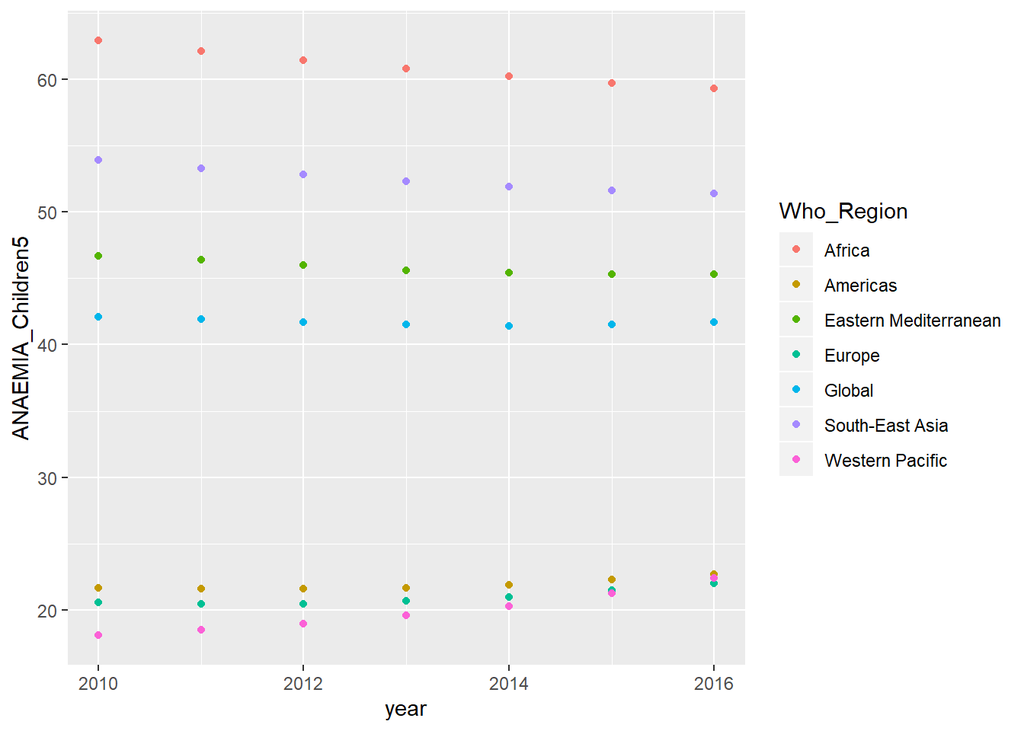

```r
ggplot(data=ANAEMIA_Children5,aes(x=year,y=ANAEMIA_Children5))+
  geom_point(aes(col=Who_Region))
```

#### Se genera un “Lineal model” para cada Who_Region para el indicador “ANAEMIA_Children5”

```r
Anaemia_Africa<-ANAEMIA_Children5 %>% filter(Who_Region== 'Africa')
Anaemia_Americas<-ANAEMIA_Children5 %>% filter(Who_Region== 'Americas')
Anaemia_South_East_Asia<-ANAEMIA_Children5 %>% filter(Who_Region== "South-East Asia")
Anaemia_Europe<-ANAEMIA_Children5 %>% filter(Who_Region== 'Europe')
Anaemia_Eastern_Mediterranean<-ANAEMIA_Children5 %>% filter(Who_Region== 'Eastern Mediterranean')
Anaemia_Western_Pacific<-ANAEMIA_Children5 %>% filter(Who_Region== 'Western Pacific')

model_Africa<-lm(ANAEMIA_Children5~year,data=Anaemia_Africa)
model_Americas<-lm(ANAEMIA_Children5~year,data=Anaemia_Americas)
model_South_East_Asia<-lm(ANAEMIA_Children5~year,data=Anaemia_South_East_Asia)
model_Europe<-lm(ANAEMIA_Children5~year,data=Anaemia_Europe)
model_Eastern_Mediterranean<-lm(ANAEMIA_Children5~year,data=Anaemia_Eastern_Mediterranean)
model_Western_Pacific<-lm(ANAEMIA_Children5~year,data=Anaemia_Western_Pacific)

summary(model_Africa)
```

```
##
## Call:
## lm(formula = ANAEMIA_Children5 ~ year, data = Anaemia_Africa)
##
## Residuals:
##        1        2        3        4        5        6        7
##  0.18571 -0.01429 -0.11429 -0.11429 -0.11429 -0.01429  0.18571
##
## Coefficients:
##               Estimate Std. Error t value Pr(>|t|)
## (Intercept) 1268.71429   56.05802   22.63 3.13e-06 ***
## year          -0.60000    0.02785  -21.55 4.00e-06 ***
## ---
## Signif. codes:  0 '***' 0.001 '**' 0.01 '*' 0.05 '.' 0.1 ' ' 1
##
## Residual standard error: 0.1474 on 5 degrees of freedom
## Multiple R-squared:  0.9893, Adjusted R-squared:  0.9872
## F-statistic: 464.2 on 1 and 5 DF,  p-value: 3.995e-06
```

```r
summary(model_Americas)
```

```
##
## Call:
## lm(formula = ANAEMIA_Children5 ~ year, data = Anaemia_Americas)
##
## Residuals:
##         1         2         3         4         5         6         7
##  0.267857  0.035714 -0.196429 -0.228571 -0.160714  0.007143  0.275000
##
## Coefficients:
##               Estimate Std. Error t value Pr(>|t|)
## (Intercept) -315.96786   87.63859  -3.605   0.0155 *
## year           0.16786    0.04354   3.856   0.0119 *
## ---
## Signif. codes:  0 '***' 0.001 '**' 0.01 '*' 0.05 '.' 0.1 ' ' 1
##
## Residual standard error: 0.2304 on 5 degrees of freedom
## Multiple R-squared:  0.7483, Adjusted R-squared:  0.698
## F-statistic: 14.87 on 1 and 5 DF,  p-value: 0.01193
```

```r
summary(model_South_East_Asia)
```

```
##
## Call:
## lm(formula = ANAEMIA_Children5 ~ year, data = Anaemia_South_East_Asia)
##
## Residuals:
##          1          2          3          4          5          6          7
##  2.071e-01 -1.429e-02 -1.357e-01 -1.571e-01 -7.857e-02 -6.184e-14  1.786e-01
##
## Coefficients:
##             Estimate Std. Error t value Pr(>|t|)
## (Intercept) 900.7929    59.9778   15.02 2.37e-05 ***
## year         -0.4214     0.0298  -14.14 3.18e-05 ***
## ---
## Signif. codes:  0 '***' 0.001 '**' 0.01 '*' 0.05 '.' 0.1 ' ' 1
##
## Residual standard error: 0.1577 on 5 degrees of freedom
## Multiple R-squared:  0.9756, Adjusted R-squared:  0.9707
## F-statistic: 200.1 on 1 and 5 DF,  p-value: 3.18e-05
```

```r
summary(model_Europe)
```

```
##
## Call:
## lm(formula = ANAEMIA_Children5 ~ year, data = Anaemia_Europe)
##
## Residuals:
##         1         2         3         4         5         6         7
##  0.310714  0.050000 -0.210714 -0.271429 -0.232143  0.007143  0.346429
##
## Coefficients:
##               Estimate Std. Error t value Pr(>|t|)
## (Intercept) -460.71071  106.39177  -4.330  0.00750 **
## year           0.23929    0.05285   4.527  0.00624 **
## ---
## Signif. codes:  0 '***' 0.001 '**' 0.01 '*' 0.05 '.' 0.1 ' ' 1
##
## Residual standard error: 0.2797 on 5 degrees of freedom
## Multiple R-squared:  0.8039, Adjusted R-squared:  0.7647
## F-statistic:  20.5 on 1 and 5 DF,  p-value: 0.00624
```

```r
summary(model_Eastern_Mediterranean)
```

```
##
## Call:
## lm(formula = ANAEMIA_Children5 ~ year, data = Anaemia_Eastern_Mediterranean)
##
## Residuals:
##        1        2        3        4        5        6        7
##  0.23571 -0.01429 -0.16429 -0.21429 -0.06429  0.08571  0.13571
##
## Coefficients:
##              Estimate Std. Error t value Pr(>|t|)
## (Intercept) 549.06429   67.74737   8.105 0.000464 ***
## year         -0.25000    0.03365  -7.428 0.000697 ***
## ---
## Signif. codes:  0 '***' 0.001 '**' 0.01 '*' 0.05 '.' 0.1 ' ' 1
##
## Residual standard error: 0.1781 on 5 degrees of freedom
## Multiple R-squared:  0.9169, Adjusted R-squared:  0.9003
## F-statistic: 55.18 on 1 and 5 DF,  p-value: 0.0006966
```

```r
summary(model_Western_Pacific)
```

```
##
## Call:
## lm(formula = ANAEMIA_Children5 ~ year, data = Anaemia_Western_Pacific)
##
## Residuals:
##          1          2          3          4          5          6          7
##  3.929e-01 -2.956e-13 -2.929e-01 -2.857e-01 -1.786e-01  2.857e-02  3.357e-01
##
## Coefficients:
##               Estimate Std. Error t value Pr(>|t|)
## (Intercept) -1.404e+03  1.163e+02  -12.07 6.89e-05 ***
## year         7.071e-01  5.776e-02   12.24 6.43e-05 ***
## ---
## Signif. codes:  0 '***' 0.001 '**' 0.01 '*' 0.05 '.' 0.1 ' ' 1
##
## Residual standard error: 0.3057 on 5 degrees of freedom
## Multiple R-squared:  0.9677, Adjusted R-squared:  0.9613
## F-statistic: 149.9 on 1 and 5 DF,  p-value: 6.434e-05
```

```r
newdata<-data.frame(year=c(2017))
pred_Africa<-model_Africa %>% predict(newdata)
pred_Americas<-model_Americas %>% predict(newdata)
pred_South<-model_South_East_Asia %>% predict(newdata)
pred_Europe<-model_Europe %>% predict(newdata)
pred_Eastern<-model_Eastern_Mediterranean %>% predict(newdata)
pred_Western<-model_Western_Pacific %>% predict(newdata)

pred_2017_Anaemia<-data.frame(Who_Region=c("Africa","Americas","South-East Asia","Europe","Eastern Mediterranean","Western Pacific"),
                year=rep(2017,6),
                ANAEMIA_Children5=c(pred_Africa,pred_Americas ,pred_South ,pred_Europe ,pred_Eastern ,pred_Western))

pred_2017_Anaemia$ANAEMIA_Children5<-round(pred_2017_Anaemia$ANAEMIA_Children5,1)
pred_2017_Anaemia$Who_Region<-as.character(pred_2017_Anaemia$Who_Region)
glimpse(pred_2017_Anaemia)
```

```
## Observations: 6
## Variables: 3
## $ Who_Region        <chr> "Africa", "Americas", "South-East Asia", "Europe"...
## $ year              <dbl> 2017, 2017, 2017, 2017, 2017, 2017
## $ ANAEMIA_Children5 <dbl> 58.5, 22.6, 50.8, 21.9, 44.8, 22.7
```

```r
ANAEMIA_Children5<-rbind(ANAEMIA_Children5,pred_2017_Anaemia)
unique(ANAEMIA_Children5$year)
```

```
## [1] 2016 2015 2014 2013 2012 2011 2010 2017
```

#### Para el indicador **“Weight_Low_birth”** falta el año **2016&2017**

1. Se genera un ggplot para ver evolutivo
2. Se estima por regresión lineal para cada Who_Region.

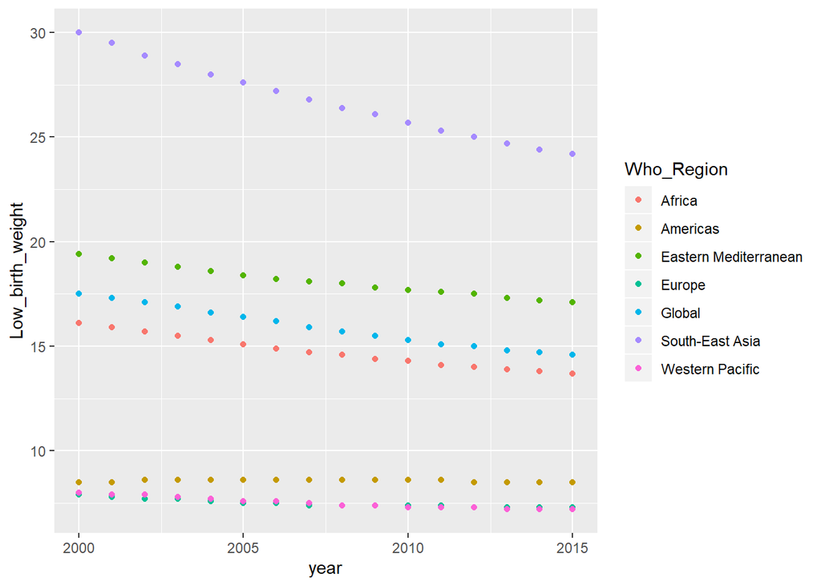

```r
ggplot(data=A_Weight_Low_birth,aes(x=year,y=Low_birth_weight))+
  geom_point(aes(col=Who_Region))
```

#### Se genera un “Lineal model” para cada Who_Region, con la predicción.

```r
Low_birth_weight_Africa<-A_Weight_Low_birth %>% filter(Who_Region== 'Africa')
Low_birth_weight_Americas<-A_Weight_Low_birth %>% filter(Who_Region== 'Americas')
Low_birth_weight_South_East_Asia<-A_Weight_Low_birth %>% filter(Who_Region== "South-East Asia")
Low_birth_weight_Europe<-A_Weight_Low_birth %>% filter(Who_Region== 'Europe')
Low_birth_weight_Eastern_Mediterranean<-A_Weight_Low_birth %>% filter(Who_Region== 'Eastern Mediterranean')
Low_birth_weight_Western_Pacific<-A_Weight_Low_birth %>% filter(Who_Region== 'Western Pacific')

model_Africa<-lm(Low_birth_weight~year,data=Low_birth_weight_Africa)
model_Americas<-lm(Low_birth_weight~year,data=Low_birth_weight_Americas)
model_South_East_Asia<-lm(Low_birth_weight~year,data=Low_birth_weight_South_East_Asia)
model_Europe<-lm(Low_birth_weight~year,data=Low_birth_weight_Europe)
model_Eastern_Mediterranean<-lm(Low_birth_weight~year,data=Low_birth_weight_Eastern_Mediterranean)
model_Western_Pacific<-lm(Low_birth_weight~year,data=Low_birth_weight_Western_Pacific)

summary(model_Africa)
```

```
##
## Call:
## lm(formula = Low_birth_weight ~ year, data = Low_birth_weight_Africa)
##
## Residuals:
##      Min       1Q   Median       3Q      Max
## -0.13132 -0.07169 -0.01868  0.06478  0.16985
##
## Coefficients:
##               Estimate Std. Error t value Pr(>|t|)
## (Intercept) 341.263971  10.312846   33.09 1.08e-14 ***
## year         -0.162647   0.005137  -31.66 1.98e-14 ***
## ---
## Signif. codes:  0 '***' 0.001 '**' 0.01 '*' 0.05 '.' 0.1 ' ' 1
##
## Residual standard error: 0.09472 on 14 degrees of freedom
## Multiple R-squared:  0.9862, Adjusted R-squared:  0.9852
## F-statistic:  1002 on 1 and 14 DF,  p-value: 1.982e-14
```

```r
summary(model_Americas)
```

```
##
## Call:
## lm(formula = Low_birth_weight ~ year, data = Low_birth_weight_Americas)
##
## Residuals:
##      Min       1Q   Median       3Q      Max
## -0.08456 -0.04412  0.02574  0.03676  0.04779
##
## Coefficients:
##              Estimate Std. Error t value Pr(>|t|)
## (Intercept) 14.466912   5.409196   2.675   0.0181 *
## year        -0.002941   0.002694  -1.092   0.2935
## ---
## Signif. codes:  0 '***' 0.001 '**' 0.01 '*' 0.05 '.' 0.1 ' ' 1
##
## Residual standard error: 0.04968 on 14 degrees of freedom
## Multiple R-squared:  0.07843,    Adjusted R-squared:  0.01261
## F-statistic: 1.191 on 1 and 14 DF,  p-value: 0.2935
```

```r
summary(model_South_East_Asia)
```

```
##
## Call:
## lm(formula = Low_birth_weight ~ year, data = Low_birth_weight_South_East_Asia)
##
## Residuals:
##      Min       1Q   Median       3Q      Max
## -0.17529 -0.12621 -0.05801  0.08099  0.33309
##
## Coefficients:
##               Estimate Std. Error t value Pr(>|t|)
## (Intercept) 803.494118  19.215973   41.81 4.20e-16 ***
## year         -0.386912   0.009572  -40.42 6.72e-16 ***
## ---
## Signif. codes:  0 '***' 0.001 '**' 0.01 '*' 0.05 '.' 0.1 ' ' 1
##
## Residual standard error: 0.1765 on 14 degrees of freedom
## Multiple R-squared:  0.9915, Adjusted R-squared:  0.9909
## F-statistic:  1634 on 1 and 14 DF,  p-value: 6.718e-16
```

```r
summary(model_Europe)
```

```
##
## Call:
## lm(formula = Low_birth_weight ~ year, data = Low_birth_weight_Europe)
##
## Residuals:
##       Min        1Q    Median        3Q       Max
## -0.112647 -0.040404 -0.000441  0.041875  0.122794
##
## Coefficients:
##              Estimate Std. Error t value Pr(>|t|)
## (Intercept) 83.365441   7.345022   11.35 1.91e-08 ***
## year        -0.037794   0.003659  -10.33 6.24e-08 ***
## ---
## Signif. codes:  0 '***' 0.001 '**' 0.01 '*' 0.05 '.' 0.1 ' ' 1
##
## Residual standard error: 0.06746 on 14 degrees of freedom
## Multiple R-squared:  0.884,  Adjusted R-squared:  0.8757
## F-statistic: 106.7 on 1 and 14 DF,  p-value: 6.241e-08
```

```r
summary(model_Eastern_Mediterranean)
```

```
##
## Call:
## lm(formula = Low_birth_weight ~ year, data = Low_birth_weight_Eastern_Mediterranean)
##
## Residuals:
##       Min        1Q    Median        3Q       Max
## -0.145294 -0.058566  0.005735  0.061397  0.148529
##
## Coefficients:
##               Estimate Std. Error t value Pr(>|t|)
## (Intercept) 321.310294   9.607176   33.45 9.29e-15 ***
## year         -0.151029   0.004786  -31.56 2.07e-14 ***
## ---
## Signif. codes:  0 '***' 0.001 '**' 0.01 '*' 0.05 '.' 0.1 ' ' 1
##
## Residual standard error: 0.08824 on 14 degrees of freedom
## Multiple R-squared:  0.9861, Adjusted R-squared:  0.9851
## F-statistic:   996 on 1 and 14 DF,  p-value: 2.073e-14
```

```r
summary(model_Western_Pacific)
```

```
##
## Call:
## lm(formula = Low_birth_weight ~ year, data = Low_birth_weight_Western_Pacific)
##
## Residuals:
##       Min        1Q    Median        3Q       Max
## -0.090588 -0.037426 -0.006103  0.037868  0.103676
##
## Coefficients:
##               Estimate Std. Error t value Pr(>|t|)
## (Intercept) 120.588235   6.225702   19.37 1.66e-11 ***
## year         -0.056324   0.003101  -18.16 3.96e-11 ***
## ---
## Signif. codes:  0 '***' 0.001 '**' 0.01 '*' 0.05 '.' 0.1 ' ' 1
##
## Residual standard error: 0.05718 on 14 degrees of freedom
## Multiple R-squared:  0.9593, Adjusted R-squared:  0.9564
## F-statistic: 329.8 on 1 and 14 DF,  p-value: 3.957e-11
```

```r
newdata<-data.frame(year=c(2016,2017))
pred_Africa<-model_Africa %>% predict(newdata)
pred_Americas<-model_Americas %>% predict(newdata)
pred_South<-model_South_East_Asia %>% predict(newdata)
pred_Europe<-model_Europe %>% predict(newdata)
pred_Eastern<-model_Eastern_Mediterranean %>% predict(newdata)
pred_Western<-model_Western_Pacific %>% predict(newdata)

pred_2016_17_Low_birth_weight<-data.frame(Who_Region=c(rep("Africa",2),rep("Americas",2),rep("South-East Asia",2),rep("Europe",2),rep("Eastern Mediterranean",2),rep("Western Pacific",2)),
                              year=c(rep(2016:2017,6)),
                              Low_birth_weight=c(pred_Africa,pred_Americas ,pred_South ,pred_Europe ,pred_Eastern ,pred_Western))

pred_2016_17_Low_birth_weight$Low_birth_weight<-round(pred_2016_17_Low_birth_weight$Low_birth_weight,1)
pred_2016_17_Low_birth_weight$Who_Region<-as.character(pred_2016_17_Low_birth_weight$Who_Region)
glimpse(pred_2016_17_Low_birth_weight)
```

```
## Observations: 12
## Variables: 3
## $ Who_Region       <chr> "Africa", "Africa", "Americas", "Americas", "South...
## $ year             <int> 2016, 2017, 2016, 2017, 2016, 2017, 2016, 2017, 20...
## $ Low_birth_weight <dbl> 13.4, 13.2, 8.5, 8.5, 23.5, 23.1, 7.2, 7.1, 16.8, ...
```

```r
A_Weight_Low_birth<-rbind(A_Weight_Low_birth,pred_2016_17_Low_birth_weight)
```

#### Se actualizan al dataset las estimaciones de estos indicadores.

```r
m7<-Reduce(function(...) merge (..., all.x=TRUE), list(m6,ANAEMIA_Children5,A_Weight_Low_birth))
glimpse(m7)
```

```
## Observations: 48
## Variables: 39
## $ Who_Region            <chr> "Africa", "Africa", "Africa", "Africa", "Afri...
## $ year                  <int> 2010, 2011, 2012, 2013, 2014, 2015, 2016, 201...
## $ Rate_Mort_Child       <dbl> 99.4, 95.4, 91.8, 88.5, 85.6, 83.0, 80.5, 78....
## $ Legislation           <int> 29, 32, 32, 41, 60, 69, 67, 54, 47, 66, 64, 7...
## $ Coordination          <int> 56, 49, 52, 57, 67, 70, 71, 60, 77, 73, 70, 7...
## $ Surveillance          <int> 61, 65, 71, 69, 77, 81, 83, 76, 59, 77, 82, 8...
## $ Response              <int> 47, 56, 62, 66, 72, 79, 73, 68, 62, 75, 78, 8...
## $ Preparedness          <int> 25, 36, 45, 40, 53, 58, 55, 55, 40, 57, 55, 6...
## $ Risk_communication    <int> 48, 44, 51, 51, 61, 64, 68, 60, 61, 70, 65, 7...
## $ Human_resources       <int> 25, 33, 45, 45, 56, 64, 51, 57, 44, 54, 57, 6...
## $ Laboratory            <int> 51, 65, 68, 69, 73, 77, 75, 73, 61, 73, 79, 7...
## $ Points_entry          <int> 47, 38, 29, 23, 35, 38, 39, 33, 55, 44, 63, 6...
## $ Zoonosis              <int> 63, 59, 70, 67, 68, 73, 79, 75, 59, 78, 83, 9...
```

[output cut: 26 more lines]

```r
unique(m7$Who_Region)
```

```
## [1] "Africa"                "Americas"              "Eastern Mediterranean"
## [4] "Europe"                "South-East Asia"       "Western Pacific"
```

```r
unique(m7$year)
```

```
## [1] 2010 2011 2012 2013 2014 2015 2016 2017
```

#### Analizando valores nulos y NAs del dataset “m7” montado hasta ahora.

1. Con la función *stat.desc* y las métricas **nbr.null** y **nbr.na**
2. Se identifican NAs en los siguientes indicadores: **Inm_PCV3_coverage** & **Inm_ROTAC_coverage**.
3. Y valores nulos en Mort_HIVAIDS_dis_rate, Mort_Malaria_rate,Mort_Measles_rate y Mort_Tetanos_rate

```r
m7_num<-select_if(m7,is.numeric)
stat_m7<-stat.desc(m7_num)
stat_m7<-round(stat_m7,1)

stat_m7[,(stat_m7["nbr.null",]>0)]
```

```
##              Mort_HIVAIDS_dis_rate Mort_Malaria_rate Mort_Measles_rate
## nbr.val                       48.0              48.0              48.0
## nbr.null                      15.0              17.0              18.0
## nbr.na                         0.0               0.0               0.0
## min                            0.0               0.0               0.0
## max                            4.1              12.9               2.8
## range                          4.1              12.9               2.8
## sum                           23.9              78.4              37.5
## median                         0.1               0.1               0.4
## mean                           0.5               1.6               0.8
## SE.mean                        0.1               0.5               0.1
## CI.mean.0.95                   0.3               1.1               0.3
## var                            1.1              13.2               0.8
## std.dev                        1.0               3.6               0.9
## coef.var                       2.1               2.2               1.1
##              Mort_Tetanos_rate
## nbr.val                   48.0
## nbr.null                  24.0
## nbr.na                     0.0
## min                        0.0
## max                        1.0
## range                      1.0
## sum                       12.6
## median                     0.1
## mean                       0.3
## SE.mean                    0.0
## CI.mean.0.95               0.1
## var                        0.1
## std.dev                    0.3
## coef.var                   1.2
```

```r
stat_m7[,(stat_m7["nbr.na",]>0)]
```

```
##              Inm_PCV3_coverage Inm_ROTAC_coverage
## nbr.val                   43.0               41.0
## nbr.null                   0.0                0.0
## nbr.na                     5.0                7.0
## min                        1.0                1.0
## max                       85.0               76.0
## range                     84.0               75.0
## sum                     1676.0              991.0
## median                    44.0               12.0
## mean                      39.0               24.2
## SE.mean                    4.3                4.1
## CI.mean.0.95               8.6                8.3
## var                      781.5              684.6
## std.dev                   28.0               26.2
## coef.var                   0.7                1.1
```

#### Analizando los NAs en **Inm_PCV3_coverage** & **Inm_ROTAC_coverage**

1. Se identifican las regiones dónde están los NAs y se analiza cuál es la mejor estimación.
2. Después de visualizar gráfico con evolutivo, se va a estimar 2010 a 2014 por regresión lineal para South_East_Asia, pero el valor va a ser negativo. Para 2014 sale 0, se ponen todos los NAs a 0.
3. Analizando “Eastern Mediterranean” y “South-East Asia” para el indicador “Inm_ROTAC”, ocurre lo mismo que en el anterior, por tanto, se ponen los NAs a 0 también.

```r
m7$Who_Region[which(is.na(m7$Inm_PCV3_coverage))]
```

```
## [1] "South-East Asia" "South-East Asia" "South-East Asia" "South-East Asia"
## [5] "South-East Asia"
```

```r
m7$Who_Region[which(is.na(m7$Inm_ROTAC_coverage))]
```

```
## [1] "Eastern Mediterranean" "South-East Asia"       "South-East Asia"
## [4] "South-East Asia"       "South-East Asia"       "South-East Asia"
## [7] "South-East Asia"
```

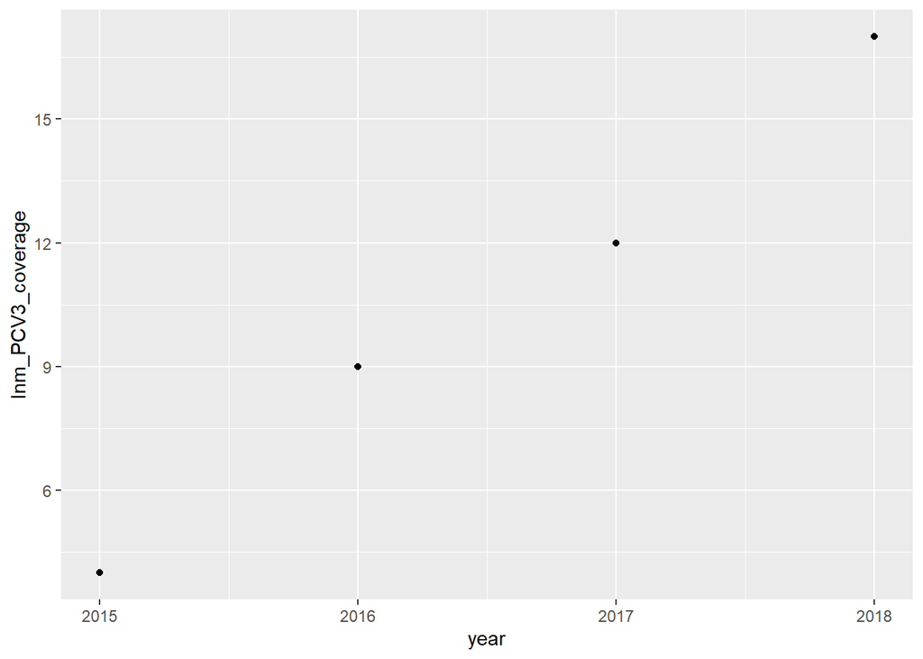

```r
Inm_PCV3_South_East_Asia<-Inm_PCV3 %>% filter(Inm_PCV3$Who_Region=="South-East Asia" & year>='2015')

ggplot(data=Inm_PCV3_South_East_Asia,aes(x=year,y=Inm_PCV3_coverage))+
  geom_point()
```

```r
model_3<-lm(Inm_PCV3_coverage~year, data =Inm_PCV3_South_East_Asia )
summary(model_3)
```

```
##
## Call:
## lm(formula = Inm_PCV3_coverage ~ year, data = Inm_PCV3_South_East_Asia)
##
## Residuals:
##    1    2    3    4
##  0.2 -0.6  0.6 -0.2
##
## Coefficients:
##               Estimate Std. Error t value Pr(>|t|)
## (Intercept) -8458.8000   570.3524  -14.83  0.00452 **
## year            4.2000     0.2828   14.85  0.00450 **
## ---
## Signif. codes:  0 '***' 0.001 '**' 0.01 '*' 0.05 '.' 0.1 ' ' 1
##
## Residual standard error: 0.6325 on 2 degrees of freedom
## Multiple R-squared:  0.991,  Adjusted R-squared:  0.9865
## F-statistic: 220.5 on 1 and 2 DF,  p-value: 0.004505
```

```r
new_data<-data.frame(year=c(2010,2011,2012,2013,2014))
model_3 %>% predict(new_data)
```

```
##     1     2     3     4     5
## -16.8 -12.6  -8.4  -4.2   0.0
```

```r
model_3
```

```
##
## Call:
## lm(formula = Inm_PCV3_coverage ~ year, data = Inm_PCV3_South_East_Asia)
##
## Coefficients:
## (Intercept)         year
##     -8458.8          4.2
```

#### Cambiando los valores NAs por 0.

1. Se comprueba que los NAs han pasado a “nulls”
2. Y que ya no hay NAs

```r
m7[is.na(m7)]<-0

m7_num<-select_if(m7,is.numeric)
stat_m7<-stat.desc(m7_num)
stat_m7<-round(stat_m7,1)


stat_m7[,(stat_m7["nbr.null",]>0)]
```

```
##              Mort_HIVAIDS_dis_rate Mort_Malaria_rate Mort_Measles_rate
## nbr.val                       48.0              48.0              48.0
## nbr.null                      15.0              17.0              18.0
## nbr.na                         0.0               0.0               0.0
## min                            0.0               0.0               0.0
## max                            4.1              12.9               2.8
## range                          4.1              12.9               2.8
## sum                           23.9              78.4              37.5
## median                         0.1               0.1               0.4
## mean                           0.5               1.6               0.8
## SE.mean                        0.1               0.5               0.1
## CI.mean.0.95                   0.3               1.1               0.3
## var                            1.1              13.2               0.8
## std.dev                        1.0               3.6               0.9
## coef.var                       2.1               2.2               1.1
##              Mort_Tetanos_rate Inm_PCV3_coverage Inm_ROTAC_coverage
## nbr.val                   48.0              48.0               48.0
## nbr.null                  24.0               5.0                7.0
## nbr.na                     0.0               0.0                0.0
## min                        0.0               0.0                0.0
## max                        1.0              85.0               76.0
## range                      1.0              85.0               76.0
## sum                       12.6            1676.0              991.0
## median                     0.1              36.5                7.5
## mean                       0.3              34.9               20.6
## SE.mean                    0.0               4.2                3.7
## CI.mean.0.95               0.1               8.4                7.4
## var                        0.1             843.2              657.0
## std.dev                    0.3              29.0               25.6
## coef.var                   1.2               0.8                1.2
```

```r
stat_m7[,(stat_m7["nbr.na",]>0)]
```

```
## data frame with 0 columns and 14 rows
```

#### Se importan dos indicadores de **“Woman an health”**

1. ANAEMIA_RW<-Prevalence of anaemia in women of reproductive age (%)
2. ANAEMIA_PW<- Prevalence of anaemia in pregnant women (%),
3. Las variables contienen el valor y el intervalo de confianza, es de tipo carácter, se extrae el valor y se convierte a numérico.
4. Se tienen que pivotar las tablas de wide a longer

```r
ANAEMIA_RW<-read.csv("ANAEMIA_RW.csv", header=TRUE,sep = ",",stringsAsFactors = FALSE, skip=1)
ANAEMIA_RW<-ANAEMIA_RW[,c(1:8)]
colnames(ANAEMIA_RW)<-c("Who_Region","2016","2015","2014","2013","2012","2011","2010")

ANAEMIA_RW<- ANAEMIA_RW %>%
  pivot_longer(cols=`2016`:`2010`,
               names_to="year",
               values_to = "ANAEMIA_RW",
               names_ptypes = list(year=integer()))

ANAEMIA_RW$ANAEMIA_RW<-substr(ANAEMIA_RW$ANAEMIA_RW,1,4)
ANAEMIA_RW$ANAEMIA_RW<-as.numeric(ANAEMIA_RW$ANAEMIA_RW)
glimpse(ANAEMIA_RW)
```

```
## Observations: 49
## Variables: 3
## $ Who_Region <chr> "Global", "Global", "Global", "Global", "Global", "Globa...
## $ year       <int> 2016, 2015, 2014, 2013, 2012, 2011, 2010, 2016, 2015, 20...
## $ ANAEMIA_RW <dbl> 32.8, 32.0, 31.3, 30.7, 30.3, 30.0, 29.9, 39.0, 38.8, 38...
```

```r
unique(ANAEMIA_RW$Who_Region)
```

```
## [1] "Global"                "Africa"                "Americas"
## [4] "South-East Asia"       "Europe"                "Eastern Mediterranean"
## [7] "Western Pacific"
```

```r
unique(ANAEMIA_RW$year)
```

```
## [1] 2016 2015 2014 2013 2012 2011 2010
```

```r
#### ANAEMIA_PW
ANAEMIA_PW<-read.csv("ANAEMIA_PW.csv", header=TRUE,sep = ",",stringsAsFactors = FALSE, skip=1)
ANAEMIA_PW<-ANAEMIA_PW[,c(1:8)]
colnames(ANAEMIA_PW)<-c("Who_Region","2016","2015","2014","2013","2012","2011","2010")

ANAEMIA_PW<- ANAEMIA_PW %>%
  pivot_longer(cols=`2016`:`2010`,
               names_to="year",
               values_to = "ANAEMIA_PW",
               names_ptypes = list(year=integer()))

ANAEMIA_PW$ANAEMIA_PW<-substr(ANAEMIA_PW$ANAEMIA_PW,1,4)
ANAEMIA_PW$ANAEMIA_PW<-as.numeric(ANAEMIA_PW$ANAEMIA_PW)
glimpse(ANAEMIA_PW)
```

```
## Observations: 49
## Variables: 3
## $ Who_Region <chr> "Global", "Global", "Global", "Global", "Global", "Globa...
## $ year       <int> 2016, 2015, 2014, 2013, 2012, 2011, 2010, 2016, 2015, 20...
## $ ANAEMIA_PW <dbl> 40.1, 39.8, 39.6, 39.5, 39.4, 39.3, 39.4, 46.2, 46.3, 46...
```

```r
unique(ANAEMIA_PW$Who_Region)
```

```
## [1] "Global"                "Africa"                "Americas"
## [4] "South-East Asia"       "Europe"                "Eastern Mediterranean"
## [7] "Western Pacific"
```

```r
unique(ANAEMIA_PW$year)
```

```
## [1] 2016 2015 2014 2013 2012 2011 2010
```

#### Se importa indicador **“Maternal_mortality”**

1. La variable contiene el valor y el intervalo de confianza, es de tipo carácter, se extrae el valor y se convierte a numérico.

```r
Maternal_Mort_Rate<-read.csv("Maternal_mortality.csv",header=TRUE,stringsAsFactors = FALSE)
Maternal_Mort_Rate<-Maternal_Mort_Rate[,c(1:3)]
colnames(Maternal_Mort_Rate)<-c("Who_Region", "year", "Maternal_Mort_Rate" )

Maternal_Mort_Rate$Maternal_Mort_Rate<-substr(Maternal_Mort_Rate$Maternal_Mort_Rate,1,3)
Maternal_Mort_Rate$Maternal_Mort_Rate<-as.numeric(Maternal_Mort_Rate$Maternal_Mort_Rate)
glimpse(Maternal_Mort_Rate)
```

```
## Observations: 126
## Variables: 3
## $ Who_Region         <chr> "Global", "Global", "Global", "Global", "Global"...
## $ year               <int> 2017, 2016, 2015, 2014, 2013, 2012, 2011, 2010, ...
## $ Maternal_Mort_Rate <dbl> 211, 214, 219, 224, 229, 234, 241, 248, 257, 265...
```

```r
unique(Maternal_Mort_Rate$Who_Region)
```

```
## [1] "Global"                "Africa"                "Americas"
## [4] "South-East Asia"       "Europe"                "Eastern Mediterranean"
## [7] "Western Pacific"
```

```r
unique(Maternal_Mort_Rate$year)
```

```
##  [1] 2017 2016 2015 2014 2013 2012 2011 2010 2009 2008 2007 2006 2005 2004 2003
## [16] 2002 2001 2000
```

#### Se importa “Life expectancy at birth” para ambos sexos.

```r
Life_expectancy_All<-read.csv("Life_expectancy_All.csv",header=TRUE,stringsAsFactors = FALSE,skip=1)
Life_expectancy_birth<-Life_expectancy_All[,c(1:3)]
colnames(Life_expectancy_birth)<-c("Who_Region", "year", "Life_expectancy_at_birth" )

glimpse(Life_expectancy_birth)
```

```
## Observations: 35
## Variables: 3
## $ Who_Region               <chr> "Global", "Global", "Global", "Global", "G...
## $ year                     <int> 2016, 2015, 2010, 2005, 2000, 2016, 2015, ...
## $ Life_expectancy_at_birth <dbl> 72.0, 71.7, 70.1, 68.2, 66.5, 61.2, 60.7, ...
```

```r
unique(Life_expectancy_birth$year)
```

```
## [1] 2016 2015 2010 2005 2000
```

```r
unique(Life_expectancy_birth$Who_Region)
```

```
## [1] "Global"                "Africa"                "Americas"
## [4] "South-East Asia"       "Europe"                "Eastern Mediterranean"
## [7] "Western Pacific"
```

#### Se añaden al dataset los siguientes indicadores:

- ANAEMIA_RW
- ANAEMIA_PW
- Maternal_Mort_Rate
- Life_expectancy_birth

```r
dataset<-Reduce(function(...) merge (..., all.x=TRUE), list(m7,ANAEMIA_RW,ANAEMIA_PW,Maternal_Mort_Rate,Life_expectancy_birth))
glimpse(dataset)
```

```
## Observations: 48
## Variables: 43
## $ Who_Region               <chr> "Africa", "Africa", "Africa", "Africa", "A...
## $ year                     <int> 2010, 2011, 2012, 2013, 2014, 2015, 2016, ...
## $ Rate_Mort_Child          <dbl> 99.4, 95.4, 91.8, 88.5, 85.6, 83.0, 80.5, ...
## $ Legislation              <int> 29, 32, 32, 41, 60, 69, 67, 54, 47, 66, 64...
## $ Coordination             <int> 56, 49, 52, 57, 67, 70, 71, 60, 77, 73, 70...
## $ Surveillance             <int> 61, 65, 71, 69, 77, 81, 83, 76, 59, 77, 82...
## $ Response                 <int> 47, 56, 62, 66, 72, 79, 73, 68, 62, 75, 78...
## $ Preparedness             <int> 25, 36, 45, 40, 53, 58, 55, 55, 40, 57, 55...
## $ Risk_communication       <int> 48, 44, 51, 51, 61, 64, 68, 60, 61, 70, 65...
## $ Human_resources          <int> 25, 33, 45, 45, 56, 64, 51, 57, 44, 54, 57...
## $ Laboratory               <int> 51, 65, 68, 69, 73, 77, 75, 73, 61, 73, 79...
## $ Points_entry             <int> 47, 38, 29, 23, 35, 38, 39, 33, 55, 44, 63...
## $ Zoonosis                 <int> 63, 59, 70, 67, 68, 73, 79, 75, 59, 78, 83...
```

[output cut: 30 more lines]

```r
unique(dataset$Who_Region)
```

```
## [1] "Africa"                "Americas"              "Eastern Mediterranean"
## [4] "Europe"                "South-East Asia"       "Western Pacific"
```

```r
unique(dataset$year)
```

```
## [1] 2010 2011 2012 2013 2014 2015 2016 2017
```

#### Analizando valores NULOS y NAS del nuevo dataset(ya definitivo, porque no se van a incluir más variables)

1. Se identifican de la variable “Life_Expectancy_at_birth” 30 valores NAs
2. Y de las variables “ANAEMIA_RW” and “ANAEMIA_PW” 6 valores NAs para cada variable

```r
dataset_num<-select_if(dataset,is.numeric)
stat_dataset<-stat.desc(dataset_num)
stat_dataset<-round(stat_dataset,1)

stat_dataset[,(stat_dataset["nbr.null",]>0)]
```

```
##              Mort_HIVAIDS_dis_rate Mort_Malaria_rate Mort_Measles_rate
## nbr.val                       48.0              48.0              48.0
## nbr.null                      15.0              17.0              18.0
## nbr.na                         0.0               0.0               0.0
## min                            0.0               0.0               0.0
## max                            4.1              12.9               2.8
## range                          4.1              12.9               2.8
## sum                           23.9              78.4              37.5
## median                         0.1               0.1               0.4
## mean                           0.5               1.6               0.8
## SE.mean                        0.1               0.5               0.1
## CI.mean.0.95                   0.3               1.1               0.3
## var                            1.1              13.2               0.8
## std.dev                        1.0               3.6               0.9
## coef.var                       2.1               2.2               1.1
##              Mort_Tetanos_rate Inm_PCV3_coverage Inm_ROTAC_coverage
## nbr.val                   48.0              48.0               48.0
## nbr.null                  24.0               5.0                7.0
## nbr.na                     0.0               0.0                0.0
## min                        0.0               0.0                0.0
## max                        1.0              85.0               76.0
## range                      1.0              85.0               76.0
## sum                       12.6            1676.0              991.0
## median                     0.1              36.5                7.5
## mean                       0.3              34.9               20.6
## SE.mean                    0.0               4.2                3.7
## CI.mean.0.95               0.1               8.4                7.4
## var                        0.1             843.2              657.0
## std.dev                    0.3              29.0               25.6
## coef.var                   1.2               0.8                1.2
```

```r
stat_dataset[,(stat_dataset["nbr.na",]>0)]
```

```
##              ANAEMIA_RW ANAEMIA_PW Life_expectancy_at_birth
## nbr.val            42.0       42.0                     18.0
## nbr.null            0.0        0.0                      0.0
## nbr.na              6.0        6.0                     30.0
## min                17.7       25.2                     57.6
## max                45.8       48.1                     77.5
## range              28.1       22.9                     19.9
## sum              1284.6     1517.5                   1280.1
## median             31.5       36.5                     72.4
## mean               30.6       36.1                     71.1
## SE.mean             1.7        1.5                      1.5
## CI.mean.0.95        3.3        3.0                      3.2
## var               115.5       91.3                     40.8
## std.dev            10.7        9.6                      6.4
## coef.var            0.4        0.3                      0.1
```

#### Gráfico del indicador **“Life_Expectancy_at_birth”** para ver su evolución

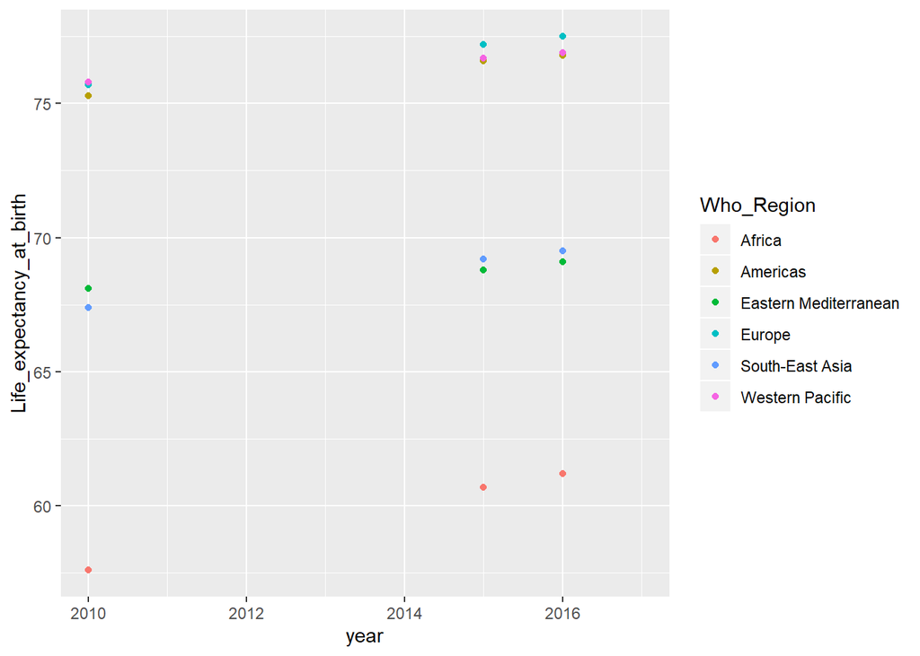

```r
dataset_Life<-dataset %>% select("Who_Region", year, Life_expectancy_at_birth)
ggplot(data=dataset_Life, aes(x=year, y=Life_expectancy_at_birth))+
  geom_point(aes(col=Who_Region))
```

#### Se decide hacer las estimaciones por **Regresión Lineal**

1. Todas los modelos tienen un R2 superior a 0.98
2. Se obtiene las predicciones con *predict*

```r
Life_Africa<-dataset_Life%>% filter(Who_Region=="Africa")
Life_Americas<-dataset_Life%>% filter(Who_Region=="Americas")
Life_Eastern_Mediterranean<-dataset_Life%>% filter(Who_Region=="Eastern Mediterranean")
Life_Europe<-dataset_Life%>% filter(Who_Region=="Europe")
Life_South_East_Asia<-dataset_Life%>% filter(Who_Region=="South-East Asia")
Life_Western_Pacific<-dataset_Life%>% filter(Who_Region=="Western Pacific")

model_Africa<-lm(Life_expectancy_at_birth~year,data=Life_Africa)
model_Americas<-lm(Life_expectancy_at_birth~year,data=Life_Americas)
model_Eastern_Mediterranean<-lm(Life_expectancy_at_birth~year,data=Life_Eastern_Mediterranean)
model_Europe<-lm(Life_expectancy_at_birth~year,data=Life_Europe)
model_South_East_Asia<-lm(Life_expectancy_at_birth~year,data=Life_South_East_Asia)
model_Western_Pacific<-lm(Life_expectancy_at_birth~year,data=Life_Western_Pacific)

summary(model_Africa)
```

```
##
## Call:
## lm(formula = Life_expectancy_at_birth ~ year, data = Life_Africa)
##
## Residuals:
##         1         6         7
## -0.009677  0.058065 -0.048387
##
## Coefficients:
##               Estimate Std. Error t value Pr(>|t|)
## (Intercept) -1.161e+03  3.375e+01  -34.41   0.0185 *
## year         6.065e-01  1.676e-02   36.18   0.0176 *
## ---
## Signif. codes:  0 '***' 0.001 '**' 0.01 '*' 0.05 '.' 0.1 ' ' 1
##
## Residual standard error: 0.0762 on 1 degrees of freedom
##   (5 observations deleted due to missingness)
## Multiple R-squared:  0.9992, Adjusted R-squared:  0.9985
## F-statistic:  1309 on 1 and 1 DF,  p-value: 0.01759
```

```r
summary(model_Americas)
```

```
##
## Call:
## lm(formula = Life_expectancy_at_birth ~ year, data = Life_Americas)
##
## Residuals:
##         1         6         7
## -0.004839  0.029032 -0.024194
##
## Coefficients:
##               Estimate Std. Error t value Pr(>|t|)
## (Intercept) -4.337e+02  1.688e+01  -25.70   0.0248 *
## year         2.532e-01  8.381e-03   30.21   0.0211 *
## ---
## Signif. codes:  0 '***' 0.001 '**' 0.01 '*' 0.05 '.' 0.1 ' ' 1
##
## Residual standard error: 0.0381 on 1 degrees of freedom
##   (5 observations deleted due to missingness)
## Multiple R-squared:  0.9989, Adjusted R-squared:  0.9978
## F-statistic: 912.9 on 1 and 1 DF,  p-value: 0.02106
```

```r
summary(model_Eastern_Mediterranean)
```

```
##
## Call:
## lm(formula = Life_expectancy_at_birth ~ year, data = Life_Eastern_Mediterranean)
##
## Residuals:
##        1        6        7
##  0.01290 -0.07742  0.06452
##
## Coefficients:
##               Estimate Std. Error t value Pr(>|t|)
## (Intercept) -249.62258   45.00356  -5.547   0.1136
## year           0.15806    0.02235   7.073   0.0894 .
## ---
## Signif. codes:  0 '***' 0.001 '**' 0.01 '*' 0.05 '.' 0.1 ' ' 1
##
## Residual standard error: 0.1016 on 1 degrees of freedom
##   (5 observations deleted due to missingness)
## Multiple R-squared:  0.9804, Adjusted R-squared:  0.9608
## F-statistic: 50.02 on 1 and 1 DF,  p-value: 0.08942
```

```r
summary(model_Europe)
```

```
##
## Call:
## lm(formula = Life_expectancy_at_birth ~ year, data = Life_Europe)
##
## Residuals:
##          1          6          7
## -3.807e-15  2.284e-14 -1.903e-14
##
## Coefficients:
##               Estimate Std. Error    t value Pr(>|t|)
## (Intercept) -5.273e+02  1.328e-11 -3.971e+13  1.6e-14 ***
## year         3.000e-01  6.594e-15  4.550e+13  1.4e-14 ***
## ---
## Signif. codes:  0 '***' 0.001 '**' 0.01 '*' 0.05 '.' 0.1 ' ' 1
##
## Residual standard error: 2.998e-14 on 1 degrees of freedom
##   (5 observations deleted due to missingness)
## Multiple R-squared:      1,  Adjusted R-squared:      1
## F-statistic: 2.07e+27 on 1 and 1 DF,  p-value: 1.399e-14
```

```r
summary(model_South_East_Asia)
```

```
##
## Call:
## lm(formula = Life_expectancy_at_birth ~ year, data = Life_South_East_Asia)
##
## Residuals:
##         1         6         7
## -0.004839  0.029032 -0.024194
##
## Coefficients:
##               Estimate Std. Error t value Pr(>|t|)
## (Intercept) -6.426e+02  1.688e+01  -38.08   0.0167 *
## year         3.532e-01  8.381e-03   42.15   0.0151 *
## ---
## Signif. codes:  0 '***' 0.001 '**' 0.01 '*' 0.05 '.' 0.1 ' ' 1
##
## Residual standard error: 0.0381 on 1 degrees of freedom
##   (5 observations deleted due to missingness)
## Multiple R-squared:  0.9994, Adjusted R-squared:  0.9989
## F-statistic:  1776 on 1 and 1 DF,  p-value: 0.0151
```

```r
summary(model_Western_Pacific)
```

```
##
## Call:
## lm(formula = Life_expectancy_at_birth ~ year, data = Life_Western_Pacific)
##
## Residuals:
##         1         6         7
##  0.001613 -0.009677  0.008065
##
## Coefficients:
##               Estimate Std. Error t value Pr(>|t|)
## (Intercept) -2.905e+02  5.625e+00  -51.65  0.01232 *
## year         1.823e-01  2.794e-03   65.24  0.00976 **
## ---
## Signif. codes:  0 '***' 0.001 '**' 0.01 '*' 0.05 '.' 0.1 ' ' 1
##
## Residual standard error: 0.0127 on 1 degrees of freedom
##   (5 observations deleted due to missingness)
## Multiple R-squared:  0.9998, Adjusted R-squared:  0.9995
## F-statistic:  4256 on 1 and 1 DF,  p-value: 0.009757
```

```r
new_data<-data.frame(year=c(2011,2012,2013,2014,2017))
pred_Africa<-model_Africa %>% predict(new_data)
pred_Americas<-model_Americas %>% predict(new_data)
pred_Eastern_Mediterranean<-model_Eastern_Mediterranean %>% predict(new_data)
pred_Europe<-model_Europe %>% predict(new_data)
pred_South_East_Asia<-model_South_East_Asia %>% predict(new_data)
pred_Western_Pacific<-model_Western_Pacific %>% predict(new_data)

pred_Africa<-data.frame(Who_Region=rep("Africa",5),year=c(2011,2012,2013,2014,2017),Life_expectancy_at_birth=pred_Africa)
pred_Americas<-data.frame(Who_Region=rep("Americas",5),year=c(2011,2012,2013,2014,2017),Life_expectancy_at_birth=pred_Americas)
pred_Eastern_Mediterranean<-data.frame(Who_Region=rep("Eastern Mediterranean",5),year=c(2011,2012,2013,2014,2017),Life_expectancy_at_birth=pred_Eastern_Mediterranean)
pred_Europe<-data.frame(Who_Region=rep("Europe",5),year=c(2011,2012,2013,2014,2017),Life_expectancy_at_birth=pred_Europe)
pred_South_East_Asia<-data.frame(Who_Region=rep("South-East Asia",5),year=c(2011,2012,2013,2014,2017),Life_expectancy_at_birth=pred_South_East_Asia)
pred_Western_Pacific<-data.frame(Who_Region=rep("Western Pacific",5),year=c(2011,2012,2013,2014,2017),Life_expectancy_at_birth=pred_Western_Pacific)

pred_Life_all<-data.frame(rbind(pred_Africa,pred_Americas,pred_Eastern_Mediterranean,pred_Europe,pred_South_East_Asia,pred_Western_Pacific))

pred_Life_all$Who_Region<-as.character(pred_Life_all$Who_Region)
pred_Life_all$Life_expectancy_at_birth<-round(pred_Life_all$Life_expectancy_at_birth,1)
pred_Life_all$year<-as.integer(pred_Life_all$year)
Life_expectancy_birth<-rbind(Life_expectancy_birth,pred_Life_all)
glimpse(Life_expectancy_birth)
```

```
## Observations: 65
## Variables: 3
## $ Who_Region               <chr> "Global", "Global", "Global", "Global", "G...
## $ year                     <int> 2016, 2015, 2010, 2005, 2000, 2016, 2015, ...
## $ Life_expectancy_at_birth <dbl> 72.0, 71.7, 70.1, 68.2, 66.5, 61.2, 60.7, ...
```

#### Analizando NAs para las variables **ANAEMIA_PW** y **ANAEMIA_RW**

1. Observando los gráficos se decide estimar 2017 por “regresión lineal” desde el 2013, porque el evolutivo en algunas regiones (en años anteriores) no se comporta de forma lineal.

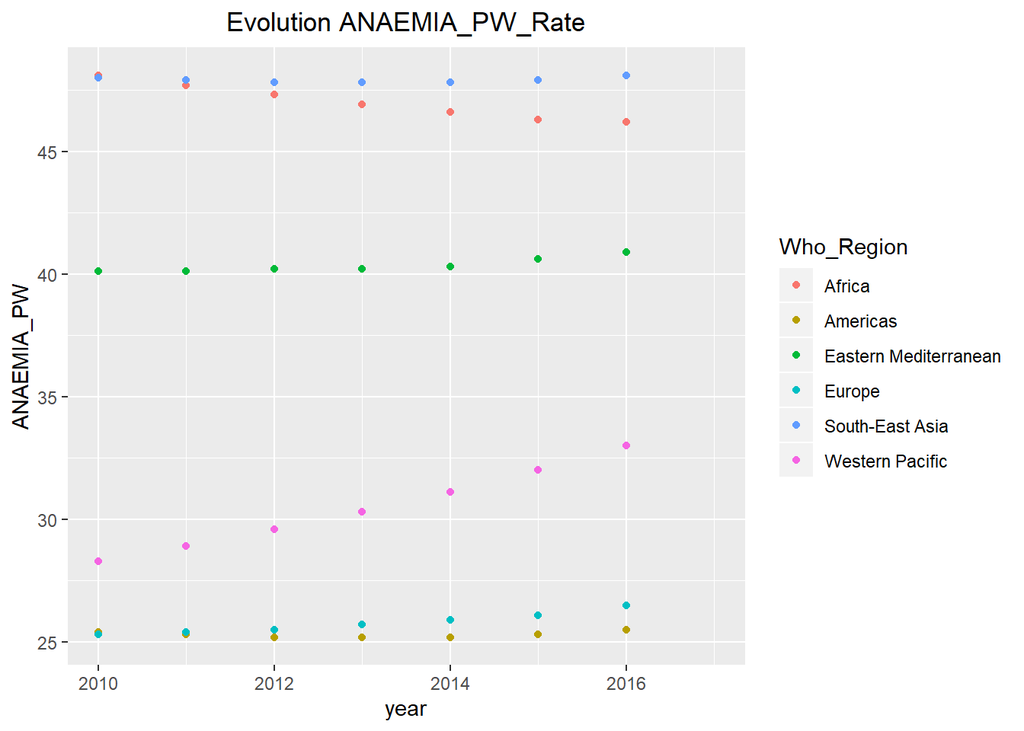

```r
dataset_Anaemia<-dataset %>% select(Who_Region,year,ANAEMIA_PW,ANAEMIA_RW)

ggplot(dataset_Anaemia,aes(x=year,y=ANAEMIA_PW))+
  geom_point(aes(col=Who_Region))+
  ggtitle("Evolution ANAEMIA_PW_Rate")+
  theme(plot.title = element_text(hjust = 0.5))
```

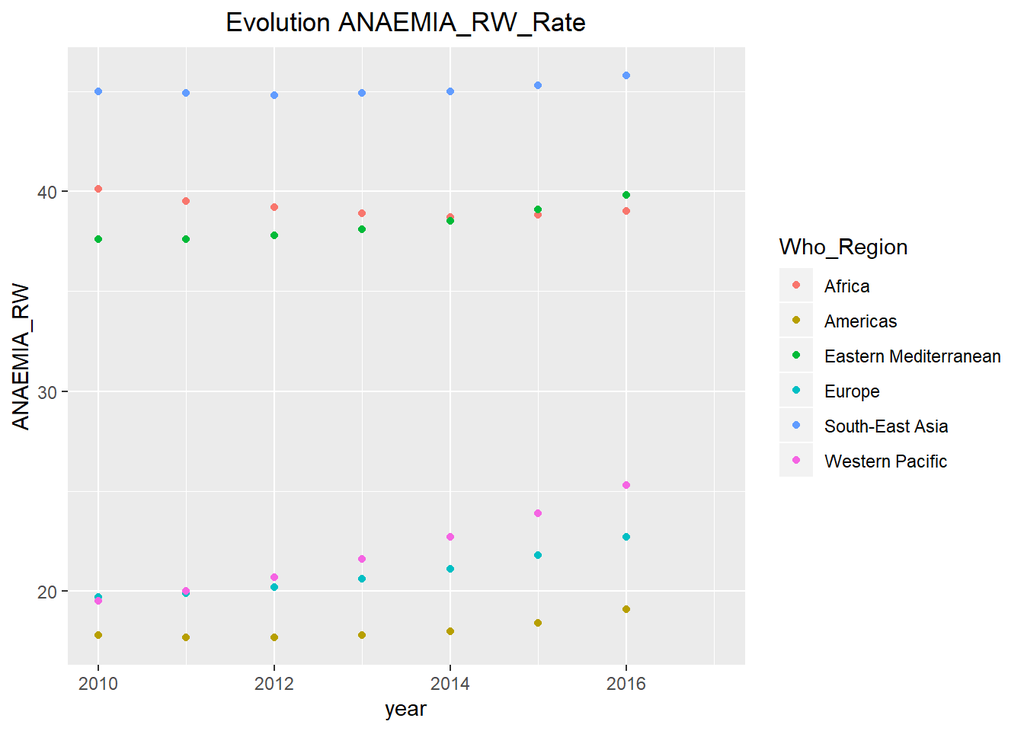

```r
ggplot(dataset_Anaemia,aes(x=year,y=ANAEMIA_RW))+
  geom_point(aes(col=Who_Region))+
  ggtitle("Evolution ANAEMIA_RW_Rate")+
  theme(plot.title = element_text(hjust = 0.5))
```

#### Estimación por “lm” para el indicador “ANAEMIA_PW”

1. Todas los modelos obtienen un R2 superior a 0.83.
2. Se calculan las predicciones con *predict*

```r
dataset_Anaemia<-dataset %>% select(Who_Region,year,ANAEMIA_PW,ANAEMIA_RW) %>% filter (year >= "2013")

Anaemia_Africa<-dataset_Anaemia%>% filter(Who_Region=="Africa")
Anaemia_Americas<-dataset_Anaemia%>% filter(Who_Region=="Americas")
Anaemia_Eastern_Mediterranean<-dataset_Anaemia%>% filter(Who_Region=="Eastern Mediterranean")
Anaemia_Europe<-dataset_Anaemia%>% filter(Who_Region=="Europe")
Anaemia_South_East_Asia<-dataset_Anaemia%>% filter(Who_Region=="South-East Asia")
Anaemia_Western_Pacific<-dataset_Anaemia%>% filter(Who_Region=="Western Pacific")

model_Africa<-lm(ANAEMIA_PW~year,data=Anaemia_Africa)
model_Americas<-lm(ANAEMIA_PW~year,data=Anaemia_Americas)
model_Eastern_Mediterranean<-lm(ANAEMIA_PW~year,data=Anaemia_Eastern_Mediterranean)
model_Europe<-lm(ANAEMIA_PW~year,data=Anaemia_Europe)
model_South_East_Asia<-lm(ANAEMIA_PW~year,data=Anaemia_South_East_Asia)
model_Western_Pacific<-lm(ANAEMIA_PW~year,data=Anaemia_Western_Pacific)

summary(model_Africa)
```

```
##
## Call:
## lm(formula = ANAEMIA_PW ~ year, data = Anaemia_Africa)
##
## Residuals:
##     1     2     3     4
##  0.04 -0.02 -0.08  0.06
##
## Coefficients:
##              Estimate Std. Error t value Pr(>|t|)
## (Intercept) 529.98000   69.78434   7.595   0.0169 *
## year         -0.24000    0.03464  -6.928   0.0202 *
## ---
## Signif. codes:  0 '***' 0.001 '**' 0.01 '*' 0.05 '.' 0.1 ' ' 1
##
## Residual standard error: 0.07746 on 2 degrees of freedom
##   (1 observation deleted due to missingness)
## Multiple R-squared:   0.96,  Adjusted R-squared:   0.94
## F-statistic:    48 on 1 and 2 DF,  p-value: 0.0202
```

```r
summary(model_Americas)
```

```
##
## Call:
## lm(formula = ANAEMIA_PW ~ year, data = Anaemia_Americas)
##
## Residuals:
##     1     2     3     4
##  0.05 -0.05 -0.05  0.05
##
## Coefficients:
##               Estimate Std. Error t value Pr(>|t|)
## (Intercept) -176.15000   63.70409  -2.765   0.1097
## year           0.10000    0.03162   3.162   0.0871 .
## ---
## Signif. codes:  0 '***' 0.001 '**' 0.01 '*' 0.05 '.' 0.1 ' ' 1
##
## Residual standard error: 0.07071 on 2 degrees of freedom
##   (1 observation deleted due to missingness)
## Multiple R-squared:  0.8333, Adjusted R-squared:   0.75
## F-statistic:    10 on 1 and 2 DF,  p-value: 0.08713
```

```r
summary(model_Eastern_Mediterranean)
```

```
##
## Call:
## lm(formula = ANAEMIA_PW ~ year, data = Anaemia_Eastern_Mediterranean)
##
## Residuals:
##     1     2     3     4
##  0.06 -0.08 -0.02  0.04
##
## Coefficients:
##               Estimate Std. Error t value Pr(>|t|)
## (Intercept) -442.98000   69.78434  -6.348   0.0239 *
## year           0.24000    0.03464   6.928   0.0202 *
## ---
## Signif. codes:  0 '***' 0.001 '**' 0.01 '*' 0.05 '.' 0.1 ' ' 1
##
## Residual standard error: 0.07746 on 2 degrees of freedom
##   (1 observation deleted due to missingness)
## Multiple R-squared:   0.96,  Adjusted R-squared:   0.94
## F-statistic:    48 on 1 and 2 DF,  p-value: 0.0202
```

```r
summary(model_Europe)
```

```
##
## Call:
## lm(formula = ANAEMIA_PW ~ year, data = Anaemia_Europe)
##
## Residuals:
##     1     2     3     4
##  0.04 -0.02 -0.08  0.06
##
## Coefficients:
##               Estimate Std. Error t value Pr(>|t|)
## (Intercept) -497.72000   69.78434  -7.132   0.0191 *
## year           0.26000    0.03464   7.506   0.0173 *
## ---
## Signif. codes:  0 '***' 0.001 '**' 0.01 '*' 0.05 '.' 0.1 ' ' 1
##
## Residual standard error: 0.07746 on 2 degrees of freedom
##   (1 observation deleted due to missingness)
## Multiple R-squared:  0.9657, Adjusted R-squared:  0.9486
## F-statistic: 56.33 on 1 and 2 DF,  p-value: 0.01729
```

```r
summary(model_South_East_Asia)
```

```
##
## Call:
## lm(formula = ANAEMIA_PW ~ year, data = Anaemia_South_East_Asia)
##
## Residuals:
##     1     2     3     4
##  0.05 -0.05 -0.05  0.05
##
## Coefficients:
##               Estimate Std. Error t value Pr(>|t|)
## (Intercept) -153.55000   63.70409  -2.410   0.1375
## year           0.10000    0.03162   3.162   0.0871 .
## ---
## Signif. codes:  0 '***' 0.001 '**' 0.01 '*' 0.05 '.' 0.1 ' ' 1
##
## Residual standard error: 0.07071 on 2 degrees of freedom
##   (1 observation deleted due to missingness)
## Multiple R-squared:  0.8333, Adjusted R-squared:   0.75
## F-statistic:    10 on 1 and 2 DF,  p-value: 0.08713
```

```r
summary(model_Western_Pacific)
```

```
##
## Call:
## lm(formula = ANAEMIA_PW ~ year, data = Anaemia_Western_Pacific)
##
## Residuals:
##     1     2     3     4
##  0.05 -0.05 -0.05  0.05
##
## Coefficients:
##               Estimate Std. Error t value Pr(>|t|)
## (Intercept) -1.781e+03  6.370e+01  -27.96  0.00128 **
## year         9.000e-01  3.162e-02   28.46  0.00123 **
## ---
## Signif. codes:  0 '***' 0.001 '**' 0.01 '*' 0.05 '.' 0.1 ' ' 1
##
## Residual standard error: 0.07071 on 2 degrees of freedom
##   (1 observation deleted due to missingness)
## Multiple R-squared:  0.9975, Adjusted R-squared:  0.9963
## F-statistic:   810 on 1 and 2 DF,  p-value: 0.001232
```

```r
new_data<-data.frame(year=c(2017))
pred_Africa<-model_Africa %>% predict(new_data)
pred_Americas<-model_Americas %>% predict(new_data)
pred_Eastern_Mediterranean<-model_Eastern_Mediterranean %>% predict(new_data)
pred_Europe<-model_Europe %>% predict(new_data)
pred_South_East_Asia<-model_South_East_Asia %>% predict(new_data)
pred_Western_Pacific<-model_Western_Pacific %>% predict(new_data)


pred_Africa<-data.frame(Who_Region=c("Africa"),year=c(2017),ANAEMIA_PW=pred_Africa)
pred_Americas<-data.frame(Who_Region=c("Americas"),year=c(2017),ANAEMIA_PW=pred_Americas)
pred_Eastern_Mediterranean<-data.frame(Who_Region=c("Eastern Mediterranean"),year=c(2017),ANAEMIA_PW=pred_Eastern_Mediterranean)
pred_Europe<-data.frame(Who_Region=c("Europe"),year=c(2017),ANAEMIA_PW=pred_Europe)
pred_South_East_Asia<-data.frame(Who_Region=c("South-East Asia"),year=c(2017),ANAEMIA_PW=pred_South_East_Asia)
pred_Western_Pacific<-data.frame(Who_Region=c("Western Pacific"),year=c(2017),ANAEMIA_PW=pred_Western_Pacific)

pred_Anaemia_PW<-data.frame(rbind(pred_Africa,pred_Americas,pred_Eastern_Mediterranean,pred_Europe,pred_South_East_Asia,pred_Western_Pacific))

pred_Anaemia_PW$Who_Region<-as.character(pred_Anaemia_PW$Who_Region)
pred_Anaemia_PW$ANAEMIA_PW<-round(pred_Anaemia_PW$ANAEMIA_PW,1)
pred_Anaemia_PW$year<-as.integer(pred_Anaemia_PW$year)
ANAEMIA_PW<-rbind(ANAEMIA_PW,pred_Anaemia_PW)
glimpse(ANAEMIA_PW)
```

```
## Observations: 55
## Variables: 3
## $ Who_Region <chr> "Global", "Global", "Global", "Global", "Global", "Globa...
## $ year       <int> 2016, 2015, 2014, 2013, 2012, 2011, 2010, 2016, 2015, 20...
## $ ANAEMIA_PW <dbl> 40.1, 39.8, 39.6, 39.5, 39.4, 39.3, 39.4, 46.2, 46.3, 46...
```

#### Estimación por “lm” para el indicador “ANAEMIA_RW”

```r
model_Africa<-lm(ANAEMIA_RW~year,data=Anaemia_Africa)
model_Americas<-lm(ANAEMIA_RW~year,data=Anaemia_Americas)
model_Eastern_Mediterranean<-lm(ANAEMIA_RW~year,data=Anaemia_Eastern_Mediterranean)
model_Europe<-lm(ANAEMIA_RW~year,data=Anaemia_Europe)
model_South_East_Asia<-lm(ANAEMIA_RW~year,data=Anaemia_South_East_Asia)
model_Western_Pacific<-lm(ANAEMIA_RW~year,data=Anaemia_Western_Pacific)

summary(model_Africa)
```

```
##
## Call:
## lm(formula = ANAEMIA_RW ~ year, data = Anaemia_Africa)
##
## Residuals:
##     1     2     3     4
##  0.11 -0.13 -0.07  0.09
##
## Coefficients:
##              Estimate Std. Error t value Pr(>|t|)
## (Intercept) -41.73000  130.55454  -0.320     0.78
## year          0.04000    0.06481   0.617     0.60
##
## Residual standard error: 0.1449 on 2 degrees of freedom
##   (1 observation deleted due to missingness)
## Multiple R-squared:   0.16,  Adjusted R-squared:  -0.26
## F-statistic: 0.381 on 1 and 2 DF,  p-value: 0.6
```

```r
summary(model_Americas)
```

```
##
## Call:
## lm(formula = ANAEMIA_RW ~ year, data = Anaemia_Americas)
##
## Residuals:
##     1     2     3     4
##  0.12 -0.11 -0.14  0.13
##
## Coefficients:
##               Estimate Std. Error t value Pr(>|t|)
## (Intercept) -847.91000  159.89601  -5.303   0.0338 *
## year           0.43000    0.07937   5.417   0.0324 *
## ---
## Signif. codes:  0 '***' 0.001 '**' 0.01 '*' 0.05 '.' 0.1 ' ' 1
##
## Residual standard error: 0.1775 on 2 degrees of freedom
##   (1 observation deleted due to missingness)
## Multiple R-squared:  0.9362, Adjusted R-squared:  0.9043
## F-statistic: 29.35 on 1 and 2 DF,  p-value: 0.03242
```

```r
summary(model_Eastern_Mediterranean)
```

```
##
## Call:
## lm(formula = ANAEMIA_RW ~ year, data = Anaemia_Eastern_Mediterranean)
##
## Residuals:
##     1     2     3     4
##  0.08 -0.09 -0.06  0.07
##
## Coefficients:
##               Estimate Std. Error t value Pr(>|t|)
## (Intercept) -1.109e+03  9.661e+01  -11.48   0.0075 **
## year         5.700e-01  4.796e-02   11.88   0.0070 **
## ---
## Signif. codes:  0 '***' 0.001 '**' 0.01 '*' 0.05 '.' 0.1 ' ' 1
##
## Residual standard error: 0.1072 on 2 degrees of freedom
##   (1 observation deleted due to missingness)
## Multiple R-squared:  0.986,  Adjusted R-squared:  0.9791
## F-statistic: 141.3 on 1 and 2 DF,  p-value: 0.007005
```

```r
summary(model_Europe)
```

```
##
## Call:
## lm(formula = ANAEMIA_RW ~ year, data = Anaemia_Europe)
##
## Residuals:
##    1    2    3    4
##  0.1 -0.1 -0.1  0.1
##
## Coefficients:
##               Estimate Std. Error t value Pr(>|t|)
## (Intercept) -1.389e+03  1.274e+02  -10.90  0.00831 **
## year         7.000e-01  6.325e-02   11.07  0.00806 **
## ---
## Signif. codes:  0 '***' 0.001 '**' 0.01 '*' 0.05 '.' 0.1 ' ' 1
##
## Residual standard error: 0.1414 on 2 degrees of freedom
##   (1 observation deleted due to missingness)
## Multiple R-squared:  0.9839, Adjusted R-squared:  0.9759
## F-statistic: 122.5 on 1 and 2 DF,  p-value: 0.008065
```

```r
summary(model_South_East_Asia)
```

```
##
## Call:
## lm(formula = ANAEMIA_RW ~ year, data = Anaemia_South_East_Asia)
##
## Residuals:
##    1    2    3    4
##  0.1 -0.1 -0.1  0.1
##
## Coefficients:
##               Estimate Std. Error t value Pr(>|t|)
## (Intercept) -559.10000  127.40819  -4.388   0.0482 *
## year           0.30000    0.06325   4.743   0.0417 *
## ---
## Signif. codes:  0 '***' 0.001 '**' 0.01 '*' 0.05 '.' 0.1 ' ' 1
##
## Residual standard error: 0.1414 on 2 degrees of freedom
##   (1 observation deleted due to missingness)
## Multiple R-squared:  0.9184, Adjusted R-squared:  0.8776
## F-statistic:  22.5 on 1 and 2 DF,  p-value: 0.04169
```

```r
summary(model_Western_Pacific)
```

```
##
## Call:
## lm(formula = ANAEMIA_RW ~ year, data = Anaemia_Western_Pacific)
##
## Residuals:
##     1     2     3     4
##  0.07 -0.06 -0.09  0.08
##
## Coefficients:
##               Estimate Std. Error t value Pr(>|t|)
## (Intercept) -2.454e+03  9.661e+01  -25.41  0.00155 **
## year         1.230e+00  4.796e-02   25.65  0.00152 **
## ---
## Signif. codes:  0 '***' 0.001 '**' 0.01 '*' 0.05 '.' 0.1 ' ' 1
##
## Residual standard error: 0.1072 on 2 degrees of freedom
##   (1 observation deleted due to missingness)
## Multiple R-squared:  0.997,  Adjusted R-squared:  0.9955
## F-statistic: 657.8 on 1 and 2 DF,  p-value: 0.001517
```

```r
new_data<-data.frame(year=c(2017))
pred_Africa<-model_Africa %>% predict(new_data)
pred_Americas<-model_Americas %>% predict(new_data)
pred_Eastern_Mediterranean<-model_Eastern_Mediterranean %>% predict(new_data)
pred_Europe<-model_Europe %>% predict(new_data)
pred_South_East_Asia<-model_South_East_Asia %>% predict(new_data)
pred_Western_Pacific<-model_Western_Pacific %>% predict(new_data)


pred_Africa<-data.frame(Who_Region=c("Africa"),year=c(2017),ANAEMIA_RW=pred_Africa)
pred_Americas<-data.frame(Who_Region=c("Americas"),year=c(2017),ANAEMIA_RW=pred_Americas)
pred_Eastern_Mediterranean<-data.frame(Who_Region=c("Eastern Mediterranean"),year=c(2017),ANAEMIA_RW=pred_Eastern_Mediterranean)
pred_Europe<-data.frame(Who_Region=c("Europe"),year=c(2017),ANAEMIA_RW=pred_Europe)
pred_South_East_Asia<-data.frame(Who_Region=c("South-East Asia"),year=c(2017),ANAEMIA_RW=pred_South_East_Asia)
pred_Western_Pacific<-data.frame(Who_Region=c("Western Pacific"),year=c(2017),ANAEMIA_RW=pred_Western_Pacific)

pred_Anaemia_RW<-data.frame(rbind(pred_Africa,pred_Americas,pred_Eastern_Mediterranean,pred_Europe,pred_South_East_Asia,pred_Western_Pacific))

pred_Anaemia_RW$Who_Region<-as.character(pred_Anaemia_RW$Who_Region)
pred_Anaemia_RW$ANAEMIA_RW<-round(pred_Anaemia_RW$ANAEMIA_RW,1)
pred_Anaemia_RW$year<-as.integer(pred_Anaemia_RW$year)
ANAEMIA_RW<-rbind(ANAEMIA_RW,pred_Anaemia_RW)
glimpse(ANAEMIA_RW)
```

```
## Observations: 55
## Variables: 3
## $ Who_Region <chr> "Global", "Global", "Global", "Global", "Global", "Globa...
## $ year       <int> 2016, 2015, 2014, 2013, 2012, 2011, 2010, 2016, 2015, 20...
## $ ANAEMIA_RW <dbl> 32.8, 32.0, 31.3, 30.7, 30.3, 30.0, 29.9, 39.0, 38.8, 38...
```

#### Actualizando los valores estimados en el “dataset”

```r
dataset<-dataset %>% select(-Life_expectancy_at_birth,-ANAEMIA_RW,-ANAEMIA_PW) ## por error reiterativo en el merge siguiente, se decide incluir esta línea de comandos para solucionarlo.
dataset<-Reduce(function(...) merge (..., all.x=TRUE), list(dataset,ANAEMIA_RW,ANAEMIA_PW,Life_expectancy_birth))
glimpse(dataset)
```

```
## Observations: 48
## Variables: 43
## $ Who_Region               <chr> "Africa", "Africa", "Africa", "Africa", "A...
## $ year                     <int> 2010, 2011, 2012, 2013, 2014, 2015, 2016, ...
## $ Rate_Mort_Child          <dbl> 99.4, 95.4, 91.8, 88.5, 85.6, 83.0, 80.5, ...
## $ Legislation              <int> 29, 32, 32, 41, 60, 69, 67, 54, 47, 66, 64...
## $ Coordination             <int> 56, 49, 52, 57, 67, 70, 71, 60, 77, 73, 70...
## $ Surveillance             <int> 61, 65, 71, 69, 77, 81, 83, 76, 59, 77, 82...
## $ Response                 <int> 47, 56, 62, 66, 72, 79, 73, 68, 62, 75, 78...
## $ Preparedness             <int> 25, 36, 45, 40, 53, 58, 55, 55, 40, 57, 55...
## $ Risk_communication       <int> 48, 44, 51, 51, 61, 64, 68, 60, 61, 70, 65...
## $ Human_resources          <int> 25, 33, 45, 45, 56, 64, 51, 57, 44, 54, 57...
## $ Laboratory               <int> 51, 65, 68, 69, 73, 77, 75, 73, 61, 73, 79...
## $ Points_entry             <int> 47, 38, 29, 23, 35, 38, 39, 33, 55, 44, 63...
## $ Zoonosis                 <int> 63, 59, 70, 67, 68, 73, 79, 75, 59, 78, 83...
```

[output cut: 30 more lines]

```r
unique(dataset$Who_Region)
```

```
## [1] "Africa"                "Americas"              "Eastern Mediterranean"
## [4] "Europe"                "South-East Asia"       "Western Pacific"
```

```r
unique(dataset$year)
```

```
## [1] 2010 2011 2012 2013 2014 2015 2016 2017
```

#### Verificando estadísticas del dataset y los valores Nulls & NAs.

1. Ya no tenemos más valores NAs que estimar, el indicador sale a 0.

```r
dataset_num<-select_if(dataset,is.numeric)
stat_dataset<-stat.desc(dataset_num)
stat_dataset<-round(stat_dataset,1)
stat_dataset
```

```
##                 year Rate_Mort_Child Legislation Coordination Surveillance
## nbr.val         48.0            48.0        48.0         48.0         48.0
## nbr.null         0.0             0.0         0.0          0.0          0.0
## nbr.na           0.0             0.0         0.0          0.0          0.0
## min           2010.0             9.0        29.0         49.0         59.0
## max           2017.0            99.4        92.0         96.0         92.0
## range            7.0            90.4        63.0         47.0         33.0
## sum          96648.0          1806.3      3491.0       3694.0       3854.0
## median        2013.5            27.4        76.0         78.0         82.5
## mean          2013.5            37.6        72.7         77.0         80.3
## SE.mean          0.3             4.1         2.2          1.5          1.3
## CI.mean.0.95     0.7             8.1         4.5          3.0          2.6
## var              5.4           787.8       237.7        109.5         79.2
## std.dev          2.3            28.1        15.4         10.5          8.9
## coef.var         0.0             0.7         0.2          0.1          0.1
##              Response Preparedness Risk_communication Human_resources
## nbr.val          48.0         48.0               48.0            48.0
## nbr.null          0.0          0.0                0.0             0.0
## nbr.na            0.0          0.0                0.0             0.0
## min              47.0         25.0               44.0            25.0
## max              91.0         91.0               95.0            89.0
## range            44.0         66.0               51.0            64.0
## sum            3799.0       3153.0             3536.0          2828.0
## median           79.5         68.5               75.5            57.5
## mean             79.1         65.7               73.7            58.9
## SE.mean           1.3          2.0                1.7             1.9
## CI.mean.0.95      2.7          4.1                3.5             3.9
## var              85.8        196.8              143.8           177.8
## std.dev           9.3         14.0               12.0            13.3
## coef.var          0.1          0.2                0.2             0.2
##              Laboratory Points_entry Zoonosis Food_safety Chemical Radionuclear
## nbr.val            48.0         48.0     48.0        48.0     48.0         48.0
## nbr.null            0.0          0.0      0.0         0.0      0.0          0.0
## nbr.na              0.0          0.0      0.0         0.0      0.0          0.0
## min                51.0         23.0     59.0        41.0     11.0         20.0
## max                92.0         82.0     96.0        95.0     82.0         88.0
## range              41.0         59.0     37.0        54.0     71.0         68.0
## sum              3725.0       2811.0   3929.0      3529.0   2423.0       2519.0
## median             78.0         62.0     83.0        77.0     50.0         51.0
## mean               77.6         58.6     81.9        73.5     50.5         52.5
```

[output cut: 125 more lines]

```
##              ANAEMIA_PW Life_expectancy_at_birth
## nbr.val            48.0                     48.0
## nbr.null            0.0                      0.0
## nbr.na              0.0                      0.0
## min                25.2                     57.6
## max                48.2                     77.8
## range              23.0                     20.2
## sum              1738.8                   3411.2
## median             37.0                     72.6
## mean               36.2                     71.1
## SE.mean             1.4                      0.9
## CI.mean.0.95        2.7                      1.8
## var                89.6                     39.4
## std.dev             9.5                      6.3
## coef.var            0.3                      0.1
```

```r
stat_dataset[,(stat_dataset["nbr.null",]>0)]
```

```
##              Mort_HIVAIDS_dis_rate Mort_Malaria_rate Mort_Measles_rate
## nbr.val                       48.0              48.0              48.0
## nbr.null                      15.0              17.0              18.0
## nbr.na                         0.0               0.0               0.0
## min                            0.0               0.0               0.0
## max                            4.1              12.9               2.8
## range                          4.1              12.9               2.8
## sum                           23.9              78.4              37.5
## median                         0.1               0.1               0.4
## mean                           0.5               1.6               0.8
## SE.mean                        0.1               0.5               0.1
## CI.mean.0.95                   0.3               1.1               0.3
## var                            1.1              13.2               0.8
## std.dev                        1.0               3.6               0.9
## coef.var                       2.1               2.2               1.1
##              Mort_Tetanos_rate Inm_PCV3_coverage Inm_ROTAC_coverage
## nbr.val                   48.0              48.0               48.0
## nbr.null                  24.0               5.0                7.0
## nbr.na                     0.0               0.0                0.0
## min                        0.0               0.0                0.0
## max                        1.0              85.0               76.0
## range                      1.0              85.0               76.0
## sum                       12.6            1676.0              991.0
## median                     0.1              36.5                7.5
## mean                       0.3              34.9               20.6
## SE.mean                    0.0               4.2                3.7
## CI.mean.0.95               0.1               8.4                7.4
## var                        0.1             843.2              657.0
## std.dev                    0.3              29.0               25.6
## coef.var                   1.2               0.8                1.2
```

```r
stat_dataset[,(stat_dataset["nbr.na",]>0)]
```

```
## data frame with 0 columns and 14 rows
```

#### SELECCIÓN DE MODELOS: **REGRESION PENALIZADA “CRESTA”**

1. Se va a aplicar para validar el modelo **“Cross Validation K-fold(5)”**
2. Se utilizará la función *train* del paquete **caret** con la selección **alpha=0** para el modelo **Cresta**
3. Se estandarizan los datos con “scale=TRUE”
4. La regresión de cresta reduce los coeficientes de regresión, de modo que las variables, con una contribución menor al resultado, tienen sus coeficientes cercanos a cero. La penalización se ajusta utilizando una constante lambda.
5. Una desventaja es que incluirá todos los coeficientes en el modelo final.

```r
set.seed(123)
training_samples<-dataset$Rate_Mort_Child %>%
  createDataPartition(p=0.8,list=FALSE)
train_data<-dataset[training_samples,]
test_data<-dataset[-training_samples,]

lambda<-seq(-3,3,length=100)
set.seed(123)
model_ridge<- train(
  Rate_Mort_Child~.,data=train_data,method="glmnet",
  trControl=trainControl("cv",number=5),
  scale=TRUE,
  tuneGrid=expand.grid(alpha=0,lambda=lambda)
)

data.frame("best_lambda", value=model_ridge$bestTune$lambda)
```

```
##   X.best_lambda. value
## 1    best_lambda     3
```

```r
coef(model_ridge$finalModel,model_ridge$bestTune$lambda)
```

```
## 47 x 1 sparse Matrix of class "dgCMatrix"
##                                             1
## (Intercept)                      1.155471e+02
## Who_RegionAmericas              -8.754368e-01
## Who_RegionEastern Mediterranean  6.533093e-01
## Who_RegionEurope                -1.001479e+00
## Who_RegionSouth-East Asia       -7.041080e-02
## Who_RegionWestern Pacific       -5.492108e-01
## year                            -7.324492e-03
## Legislation                     -2.721357e-02
## Coordination                    -3.874303e-02
## Surveillance                    -3.577252e-02
## Response                        -4.989085e-02
## Preparedness                    -3.275243e-02
## Risk_communication              -3.751198e-02
## Human_resources                 -8.617884e-03
## Laboratory                      -3.631424e-02
## Points_entry                    -4.300762e-02
## Zoonosis                        -3.840077e-02
## Food_safety                     -4.226913e-02
## Chemical                        -3.433052e-02
## Radionuclear                    -2.393854e-02
## Mort_Asphyxia_rate               2.411669e-01
## Mort_Congenital_rate             9.009260e-01
## Mort_Diarrhoeal_rate             2.723099e-01
## Mort_HIVAIDS_dis_rate            6.288608e-01
## Mort_Malaria_rate                1.826905e-01
## Mort_Measles_rate                8.526774e-01
## Mort_Meningitis_rate             8.830451e-01
## Mort_Other_rate                  3.082904e-01
## Mort_Respiratory_rate            1.692054e-01
## Mort_Prematurity_rate            1.626842e-01
## Mort_Sepsis_rate                 4.252765e-01
## Mort_Tetanos_rate                1.890816e+00
## Inm_BCG_coverage                -1.266348e-01
## Inm_DTP3_coverage               -8.985403e-02
## Inm_Hib3_coverage               -3.013715e-04
## Inm_HepB3_coverage              -5.950443e-02
## Inm_MCV1_1st_coverage           -8.724364e-02
## Inm_MCV2_2nd_coverage           -2.585119e-02
## Inm_PCV3_coverage               -6.183401e-03
## Inm_Pol3_coverage               -8.820243e-02
## Inm_ROTAC_coverage              -6.386694e-03
## ANAEMIA_Children5                4.523514e-02
## Low_birth_weight                 6.218932e-02
## Maternal_Mort_Rate               4.234292e-03
## ANAEMIA_RW                       5.813474e-02
## ANAEMIA_PW                       7.296532e-02
## Life_expectancy_at_birth        -1.275454e-01
```

#### Métricas resultado “Cross-Validation k-fold” para “Cresta”

1. Se observa que el R2 es bueno (0.98), pero el RMSE y el MAE, son muy altos, obteniendo una Tasa de Error en Train del 23%.

```r
Metricas_train_ridge<-data.frame("metrics_train"="metrics_train_ridge",Mean_RMSE=mean(model_ridge$resample$RMSE),
Mean_MAE=mean(model_ridge$resample$MAE),
Mean_RSquared=mean(model_ridge$resample$Rsquared),
Tasa_Error_Train=mean(model_ridge$resample$RMSE)/mean(train_data$Rate_Mort_Child))


Metricas_train_ridge
```

```
##         metrics_train Mean_RMSE Mean_MAE Mean_RSquared Tasa_Error_Train
## 1 metrics_train_ridge  8.576542 7.126869     0.9802597        0.2298263
```

#### Métricas de las predicciones para test en Regression “Cresta”

1. Tasa de Error para test, muy elevada casi 26%. Con RMSE y MAE, también muy altos. Y R2 bueno.
2. Comparando train y test, observamos que no hay overfitting.

```r
predictions_ridge<-model_ridge %>% predict(test_data)
Metricas_ridge_test<-data.frame("metrics_test"="metrics_test_ridge",
  RMSE=RMSE(predictions_ridge,test_data$Rate_Mort_Child),
  MAE=MAE(predictions_ridge,test_data$Rate_Mort_Child),
  RSquared=caret::R2(predictions_ridge,test_data$Rate_Mort_Child),
  Tasa_Error_Test=RMSE(predictions_ridge,test_data$Rate_Mort_Child)/mean(test_data$Rate_Mort_Child)
)
Metricas_ridge_test
```

```
##         metrics_test     RMSE      MAE  RSquared Tasa_Error_Test
## 1 metrics_test_ridge 10.01707 8.680324 0.9701152       0.2555374
```

#### SELECCIÓN DE MODELOS: **REGRESION PENALIZADA “LASSO”**

1. Se va a aplicar para validar el modelo **“Cross Validation K-fold(5)”**
2. Se utilizará la función *train* del paquete **caret** con la selección **alpha=1** para el modelo **Lasso**
3. Se estandarizan los datos con “scale=TRUE”
4. La regresión de Lasso tiene el efecto de forzar que algunas estimaciones de coeficientes de contribución menor, sean exactamente iguales a 0.
5. La ventaja es que producirá modelos más simples e interpretables que la regresión de cresta.
6. El modelo incluiría estas variables: **Mort_Congenital_rate + Mort_Diarrhoeal_rate + Mort_Meningitis_rate + Mort_Other_rate + Mort_Respiratory_rate + Life_expectancy_at_birth**

```r
lambda<-seq(-3,3,length=100)
set.seed(123)
model_lasso<- train(
  Rate_Mort_Child~.,data=train_data,method="glmnet",
  trControl=trainControl("cv",number=5),
  scale=TRUE,
  tuneGrid=expand.grid(alpha=1,lambda=lambda)
)

data.frame("best_lambda", value=model_lasso$bestTune$lambda)
```

```
##   X.best_lambda.     value
## 1    best_lambda 0.6363636
```

```r
coef(model_lasso$finalModel,model_lasso$bestTune$lambda)
```

```
## 47 x 1 sparse Matrix of class "dgCMatrix"
##                                           1
## (Intercept)                     22.22887339
## Who_RegionAmericas               .
## Who_RegionEastern Mediterranean  .
## Who_RegionEurope                 .
## Who_RegionSouth-East Asia        .
## Who_RegionWestern Pacific        .
## year                             .
## Legislation                      .
## Coordination                     .
## Surveillance                     .
## Response                         .
## Preparedness                     .
## Risk_communication               .
## Human_resources                  .
## Laboratory                       .
## Points_entry                     .
## Zoonosis                         .
## Food_safety                      .
## Chemical                         .
## Radionuclear                     .
## Mort_Asphyxia_rate               .
## Mort_Congenital_rate             0.50435211
## Mort_Diarrhoeal_rate             3.45874279
## Mort_HIVAIDS_dis_rate            .
## Mort_Malaria_rate                .
## Mort_Measles_rate                .
## Mort_Meningitis_rate             0.02405973
## Mort_Other_rate                  3.87070593
## Mort_Respiratory_rate            1.11602603
## Mort_Prematurity_rate            .
## Mort_Sepsis_rate                 .
## Mort_Tetanos_rate                .
## Inm_BCG_coverage                 .
## Inm_DTP3_coverage                .
## Inm_Hib3_coverage                .
## Inm_HepB3_coverage               .
## Inm_MCV1_1st_coverage            .
## Inm_MCV2_2nd_coverage            .
## Inm_PCV3_coverage                .
## Inm_Pol3_coverage                .
## Inm_ROTAC_coverage               .
## ANAEMIA_Children5                .
## Low_birth_weight                 .
## Maternal_Mort_Rate               .
## ANAEMIA_RW                       .
## ANAEMIA_PW                       .
## Life_expectancy_at_birth        -0.22978738
```

#### Métricas resultado “Cross-Validation k-fold” para “Lasso”

1. Valores mucho mejores que para la regresión con Cresta, la tasa de Error no supera el 2.5%, con un R2 de 99.95%, y unos valores de RMSE y MAE no superiores a 1.

```r
Metricas_train_lasso<-data.frame("metrics_train"="metrics_train_lasso",Mean_RMSE=mean(model_lasso$resample$RMSE),Mean_MAE=mean(model_lasso$resample$MAE),
Mean_RSquared=mean(model_lasso$resample$Rsquared),
Tasa_Error_Train=mean(model_lasso$resample$RMSE)/mean(train_data$Rate_Mort_Child))

Metricas_train_lasso
```

```
##         metrics_train Mean_RMSE  Mean_MAE Mean_RSquared Tasa_Error_Train
## 1 metrics_train_lasso 0.9156556 0.7635022     0.9995945        0.0245369
```

#### Métricas de las predicciones para test “Lasso”

1. Valores muy similares a los de train, lo que quieres decir que no tenemos overfitting.

```r
predictions_lasso<-model_lasso %>% predict(test_data)
Metricas_lasso_test<-data.frame("metrics_test"="metrics_test_lasso",
  RMSE=RMSE(predictions_lasso,test_data$Rate_Mort_Child),
  MAE=MAE(predictions_lasso,test_data$Rate_Mort_Child),
  RSquared=caret::R2(predictions_lasso,test_data$Rate_Mort_Child),
  Tasa_Error_Test=RMSE(predictions_lasso,test_data$Rate_Mort_Child)/mean(test_data$Rate_Mort_Child)
)
Metricas_lasso_test
```

```
##         metrics_test     RMSE       MAE  RSquared Tasa_Error_Test
## 1 metrics_test_lasso 1.128962 0.9627683 0.9992219      0.02880006
```

#### SELECCIÓN DE MODELOS: **REGRESION PENALIZADA “NET ELASTIC”**

1. Se va a aplicar para validar el modelo **“Cross Validation K-fold(5)”**
2. Se utilizará la función *train* del paquete **caret** con **tuneLength=10** para el modelo **Net_Elastic**
3. Se estandarizan los datos con “scale=TRUE”
4. Produce un modelo regresión penalizado tanto por la L1-Norma y L2-Norma, para reducir los coeficientes (como en la regresión de Cresta) y establecer algunos coeficientes a 0 (como en la regresión de Lasso)
5. Con el paquete caret y la opción *tuneLength=10* se seleccionarán automáticamente los mejores parámetros de ajuste alpha y y lambda (combinaciones de 10 valores diferentes de alpha y lambda). Los mejores son los que minimizan el error de la validación cruzada.
6. El warning **There were missing values in resampled performance measures** que sale es para la combinación de algunos parámetros de alpha y lambda(se muestra el data.frame con los NaN).
7. Alpha=0.4 y lambda=1.28 son los parámetros que minimizan el error de validación cruzada.
8. El modelo final incluiría no sólo variables de **“Mort_Rate_Cause”**, también del grupo **“International_Health_Regulations”**, del grupo **“Inmunization”**, **“Child_Malnutrition”** y ** “Life_Expectancy”**

```r
set.seed(123)
model_elastic<- train(
  Rate_Mort_Child~.,data=train_data,method="glmnet",
  trControl=trainControl("cv",number=5),
  scale=TRUE,
  tuneLength=10
)
```

```
## Warning in nominalTrainWorkflow(x = x, y = y, wts = weights, info = trainInfo, :
## There were missing values in resampled performance measures.
```

```r
data.frame("best_parameter", model_elastic$bestTune)
```

```
##    X.best_parameter. alpha   lambda
## 28    best_parameter   0.4 1.280348
```

```r
coef(model_elastic$finalModel,model_elastic$bestTune$lambda)
```

```
## 47 x 1 sparse Matrix of class "dgCMatrix"
##                                           1
## (Intercept)                     67.31485164
## Who_RegionAmericas               .
## Who_RegionEastern Mediterranean  .
## Who_RegionEurope                 .
## Who_RegionSouth-East Asia        .
## Who_RegionWestern Pacific        .
## year                             .
## Legislation                      .
## Coordination                     .
## Surveillance                     .
## Response                         .
## Preparedness                     .
## Risk_communication               .
## Human_resources                  .
## Laboratory                       .
## Points_entry                     .
## Zoonosis                         .
## Food_safety                     -0.03144935
## Chemical                        -0.01380175
## Radionuclear                     .
## Mort_Asphyxia_rate               1.08670852
## Mort_Congenital_rate             0.46507193
## Mort_Diarrhoeal_rate             1.09002599
## Mort_HIVAIDS_dis_rate            0.63163335
## Mort_Malaria_rate                0.11703727
## Mort_Measles_rate                0.66917322
## Mort_Meningitis_rate             2.81968690
## Mort_Other_rate                  1.37354982
## Mort_Respiratory_rate            0.67845394
## Mort_Prematurity_rate            .
## Mort_Sepsis_rate                 0.82834391
## Mort_Tetanos_rate                .
## Inm_BCG_coverage                -0.01846752
## Inm_DTP3_coverage               -0.06866037
## Inm_Hib3_coverage                .
## Inm_HepB3_coverage               .
## Inm_MCV1_1st_coverage           -0.11692823
## Inm_MCV2_2nd_coverage            .
## Inm_PCV3_coverage                .
## Inm_Pol3_coverage               -0.01731762
## Inm_ROTAC_coverage               .
## ANAEMIA_Children5                0.01586383
## Low_birth_weight                 .
## Maternal_Mort_Rate               0.01461447
## ANAEMIA_RW                       .
## ANAEMIA_PW                       .
## Life_expectancy_at_birth        -0.48400737
```

```r
elas_results<-model_elastic$results
elas_results %>% filter(elas_results$Rsquared=="NaN")
```

```
##   alpha   lambda     RMSE Rsquared      MAE   RMSESD RsquaredSD    MAESD
## 1   0.8 36.46476 27.64899      NaN 23.86656 3.607249         NA 2.219279
## 2   0.9 36.46476 27.64899      NaN 23.86656 3.607249         NA 2.219279
## 3   1.0 36.46476 27.64899      NaN 23.86656 3.607249         NA 2.219279
```

#### Métricas resultado “Cross-Validation k-fold” para “Net Elastic”

1. Tasa de Error medio bastante buena (2.9%), algo superior a Lasso, cn un R2 algo inferior.

```r
Metricas_train_elastic<-data.frame("metrics_train"="metrics_train_elastic",Mean_RMSE=mean(model_elastic$resample$RMSE),Mean_MAE=mean(model_elastic$resample$MAE),
Mean_RSquared=mean(model_elastic$resample$Rsquared),
Tasa_Error_Train=mean(model_elastic$resample$RMSE)/mean(train_data$Rate_Mort_Child))

Metricas_train_elastic
```

```
##           metrics_train Mean_RMSE  Mean_MAE Mean_RSquared Tasa_Error_Train
## 1 metrics_train_elastic  1.095772 0.8353356     0.9991163        0.0293635
```

#### Métricas de las predicciones para test.

1. Valores muy similares a los de train, no tenemos overfitting.

```r
predictions_elastic<-model_elastic %>% predict(test_data)
Metricas_elastic_test<-data.frame("metrics_test"="metrics_test_elastic",
  RMSE=RMSE(predictions_elastic,test_data$Rate_Mort_Child),
  MAE=MAE(predictions_elastic,test_data$Rate_Mort_Child),
  RSquared=caret::R2(predictions_elastic,test_data$Rate_Mort_Child),
  Tasa_Error_Test=RMSE(predictions_elastic,test_data$Rate_Mort_Child)/mean(test_data$Rate_Mort_Child)
)
Metricas_elastic_test
```

```
##           metrics_test     RMSE      MAE RSquared Tasa_Error_Test
## 1 metrics_test_elastic 1.247126 1.060618 0.998828      0.03181443
```

#### COMPARATIVA RENDIMIENTO DEL MODELO “MEDIA DE LAS MÉTRICAS” en “Cross validation k-fold”

1. La regresion penalizada de Lasso es la que mejores métricas tiene, muy seguida de “Net-Elastic”

```r
metricas_train_wide<-data.frame(rbind(Metricas_train_ridge,Metricas_train_lasso,Metricas_train_elastic))

metricas_train_wide[,-1]<-round(metricas_train_wide[,-1],4)

metricas_train_wide
```

```
##           metrics_train Mean_RMSE Mean_MAE Mean_RSquared Tasa_Error_Train
## 1   metrics_train_ridge    8.5765   7.1269        0.9803           0.2298
## 2   metrics_train_lasso    0.9157   0.7635        0.9996           0.0245
## 3 metrics_train_elastic    1.0958   0.8353        0.9991           0.0294
```

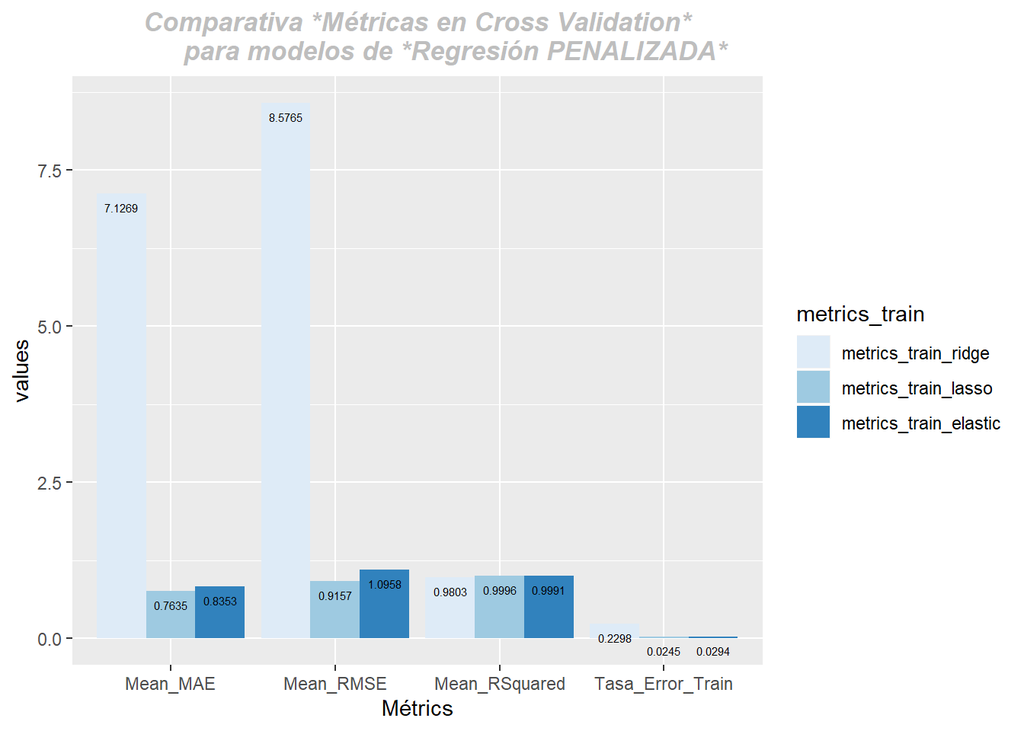

```r
metricas_train_longer <- metricas_train_wide %>%
  pivot_longer(cols="Mean_RMSE":"Tasa_Error_Train",
               names_to="names",
               values_to = "value")

ggplot(data=metricas_train_longer,aes(x=names,y=value, fill=metrics_train))+
  geom_bar(stat="identity",position=position_dodge())+
  xlab("Métrics")+
  ylab("values")+
  geom_text(aes(label=value),position=position_dodge(width=0.9), vjust=2,size=2)+
  ggtitle("Comparativa *Métricas en Cross Validation*
          para modelos de *Regresión PENALIZADA*")+
  theme(plot.title = element_text(hjust = 0.5,face="bold.italic",color="grey"))+
  scale_fill_brewer( palette="Blues")
```

#### COMPARATIVA MÉTRICAS “MODEL PREDICTION PERFORMANCE” (TEST)

```r
metricas_test_wide<-data.frame(rbind(Metricas_ridge_test,Metricas_lasso_test,Metricas_elastic_test))

metricas_test_wide[,-1]<-round(metricas_test_wide[,-1],4)

metricas_test_wide
```

```
##           metrics_test    RMSE    MAE RSquared Tasa_Error_Test
## 1   metrics_test_ridge 10.0171 8.6803   0.9701          0.2555
## 2   metrics_test_lasso  1.1290 0.9628   0.9992          0.0288
## 3 metrics_test_elastic  1.2471 1.0606   0.9988          0.0318
```

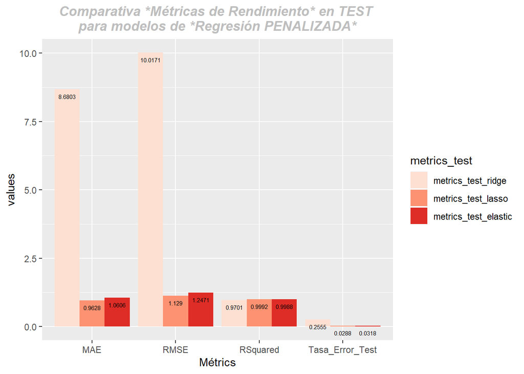

```r
metricas_test_longer <- metricas_test_wide %>%
  pivot_longer(cols="RMSE":"Tasa_Error_Test",
               names_to="names",
               values_to = "value")

ggplot(data=metricas_test_longer,aes(x=names,y=value, fill=metrics_test))+
  geom_bar(stat="identity",position=position_dodge())+
  xlab("Métrics")+
  ylab("values")+
  geom_text(aes(label=value),position=position_dodge(width=0.9), vjust=2,size=2)+
  ggtitle("Comparativa *Métricas de Rendimiento* en TEST
para modelos de *Regresión PENALIZADA*")+
  theme(plot.title = element_text(hjust = 0.5,face="bold.italic",color="grey"))+
 scale_fill_brewer( palette="Reds")
```

#### Análisis de los supuestos de Regresión lineal con **“lm”** para las variables identificadas por Lasso.

Comentar que el modelo lineal tiene un R2=0.9998 muy bueno, y que tanto el intercept cómo los coeficientes de las variables predictoras varían respecto al “CV k-fold”, cómo es lógico.

1. **Linealidad de los datos**-> Gráfica Residual vs Fitted-> Se utiliza para verificar los supuestos de relación lineal.Una línea horizontal sin patrones distintos, es una indicación de una relación lineal. En nuestro caso, prácticamente se mueve entorno a 0, es decir, asumimos linealidad entre predictores y variable resultado.
2. **Normalidad de los residuos**-> Gráfica Normal Q-Q-> Se utiliza para examinar si los residuos se distribuyen normalmente. Es bueno si los puntos residuales siguen la linea recta discontinua.En nuestro caso la mayoría siguen la línea, excepto los valores atípicos y algunos puntuales.
3. **Homogeneidad de la varianza residual(homocedasticidad)**-> Gráfica Scale-Location-> La línea horizontal con puntos igualmente extendidos es una buena indicación de homocedasticidad.En nuestros caso el comportamiento es de poca variación (entorno 0.5), por tanto, asumimos “homocedasticidad”
4. **Independencia de los términos de error de residuos**. -> Gráfica Scale-Location

```r
lm_model_lasso<-lm(Rate_Mort_Child~Mort_Congenital_rate + Mort_Diarrhoeal_rate+
     Mort_Meningitis_rate+Mort_Other_rate+
     Mort_Respiratory_rate+Life_expectancy_at_birth, data=train_data)
summary(lm_model_lasso)
```

```
##
## Call:
## lm(formula = Rate_Mort_Child ~ Mort_Congenital_rate + Mort_Diarrhoeal_rate +
##     Mort_Meningitis_rate + Mort_Other_rate + Mort_Respiratory_rate +
##     Life_expectancy_at_birth, data = train_data)
##
## Residuals:
##      Min       1Q   Median       3Q      Max
## -0.77109 -0.20362  0.00837  0.12005  1.73540
##
## Coefficients:
##                          Estimate Std. Error t value Pr(>|t|)
## (Intercept)               38.8979     9.5750   4.062 0.000282 ***
## Mort_Congenital_rate       0.9093     0.2176   4.178 0.000202 ***
## Mort_Diarrhoeal_rate       2.4637     0.6411   3.843 0.000525 ***
## Mort_Meningitis_rate       1.4186     0.7236   1.960 0.058427 .
## Mort_Other_rate            3.8499     0.1835  20.984  < 2e-16 ***
## Mort_Respiratory_rate      1.2654     0.3493   3.623 0.000968 ***
## Life_expectancy_at_birth  -0.4698     0.1224  -3.838 0.000532 ***
## ---
## Signif. codes:  0 '***' 0.001 '**' 0.01 '*' 0.05 '.' 0.1 ' ' 1
##
## Residual standard error: 0.461 on 33 degrees of freedom
## Multiple R-squared:  0.9998, Adjusted R-squared:  0.9997
## F-statistic: 2.424e+04 on 6 and 33 DF,  p-value: < 2.2e-16
```

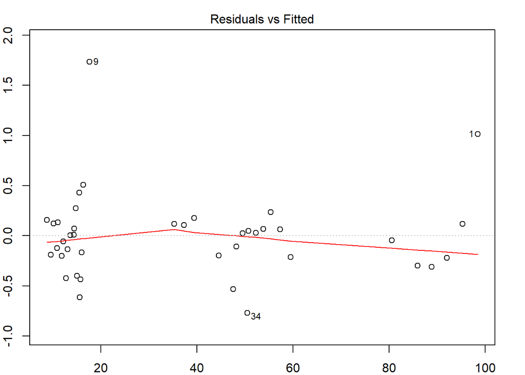

```r
par(mar=c(2,2,2,2))
plot(lm_model_lasso,1)
```

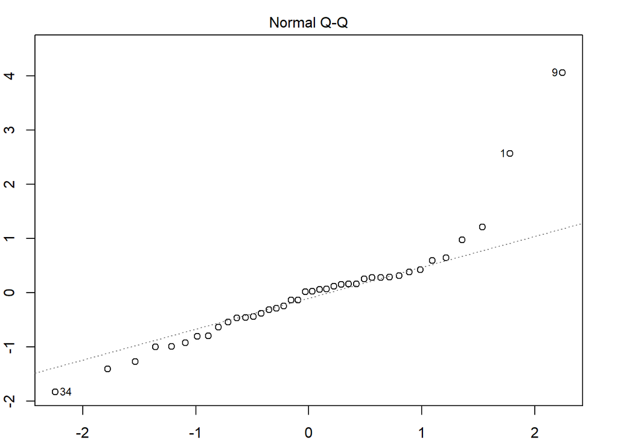

```r
plot(lm_model_lasso,2)
```

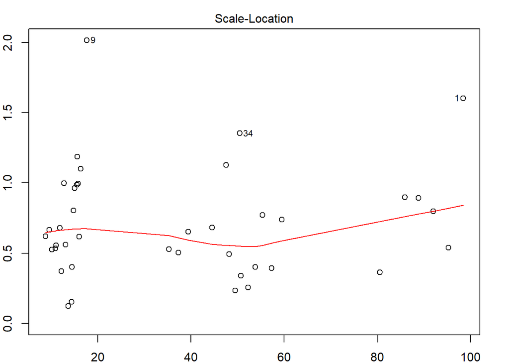

```r
plot(lm_model_lasso,3)
```

#### Análisis de **Valores Influyentes**:

**Gráfico Residuals vs Leverage**-> Se utiliza para identificar casos influyentes.

1. **Valores atípicos**-> Las observaciones cuyos residuos estandarizados son mayores que 3 en valor absoluto son posibles valores atípicos.En nuestro caso resaltan 3 puntos más extremos(#1,#9,#34),con resdiduos estandarizados por debajo de 3, excepto el#9 (4.06)
2. **Puntos de apalacamiento**-> Se puede detectar examinando la estadistica de “.hat”. Un valor superior a 2(p+1)/n indicaría una observación con alto apalancamiento. En nuestro caso 2(42+1)/40=2.15. Ninguno supera el 0.45
3. **Valores influyentes**-> Es un valor cuya inclusión o exclusión altera los resultados del análisis de regresión. No todos los valores atípicos influyen en el análisis de regresión. La “distancia de Cook” determina la influencia de un valor. Esta métrica define la influencia como una combinación de apalancamiento y tamaño residual. En nuestro caso ningun punto es influyente, porque están dentro de los límites marcados por la distancia de Cook 4/(n-p-1) = 4/(40-42-1)=-1,33

```r
#### Tabla con las métricas del diagnóstico
model_diag_metrics<-augment(lm_model_lasso)
model_diag_metrics
```

```
## # A tibble: 40 x 15
##    .rownames Rate_Mort_Child Mort_Congenital~ Mort_Diarrhoeal~ Mort_Meningitis~
##    <chr>               <dbl>            <dbl>            <dbl>            <dbl>
##  1 1                    99.4              4.3              9.8              2.9
##  2 2                    95.4              4.4              9.3              2.7
##  3 3                    91.8              4.4              8.7              2.9
##  4 4                    88.5              4.4              8.2              2.6
##  5 5                    85.6              4.5              7.8              2
##  6 7                    80.5              4.5              6.9              1.8
##  7 9                    19.4              3.5              0.8              0.3
##  8 11                   15.9              3.4              0.6              0.2
##  9 12                   15.4              3.3              0.6              0.2
## 10 13                   15                3.3              0.6              0.2
## # ... with 30 more rows, and 10 more variables: Mort_Other_rate <dbl>,
## #   Mort_Respiratory_rate <dbl>, Life_expectancy_at_birth <dbl>, .fitted <dbl>,
## #   .se.fit <dbl>, .resid <dbl>, .hat <dbl>, .sigma <dbl>, .cooksd <dbl>,
## #   .std.resid <dbl>
```

```r
#### Identificando los tres valores extremos
top_3_cook<-model_diag_metrics %>%
  top_n(3,wt=.cooksd)
top_3_cook
```

```
## # A tibble: 3 x 15
##   .rownames Rate_Mort_Child Mort_Congenital~ Mort_Diarrhoeal~ Mort_Meningitis~
##   <chr>               <dbl>            <dbl>            <dbl>            <dbl>
## 1 1                    99.4              4.3              9.8              2.9
## 2 9                    19.4              3.5              0.8              0.3
## 3 34                   49.7              3.8              4.9              1.5
## # ... with 10 more variables: Mort_Other_rate <dbl>,
## #   Mort_Respiratory_rate <dbl>, Life_expectancy_at_birth <dbl>, .fitted <dbl>,
## #   .se.fit <dbl>, .resid <dbl>, .hat <dbl>, .sigma <dbl>, .cooksd <dbl>,
## #   .std.resid <dbl>
```

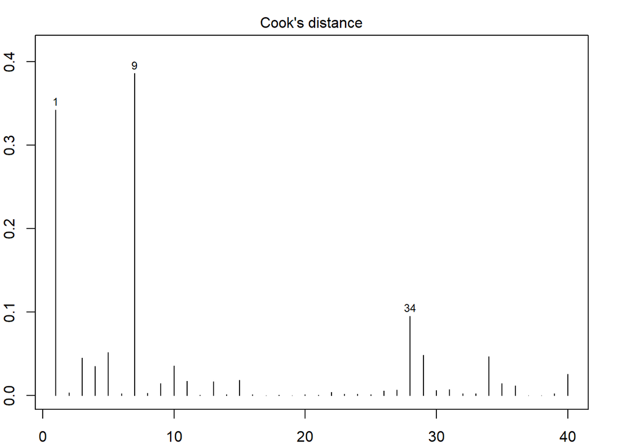

```r
par(mar=c(2,2,2,2))
plot(lm_model_lasso,4)
```

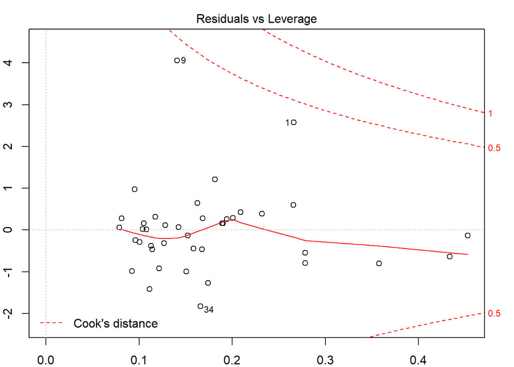

```r
plot(lm_model_lasso,5)
```

#### Se decide excluir el registro #9 (valor atípico) para ver el comportamiento del “lineal model”:

1. Mejora el R2, sin mucha variación en los coeficientes,los residuos se ajustan bien en la gráfico Normal Q-Q, y el resto de gráficas son similares.

```r
#train_data[which(rownames(train_data)==1),]
#Excluyendo los valores extremos del dataset train_data
train_data_exc<-train_data %>% filter(Rate_Mort_Child!=19.4)
glimpse(train_data_exc)
```

```
## Observations: 39
## Variables: 43
## $ Who_Region               <chr> "Africa", "Africa", "Africa", "Africa", "A...
## $ year                     <int> 2010, 2011, 2012, 2013, 2014, 2016, 2012, ...
## $ Rate_Mort_Child          <dbl> 99.4, 95.4, 91.8, 88.5, 85.6, 80.5, 15.9, ...
## $ Legislation              <int> 29, 32, 32, 41, 60, 67, 64, 77, 74, 82, 80...
## $ Coordination             <int> 56, 49, 52, 57, 67, 71, 70, 79, 81, 87, 87...
## $ Surveillance             <int> 61, 65, 71, 69, 77, 83, 82, 87, 89, 92, 90...
## $ Response                 <int> 47, 56, 62, 66, 72, 73, 78, 84, 85, 85, 88...
## $ Preparedness             <int> 25, 36, 45, 40, 53, 55, 55, 67, 71, 74, 76...
## $ Risk_communication       <int> 48, 44, 51, 51, 61, 68, 65, 77, 81, 87, 84...
## $ Human_resources          <int> 25, 33, 45, 45, 56, 51, 57, 68, 68, 68, 69...
## $ Laboratory               <int> 51, 65, 68, 69, 73, 75, 79, 79, 83, 82, 81...
## $ Points_entry             <int> 47, 38, 29, 23, 35, 39, 63, 64, 67, 69, 77...
## $ Zoonosis                 <int> 63, 59, 70, 67, 68, 79, 83, 91, 87, 91, 94...
```

[output cut: 30 more lines]

```r
#### Aplicando "lm"
lm_model_lasso_exc<-lm(Rate_Mort_Child~Mort_Congenital_rate + Mort_Diarrhoeal_rate+
     Mort_Meningitis_rate+Mort_Other_rate+
     Mort_Respiratory_rate+Life_expectancy_at_birth, data=train_data_exc)
summary(lm_model_lasso_exc)
```

```
##
## Call:
## lm(formula = Rate_Mort_Child ~ Mort_Congenital_rate + Mort_Diarrhoeal_rate +
##     Mort_Meningitis_rate + Mort_Other_rate + Mort_Respiratory_rate +
##     Life_expectancy_at_birth, data = train_data_exc)
##
## Residuals:
##      Min       1Q   Median       3Q      Max
## -0.78198 -0.19699  0.02878  0.20121  0.81479
##
## Coefficients:
##                          Estimate Std. Error t value Pr(>|t|)
## (Intercept)              36.54636    6.88924   5.305 8.18e-06 ***
## Mort_Congenital_rate      0.67286    0.16181   4.158 0.000224 ***
## Mort_Diarrhoeal_rate      2.46657    0.46046   5.357 7.04e-06 ***
## Mort_Meningitis_rate      1.07099    0.52332   2.047 0.048992 *
## Mort_Other_rate           3.81983    0.13187  28.966  < 2e-16 ***
## Mort_Respiratory_rate     1.43392    0.25262   5.676 2.78e-06 ***
## Life_expectancy_at_birth -0.43362    0.08815  -4.919 2.51e-05 ***
## ---
## Signif. codes:  0 '***' 0.001 '**' 0.01 '*' 0.05 '.' 0.1 ' ' 1
##
## Residual standard error: 0.3311 on 32 degrees of freedom
## Multiple R-squared:  0.9999, Adjusted R-squared:  0.9999
## F-statistic: 4.651e+04 on 6 and 32 DF,  p-value: < 2.2e-16
```

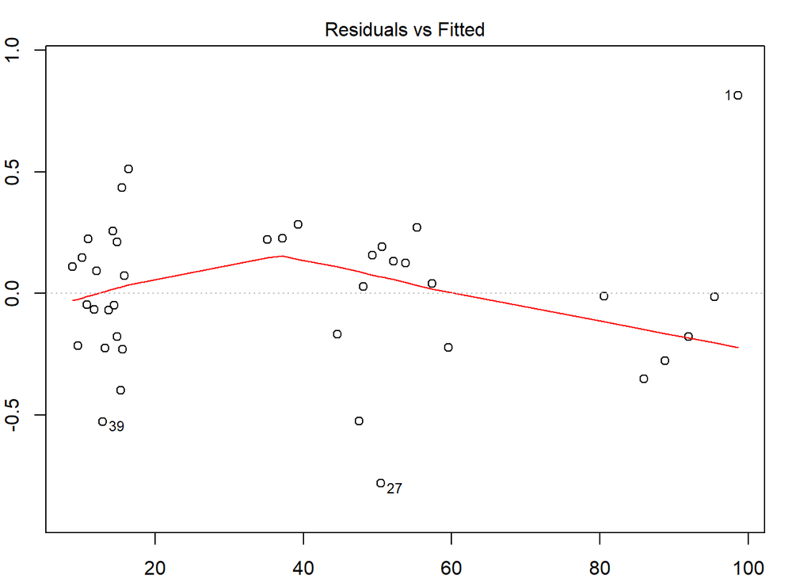

```r
par(mar=c(2,2,2,2))
plot(lm_model_lasso_exc,1)
```

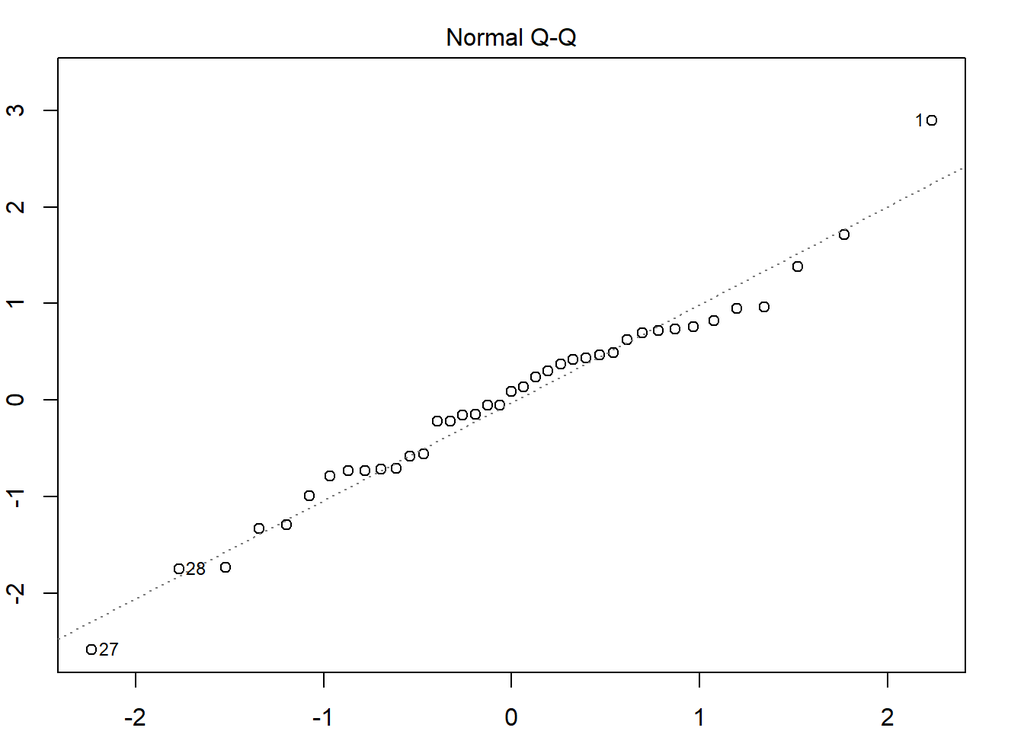

```r
plot(lm_model_lasso_exc,2)
```

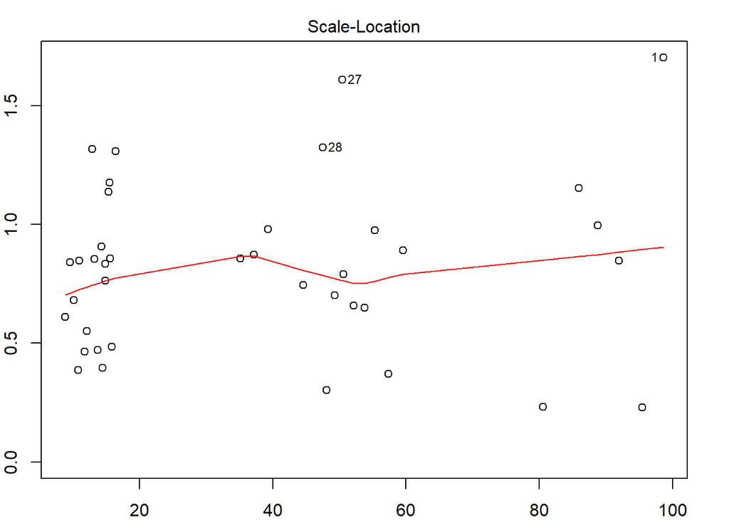

```r
plot(lm_model_lasso_exc,3)
```

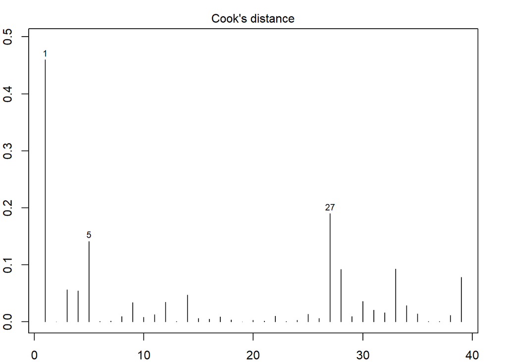

```r
plot(lm_model_lasso_exc,4)
```

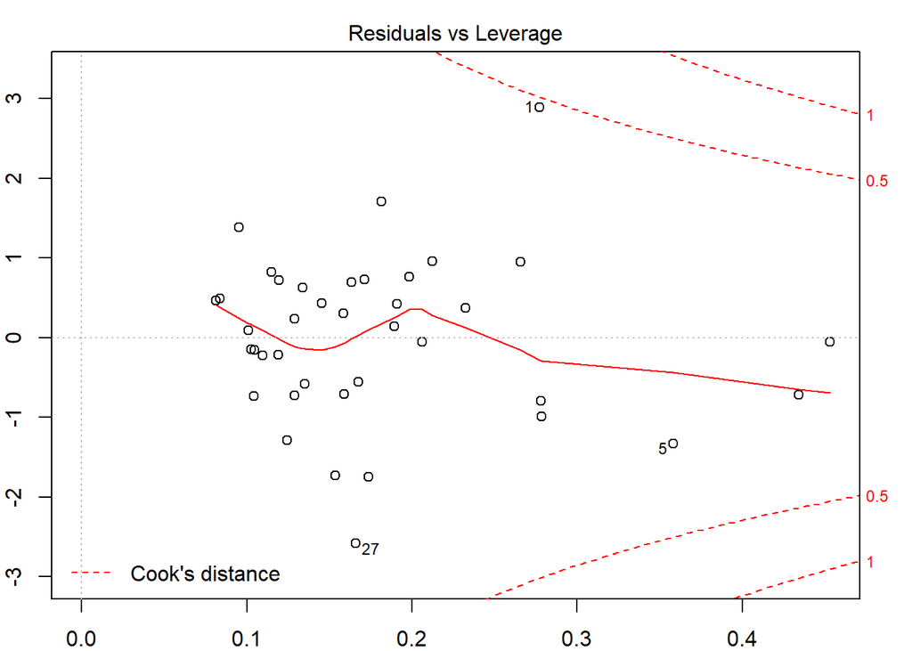

```r
plot(lm_model_lasso_exc,5)
```

#### SELECCIÓN DE MODELOS: **STEPWISE “leapBackward”**

1. Comienza con todos los predictores en el modelo, y elimina de forma iterativa los predictores menos contributivos, se detiene cuando tiene un modelo dónde todos los predictores son estadísticamente significativos.
2. Se debe especificar el número máximo de predictores que se incorporaran al modelo (nvmax=10).
3. Se utilizará la validación cruzada 5 veces para estimar el error de predicción promedio (RMSE)
4. Se estandariza las variables con *scale=TRUE*

```r
set.seed(234)
train_control<-trainControl(method = "cv",number=5)
step_model_Back<-train(Rate_Mort_Child~.,data=train_data,
                       method="leapBackward",
                       tuneGrid=data.frame(nvmax=1:10),
                       trControl=train_control,
                       scale=TRUE)
step_model_Back
```

```
## Linear Regression with Backwards Selection
##
## 40 samples
## 42 predictors
##
## No pre-processing
## Resampling: Cross-Validated (5 fold)
## Summary of sample sizes: 32, 32, 32, 32, 32
## Resampling results across tuning parameters:
##
##   nvmax  RMSE       Rsquared   MAE
##    1     4.0246477  0.9815850  3.4408857
##    2     1.9110160  0.9941568  1.5037270
##    3     1.4990697  0.9967943  1.1841176
##    4     1.0843683  0.9988220  0.9151821
##    5     0.8127310  0.9991817  0.6492647
##    6     0.7650880  0.9992763  0.5915073
##    7     0.8151811  0.9990806  0.5910875
##    8     0.6787077  0.9993425  0.5243969
##    9     0.6569478  0.9994412  0.5205172
##   10     0.6851971  0.9993983  0.5442249
##
## RMSE was used to select the optimal model using the smallest value.
## The final value used for the model was nvmax = 9.
```

```r
step_model_Back$bestTune
```

```
##   nvmax
## 9     9
```

```r
coef_step_Back<-coef(step_model_Back$finalModel,9)
data.frame(round(coef_step_Back,3))
```

```
##                           round.coef_step_Back..3.
## (Intercept)                                  3.281
## Who_RegionEurope                            -3.746
## Who_RegionWestern Pacific                   -8.138
## Risk_communication                           0.033
## Points_entry                                -0.057
## Zoonosis                                    -0.055
## Mort_Asphyxia_rate                           6.503
## Mort_Malaria_rate                            1.851
## Inm_DTP3_coverage                            0.144
## Inm_Hib3_coverage                           -0.040
```

```r
metrics_train<-step_model_Back$results[9,2:4]
Metricas_train_leapBackward<-data.frame("metrics_train"="metrics_train_leapBackward",
           Mean_RMSE=metrics_train$RMSE,
           Mean_MAE=metrics_train$MAE,
           Mean_RSquared=metrics_train$Rsquared,
           Tasa_Error_Train=metrics_train$RMSE/mean(train_data$Rate_Mort_Child))

Metricas_train_leapBackward
```

```
##                metrics_train Mean_RMSE  Mean_MAE Mean_RSquared Tasa_Error_Train
## 1 metrics_train_leapBackward 0.6569478 0.5205172     0.9994412       0.01760428
```

```r
predictions_leap_Back<-step_model_Back %>% predict(test_data)
Metricas_leapBack_test<-data.frame("metrics_test"="metrics_test_leapBack",
                               RMSE=RMSE(predictions_leap_Back,test_data$Rate_Mort_Child),
                               MAE=MAE(predictions_leap_Back,test_data$Rate_Mort_Child),
                               RSquared=caret::R2(predictions_leap_Back,test_data$Rate_Mort_Child),
                               Tasa_Error_Test=RMSE(predictions_leap_Back,test_data$Rate_Mort_Child)/mean(test_data$Rate_Mort_Child))

Metricas_leapBack_test
```

```
##            metrics_test     RMSE       MAE  RSquared Tasa_Error_Test
## 1 metrics_test_leapBack 0.883175 0.7153173 0.9994388      0.02252997
```

#### SELECCIÓN DE MODELOS: **STEPWISE “leapForward”**

1. Comienza sin predictores en el modelo, agregra iterativamente los predictores más contributivos y se detiene cuando la mejora ya no es estadisticamente significativa.
2. Se debe especificar el número máximo de predictores que se incorporaran al modelo (nvmax=10).
3. Se utilizará la validación cruzada 5 veces para estimar el error de predicción promedio (RMSE)
4. Se estandariza las variables con *scale=TRUE*

```r
set.seed(234)
train_control<-trainControl(method = "cv",number=5)
step_model_Forward<-train(Rate_Mort_Child~.,data=train_data,
                       method="leapForward",
                       tuneGrid=data.frame(nvmax=1:10),
                       trControl=train_control,
                       scale=TRUE)
step_model_Forward
```

```
## Linear Regression with Forward Selection
##
## 40 samples
## 42 predictors
##
## No pre-processing
## Resampling: Cross-Validated (5 fold)
## Summary of sample sizes: 32, 32, 32, 32, 32
## Resampling results across tuning parameters:
##
##   nvmax  RMSE       Rsquared   MAE
##    1     2.5189340  0.9937555  1.9944212
##    2     0.8188960  0.9985716  0.6283842
##    3     0.6556154  0.9993766  0.5093894
##    4     0.6883576  0.9994041  0.5183089
##    5     0.5916785  0.9995733  0.4565325
##    6     0.5657615  0.9996244  0.4429724
##    7     0.5573522  0.9996384  0.4310349
##    8     0.4980075  0.9997489  0.4009653
##    9     0.4995809  0.9997198  0.4070457
##   10     0.5036607  0.9997155  0.3930191
##
## RMSE was used to select the optimal model using the smallest value.
## The final value used for the model was nvmax = 8.
```

```r
step_model_Forward$bestTune
```

```
##   nvmax
## 8     8
```

```r
coef_step_Forward<-coef(step_model_Forward$finalModel,8)
data.frame(round(coef_step_Forward,3))
```

```
##                       round.coef_step_Forward..3.
## (Intercept)                                -2.463
## Response                                   -0.035
## Mort_Congenital_rate                        1.343
## Mort_Diarrhoeal_rate                        3.566
## Mort_Other_rate                             4.683
## Mort_Respiratory_rate                       0.965
## Inm_DTP3_coverage                           0.069
## Inm_Hib3_coverage                           0.016
## Inm_PCV3_coverage                          -0.023
```

```r
metrics_train<-step_model_Forward$results[9,2:4]
Metricas_train_leapForward<-data.frame("metrics_train"="metrics_train_leapForward",
                                       Mean_RMSE=metrics_train$RMSE,
                                       Mean_MAE=metrics_train$MAE,
                                       Mean_RSquared=metrics_train$Rsquared,
                                       Tasa_Error_Train=metrics_train$RMSE/mean(train_data$Rate_Mort_Child))

Metricas_train_leapForward
```

```
##               metrics_train Mean_RMSE  Mean_MAE Mean_RSquared Tasa_Error_Train
## 1 metrics_train_leapForward 0.4995809 0.4070457     0.9997198       0.01338731
```

```r
predictions_leap_Forward<-step_model_Forward %>% predict(test_data)
Metricas_leapForward_test<-data.frame("metrics_test"="metrics_test_leapForward",
                                   RMSE=RMSE(predictions_leap_Forward,test_data$Rate_Mort_Child),
                                   MAE=MAE(predictions_leap_Forward,test_data$Rate_Mort_Child),
                                   RSquared=caret::R2(predictions_leap_Forward,test_data$Rate_Mort_Child),
                                   Tasa_Error_Test=RMSE(predictions_leap_Forward,test_data$Rate_Mort_Child)/mean(test_data$Rate_Mort_Child))

Metricas_leapForward_test
```

```
##               metrics_test      RMSE       MAE  RSquared Tasa_Error_Test
## 1 metrics_test_leapForward 0.7050959 0.5960333 0.9995614      0.01798714
```

#### SELECCIÓN DE MODELOS: __ STEPWISE “leapSeq”"__

1. Es una combinación entre “leapBackward” y “leapForward”.Comienza sin predictores y luego agrega secuencialmente los predictores más contribuyentes. Después de agregar cada nueva variable, elimina cualquier variable que ya no proporciona una mejora en el ajuste del modelo.
2. Se debe especificar el número máximo de predictores que se incorporaran al modelo (nvmax=10).
3. Se utilizará la validación cruzada 5 veces para estimar el error de predicción promedio (RMSE)
4. Se estandariza las variables con *scale=TRUE*

```r
set.seed(345)
train_control<-trainControl(method = "cv",number=5)
step_model_leapSeq<-train(Rate_Mort_Child~.,data=train_data,
                          method="leapSeq",
                          tuneGrid=data.frame(nvmax=1:10),
                          trControl=train_control,
                          scale=TRUE)
step_model_leapSeq
```

```
## Linear Regression with Stepwise Selection
##
## 40 samples
## 42 predictors
##
## No pre-processing
## Resampling: Cross-Validated (5 fold)
## Summary of sample sizes: 32, 32, 32, 32, 32
## Resampling results across tuning parameters:
##
##   nvmax  RMSE       Rsquared   MAE
##    1     2.5350956  0.9939668  2.0452503
##    2     0.6855769  0.9994147  0.5070484
##    3     0.6638501  0.9995150  0.5288965
##    4     0.6054232  0.9995828  0.4776854
##    5     0.6758369  0.9993745  0.5216427
##    6     0.5515639  0.9995646  0.4311755
##    7     0.5384727  0.9996165  0.3894664
##    8     0.8851442  0.9980906  0.7018383
##    9     0.5784789  0.9995443  0.4106963
##   10     0.5424530  0.9996018  0.3859674
##
## RMSE was used to select the optimal model using the smallest value.
## The final value used for the model was nvmax = 7.
```

```r
step_model_leapSeq$bestTune
```

```
##   nvmax
## 7     7
```

```r
coef_step_leapSeq<-coef(step_model_leapSeq$finalModel,7)
data.frame(round(coef_step_leapSeq,3))
```

```
##                       round.coef_step_leapSeq..3.
## (Intercept)                                 5.081
## Laboratory                                 -0.041
## Mort_Congenital_rate                        1.247
## Mort_Diarrhoeal_rate                        4.000
## Mort_Other_rate                             4.931
## Mort_Respiratory_rate                       0.451
## Inm_Hib3_coverage                           0.018
## Inm_PCV3_coverage                          -0.031
```

```r
metrics_train<-step_model_leapSeq$results[9,2:4]
Metricas_train_leapSeq<-data.frame("metrics_train"="metrics_train_leapSeq",
                                       Mean_RMSE=metrics_train$RMSE,
                                       Mean_MAE=metrics_train$MAE,
                                       Mean_RSquared=metrics_train$Rsquared,                                Tasa_Error_Train=metrics_train$RMSE/mean(train_data$Rate_Mort_Child))

Metricas_train_leapSeq
```

```
##           metrics_train Mean_RMSE  Mean_MAE Mean_RSquared Tasa_Error_Train
## 1 metrics_train_leapSeq 0.5784789 0.4106963     0.9995443       0.01550155
```

```r
predictions_leap_Seq<-step_model_leapSeq %>% predict(test_data)
Metricas_leapSeq_test<-data.frame("metrics_test"="metrics_test_leapSeq",
                                      RMSE=RMSE(predictions_leap_Seq,test_data$Rate_Mort_Child),
                                      MAE=MAE(predictions_leap_Seq,test_data$Rate_Mort_Child),                                RSquared=caret::R2(predictions_leap_Seq,test_data$Rate_Mort_Child),                            Tasa_Error_Test=RMSE(predictions_leap_Seq,test_data$Rate_Mort_Child)/mean(test_data$Rate_Mort_Child))

Metricas_leapSeq_test
```

```
##           metrics_test      RMSE       MAE  RSquared Tasa_Error_Test
## 1 metrics_test_leapSeq 0.7514456 0.6028435 0.9994982      0.01916953
```

#### Comparativa **Métricas** en CROSS VALIDATION, para modelos *STEPWISE*

```r
metricas_train_wide<-data.frame(rbind(Metricas_train_leapBackward,Metricas_train_leapForward,Metricas_train_leapSeq))

metricas_train_wide[,-1]<-round(metricas_train_wide[,-1],4)

metricas_train_wide
```

```
##                metrics_train Mean_RMSE Mean_MAE Mean_RSquared Tasa_Error_Train
## 1 metrics_train_leapBackward    0.6569   0.5205        0.9994           0.0176
## 2  metrics_train_leapForward    0.4996   0.4070        0.9997           0.0134
## 3      metrics_train_leapSeq    0.5785   0.4107        0.9995           0.0155
```

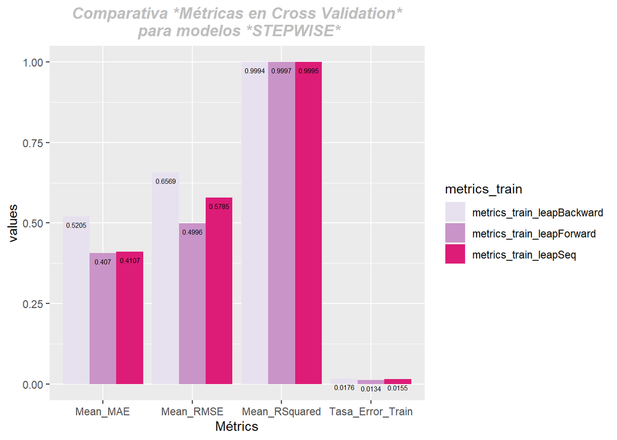

```r
metricas_train_longer <- metricas_train_wide %>%
  pivot_longer(cols="Mean_RMSE":"Tasa_Error_Train",
               names_to="names",
               values_to = "value")

ggplot(data=metricas_train_longer,aes(x=names,y=value, fill=metrics_train))+
  geom_bar(stat="identity",position=position_dodge())+
  xlab("Métrics")+
  ylab("values")+
  geom_text(aes(label=value),position=position_dodge(width=0.9), vjust=2,size=2)+
  ggtitle("Comparativa *Métricas en Cross Validation*
 para modelos *STEPWISE*")+
  theme(plot.title = element_text(hjust = 0.5,face="bold.italic",color="grey"))+
  scale_fill_brewer( palette=11)
```

#### Comparativa **Métricas de Rendimiento** en TEST, para modelos *STEPWISE*

```r
metricas_test_wide<-data.frame(rbind(Metricas_leapBack_test,Metricas_leapForward_test,Metricas_leapSeq_test))

metricas_test_wide[,-1]<-round(metricas_test_wide[,-1],4)

metricas_test_wide
```

```
##               metrics_test   RMSE    MAE RSquared Tasa_Error_Test
## 1    metrics_test_leapBack 0.8832 0.7153   0.9994          0.0225
## 2 metrics_test_leapForward 0.7051 0.5960   0.9996          0.0180
## 3     metrics_test_leapSeq 0.7514 0.6028   0.9995          0.0192
```

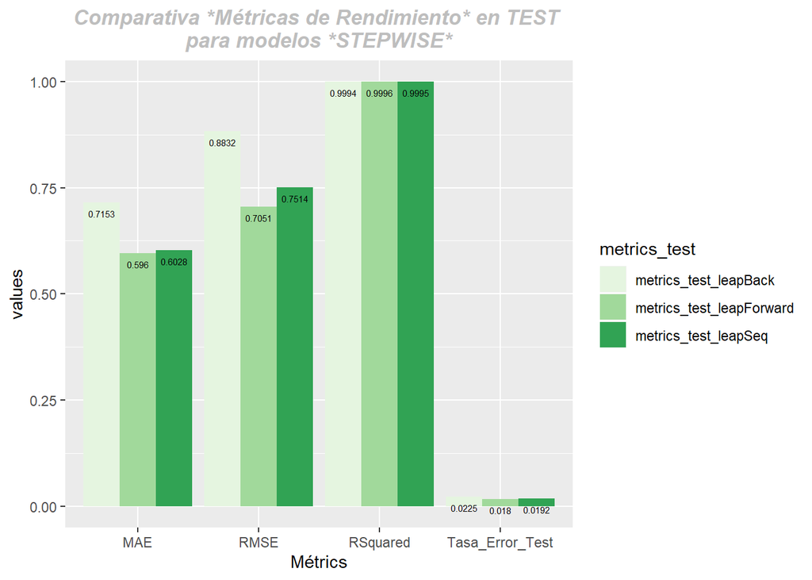

```r
metricas_test_longer <- metricas_test_wide %>%
  pivot_longer(cols="RMSE":"Tasa_Error_Test",
               names_to="names",
               values_to = "value")

ggplot(data=metricas_test_longer,aes(x=names,y=value, fill=metrics_test))+
  geom_bar(stat="identity",position=position_dodge())+
  xlab("Métrics")+
  ylab("values")+
  geom_text(aes(label=value),position=position_dodge(width=0.9), vjust=2,size=2)+
  ggtitle("Comparativa *Métricas de Rendimiento* en TEST
para modelos *STEPWISE*")+
  theme(plot.title = element_text(hjust = 0.5,face="bold.italic",color="grey"))+
  scale_fill_brewer( palette=5)
```

#### Análisis de los supuestos de Regresión lineal con **“lm”** para las variables identificadas por el modelo **Setpwise leapForward**

Comentar que el modelo lineal tiene un excelente R2=0.9999 , y que tanto el intercept cómo los coeficientes de las variables predictoras son muy similares respecto al “CV k-fold”, cómo es lógico por el propio algoritmo del modelo de ir incluyendo variables.

1. **Linealidad de los datos**-> Gráfica Residual vs Fitted-> Se utiliza para verificar los supuestos de relación lineal.Una línea horizontal sin patrones distintos, es una indicación de una relación lineal. En nuestro caso, prácticamente se mueve entorno a 0, es decir, asumimos linealidad entre predictores y variable resultado.
2. **Normalidad de los residuos**-> Gráfica Normal Q-Q-> Se utiliza para examinar si los residuos se distribuyen normalmente. Es bueno si los puntos residuales siguen la linea recta discontinua.En nuestro caso hay ciertas irregularidades en los puntos, observando escalones entonor al 0, haremos una transformación logarítmica para ver si se corrige.
3. **Homogeneidad de la varianza residual(homocedasticidad)**-> Gráfica Scale-Location-> La línea horizontal con puntos igualmente extendidos es una buena indicación de homocedasticidad. En nuestro caso el comportamiento es de poca variación pero entorno al 1, asumimos “homocedasticidad”
4. **Independencia de los términos de error de residuos**. -> Gráfica Scale-Location. Idem al anterior.

**Gráfico Residuals vs Leverage**-> Se utiliza para identificar casos influyentes.

```r
lm_model_Forward<-lm(Rate_Mort_Child~Response+Mort_Congenital_rate+
                       Mort_Diarrhoeal_rate+Mort_Other_rate+
                       Mort_Respiratory_rate+Inm_DTP3_coverage+
                       Inm_Hib3_coverage+Inm_PCV3_coverage, data=train_data)
summary(lm_model_Forward)
```

```
##
## Call:
## lm(formula = Rate_Mort_Child ~ Response + Mort_Congenital_rate +
##     Mort_Diarrhoeal_rate + Mort_Other_rate + Mort_Respiratory_rate +
##     Inm_DTP3_coverage + Inm_Hib3_coverage + Inm_PCV3_coverage,
##     data = train_data)
##
## Residuals:
##      Min       1Q   Median       3Q      Max
## -0.54631 -0.26234 -0.01411  0.20888  0.46441
##
## Coefficients:
##                        Estimate Std. Error t value Pr(>|t|)
## (Intercept)           -2.462912   4.624452  -0.533 0.598118
## Response              -0.035415   0.009328  -3.797 0.000641 ***
## Mort_Congenital_rate   1.342601   0.177487   7.565 1.58e-08 ***
## Mort_Diarrhoeal_rate   3.566419   0.372807   9.566 9.14e-11 ***
## Mort_Other_rate        4.682732   0.219507  21.333  < 2e-16 ***
## Mort_Respiratory_rate  0.965498   0.347618   2.777 0.009215 **
## Inm_DTP3_coverage      0.068893   0.040074   1.719 0.095559 .
## Inm_Hib3_coverage      0.015703   0.004254   3.692 0.000854 ***
## Inm_PCV3_coverage     -0.022892   0.005433  -4.214 0.000201 ***
## ---
## Signif. codes:  0 '***' 0.001 '**' 0.01 '*' 0.05 '.' 0.1 ' ' 1
##
## Residual standard error: 0.3067 on 31 degrees of freedom
## Multiple R-squared:  0.9999, Adjusted R-squared:  0.9999
## F-statistic: 4.109e+04 on 8 and 31 DF,  p-value: < 2.2e-16
```

```r
model_diag_Forward<-augment(lm_model_Forward)
model_diag_Forward
```

```
## # A tibble: 40 x 17
##    .rownames Rate_Mort_Child Response Mort_Congenital~ Mort_Diarrhoeal~
##    <chr>               <dbl>    <int>            <dbl>            <dbl>
##  1 1                    99.4       47              4.3              9.8
##  2 2                    95.4       56              4.4              9.3
##  3 3                    91.8       62              4.4              8.7
##  4 4                    88.5       66              4.4              8.2
##  5 5                    85.6       72              4.5              7.8
##  6 7                    80.5       73              4.5              6.9
##  7 9                    19.4       62              3.5              0.8
##  8 11                   15.9       78              3.4              0.6
##  9 12                   15.4       84              3.3              0.6
## 10 13                   15         85              3.3              0.6
## # ... with 30 more rows, and 12 more variables: Mort_Other_rate <dbl>,
## #   Mort_Respiratory_rate <dbl>, Inm_DTP3_coverage <int>,
## #   Inm_Hib3_coverage <int>, Inm_PCV3_coverage <dbl>, .fitted <dbl>,
## #   .se.fit <dbl>, .resid <dbl>, .hat <dbl>, .sigma <dbl>, .cooksd <dbl>,
## #   .std.resid <dbl>
```

```r
top_3_cook<-model_diag_Forward %>%
  top_n(3,wt=.cooksd)
top_3_cook
```

```
## # A tibble: 3 x 17
##   .rownames Rate_Mort_Child Response Mort_Congenital~ Mort_Diarrhoeal~
##   <chr>               <dbl>    <int>            <dbl>            <dbl>
## 1 9                    19.4       62              3.5              0.8
## 2 32                    9         83              2.1              0.3
## 3 48                   12.4       88              2.2              0.6
## # ... with 12 more variables: Mort_Other_rate <dbl>,
## #   Mort_Respiratory_rate <dbl>, Inm_DTP3_coverage <int>,
## #   Inm_Hib3_coverage <int>, Inm_PCV3_coverage <dbl>, .fitted <dbl>,
## #   .se.fit <dbl>, .resid <dbl>, .hat <dbl>, .sigma <dbl>, .cooksd <dbl>,
## #   .std.resid <dbl>
```

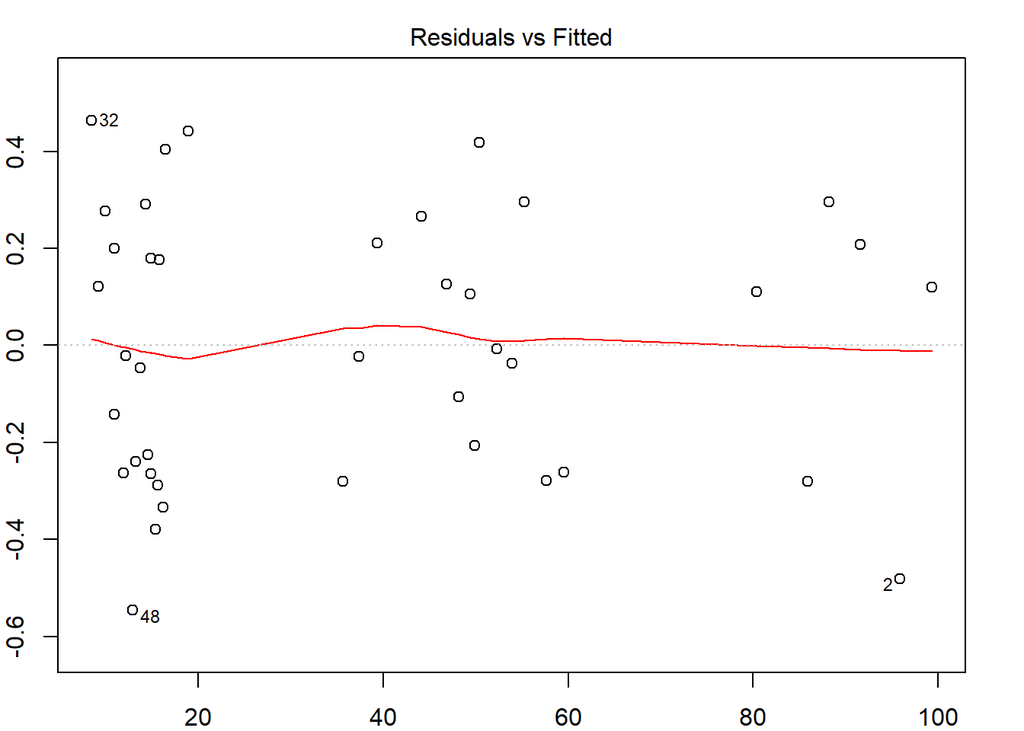

```r
par(mar=c(2,2,2,2))
plot(lm_model_Forward,1)
```

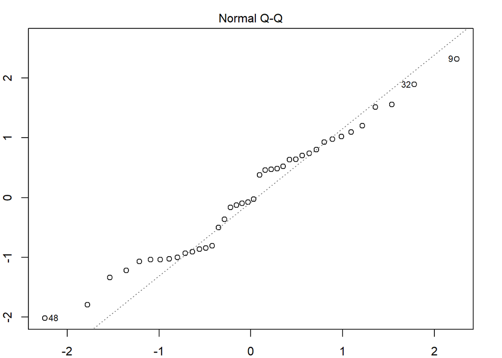

```r
plot(lm_model_Forward,2)
```

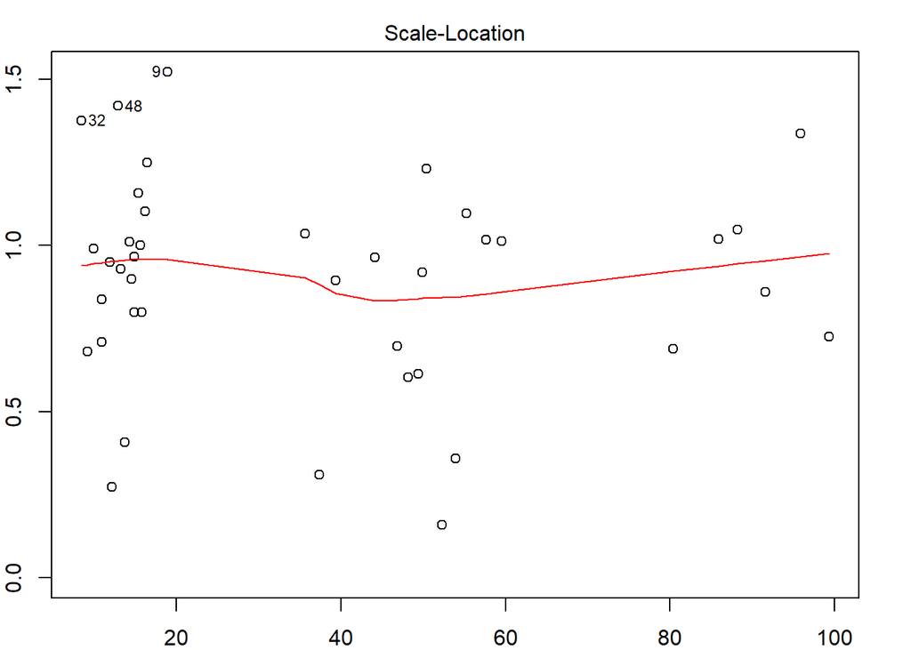

```r
plot(lm_model_Forward,3)
```

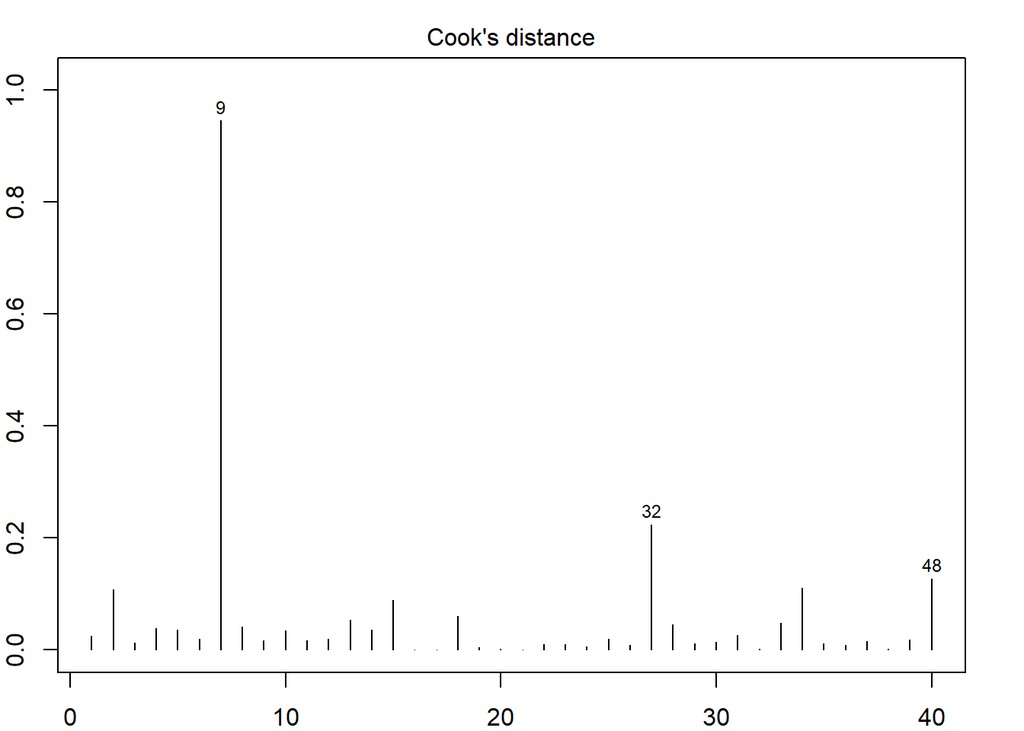

```r
plot(lm_model_Forward,4)
```

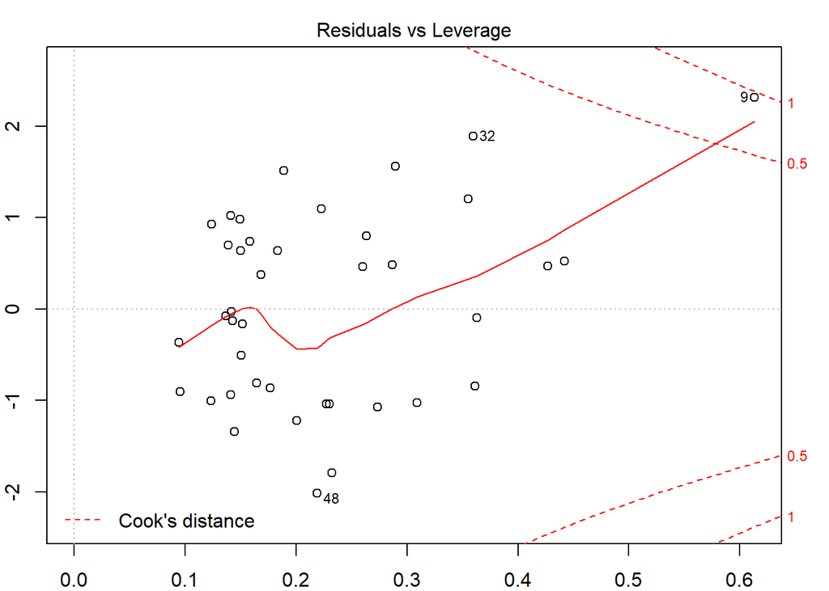

```r
plot(lm_model_Forward,5)
```

#### Transformación logarítmica de la variable objetivo para corregir la gráfica Normal Q-Q.

1. Ahora los puntos siguen más la línea recta, aunque en las colas están más dispersos.

```r
lm_model_Forward<-lm(log(Rate_Mort_Child)~Response+Mort_Congenital_rate+
                      Mort_Diarrhoeal_rate+Mort_Other_rate+
                      Mort_Respiratory_rate+Inm_DTP3_coverage+
                      Inm_Hib3_coverage+Inm_PCV3_coverage, data=train_data)
summary(lm_model_Forward)
```

```
##
## Call:
## lm(formula = log(Rate_Mort_Child) ~ Response + Mort_Congenital_rate +
##     Mort_Diarrhoeal_rate + Mort_Other_rate + Mort_Respiratory_rate +
##     Inm_DTP3_coverage + Inm_Hib3_coverage + Inm_PCV3_coverage,
##     data = train_data)
##
## Residuals:
##       Min        1Q    Median        3Q       Max
## -0.092996 -0.058018 -0.004826  0.040206  0.243416
##
## Coefficients:
##                         Estimate Std. Error t value Pr(>|t|)
## (Intercept)            1.1232745  1.2562683   0.894  0.37814
## Response               0.0076799  0.0025341   3.031  0.00489 **
## Mort_Congenital_rate   0.5784981  0.0482157  11.998 3.49e-13 ***
## Mort_Diarrhoeal_rate   0.1966822  0.1012759   1.942  0.06127 .
## Mort_Other_rate        0.0775312  0.0596309   1.300  0.20312
## Mort_Respiratory_rate -0.0935119  0.0944332  -0.990  0.32972
## Inm_DTP3_coverage     -0.0059769  0.0108864  -0.549  0.58692
## Inm_Hib3_coverage     -0.0004657  0.0011556  -0.403  0.68971
## Inm_PCV3_coverage     -0.0048178  0.0014759  -3.264  0.00268 **
## ---
## Signif. codes:  0 '***' 0.001 '**' 0.01 '*' 0.05 '.' 0.1 ' ' 1
##
## Residual standard error: 0.08331 on 31 degrees of freedom
## Multiple R-squared:  0.9912, Adjusted R-squared:  0.9889
## F-statistic: 437.2 on 8 and 31 DF,  p-value: < 2.2e-16
```

```r
model_diag_Forward<-augment(lm_model_Forward)
model_diag_Forward
```

```
## # A tibble: 40 x 17
##    .rownames log.Rate_Mort_C~ Response Mort_Congenital~ Mort_Diarrhoeal~
##    <chr>                <dbl>    <int>            <dbl>            <dbl>
##  1 1                     4.60       47              4.3              9.8
##  2 2                     4.56       56              4.4              9.3
##  3 3                     4.52       62              4.4              8.7
##  4 4                     4.48       66              4.4              8.2
##  5 5                     4.45       72              4.5              7.8
##  6 7                     4.39       73              4.5              6.9
##  7 9                     2.97       62              3.5              0.8
##  8 11                    2.77       78              3.4              0.6
##  9 12                    2.73       84              3.3              0.6
## 10 13                    2.71       85              3.3              0.6
## # ... with 30 more rows, and 12 more variables: Mort_Other_rate <dbl>,
## #   Mort_Respiratory_rate <dbl>, Inm_DTP3_coverage <int>,
## #   Inm_Hib3_coverage <int>, Inm_PCV3_coverage <dbl>, .fitted <dbl>,
## #   .se.fit <dbl>, .resid <dbl>, .hat <dbl>, .sigma <dbl>, .cooksd <dbl>,
## #   .std.resid <dbl>
```

```r
top_3_cook<-model_diag_Forward %>%
  top_n(3,wt=.cooksd)
top_3_cook
```

```
## # A tibble: 3 x 17
##   .rownames log.Rate_Mort_C~ Response Mort_Congenital~ Mort_Diarrhoeal~
##   <chr>                <dbl>    <int>            <dbl>            <dbl>
## 1 9                     2.97       62              3.5              0.8
## 2 32                    2.20       83              2.1              0.3
## 3 40                    3.57       80              3.4              3.1
## # ... with 12 more variables: Mort_Other_rate <dbl>,
## #   Mort_Respiratory_rate <dbl>, Inm_DTP3_coverage <int>,
## #   Inm_Hib3_coverage <int>, Inm_PCV3_coverage <dbl>, .fitted <dbl>,
## #   .se.fit <dbl>, .resid <dbl>, .hat <dbl>, .sigma <dbl>, .cooksd <dbl>,
## #   .std.resid <dbl>
```

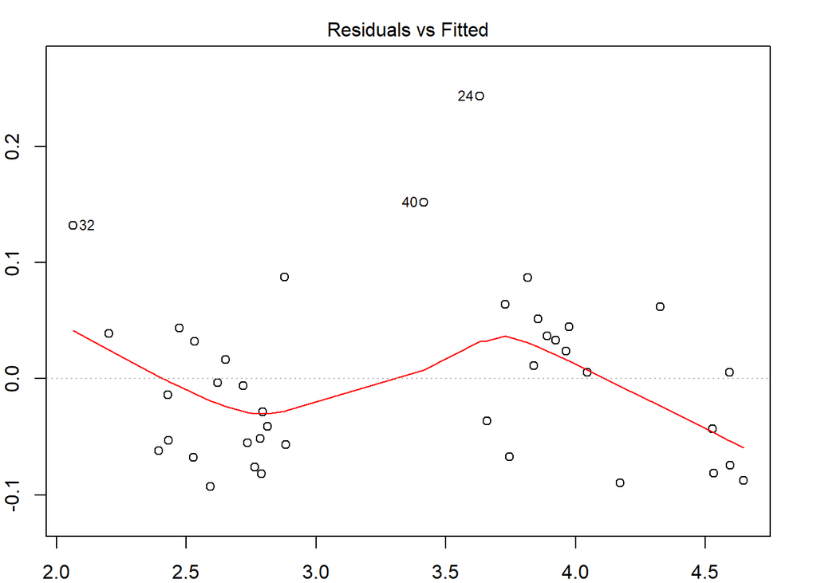

```r
par(mar=c(2,2,2,2))
plot(lm_model_Forward,1)
```

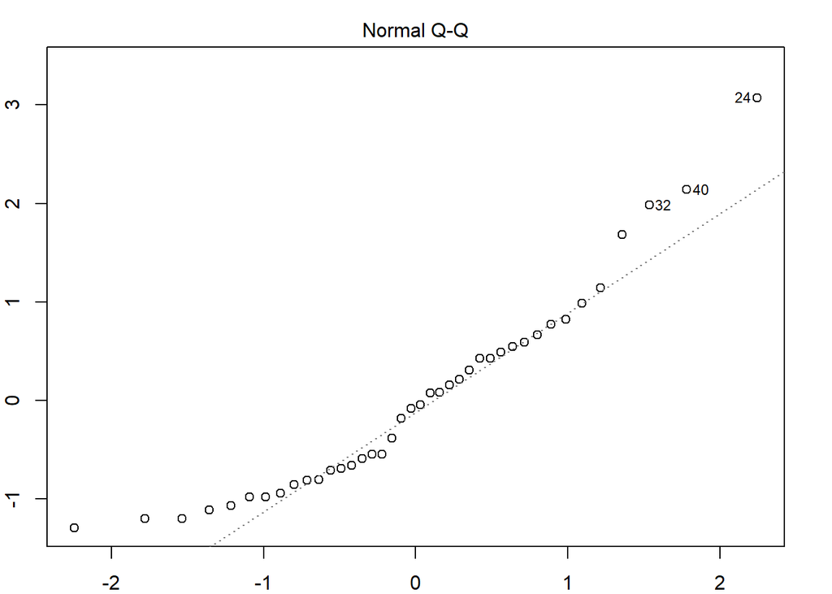

```r
plot(lm_model_Forward,2)
```

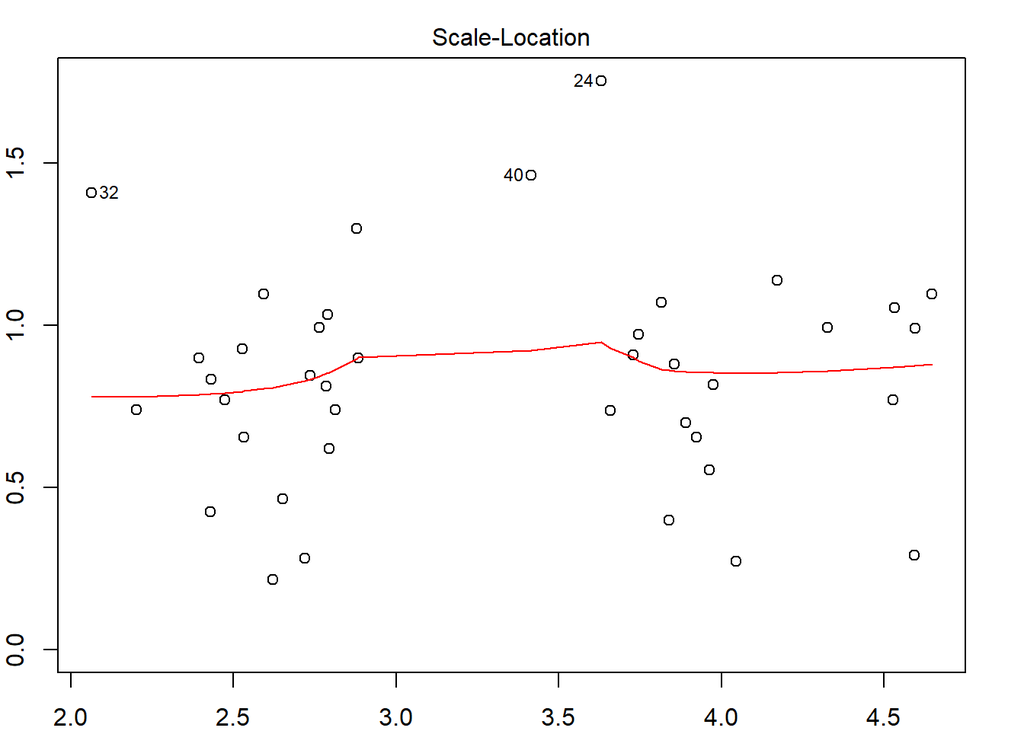

```r
plot(lm_model_Forward,3)
```

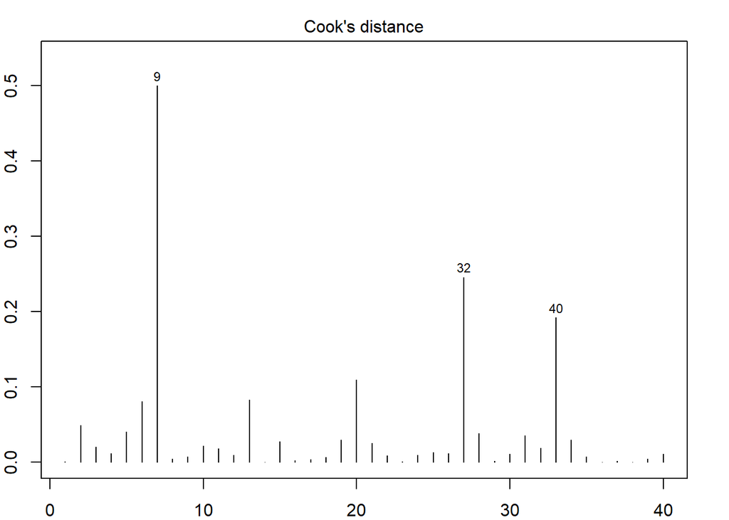

```r
plot(lm_model_Forward,4)
```

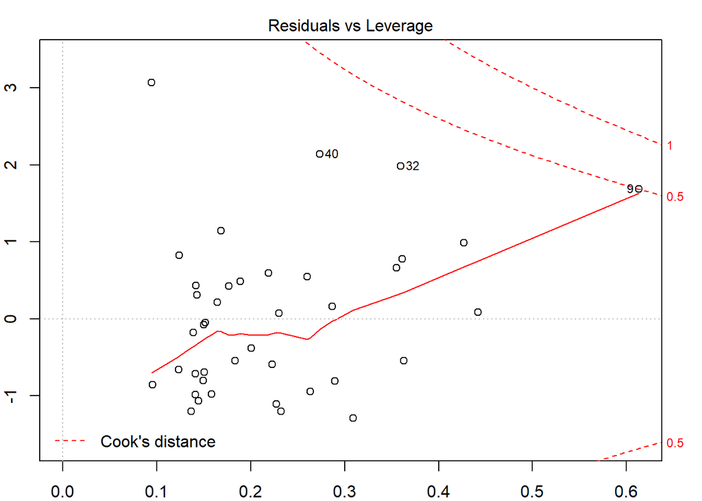

```r
plot(lm_model_Forward,5)
```

#### SELECCIÓN DE MODELOS: **REGSUBSETS**

1. Es un enfoque de selección de modelo que consiste en probar todas las combinaciones posibles de las variables predictoras, para luego seleccionar el mejor modelo de acuerdo a algunos estadísticos.
2. Se debe especificar la opción *nvmax* que representa el número máximo de predictores, en nuestro caso serán 10.
3. Y el modelo que obtiene las mejores métricas es el de 10 variables.

```r
models_reg<- regsubsets(Rate_Mort_Child~.,data=train_data,nvmax=10)
res_sum<-summary(models_reg)
data.frame(
  Adj.R2=which.max(res_sum$adjr2),
  BIC=which.min(res_sum$bic)
)
```

```
##   Adj.R2 BIC
## 1     10  10
```

```r
coef(models_reg,10)
```

```
##           (Intercept)          Surveillance  Mort_Congenital_rate
##           18.56166589           -0.03473743           -1.62942383
##  Mort_Diarrhoeal_rate Mort_HIVAIDS_dis_rate     Mort_Malaria_rate
##            1.41129605            4.45114876           -1.27974492
##       Mort_Other_rate Mort_Prematurity_rate     Inm_PCV3_coverage
##            6.08210988            1.50193098           -0.05022759
##    Maternal_Mort_Rate            ANAEMIA_PW
##            0.03346296           -0.31434765
```

```r
#### Función para acceder a la fórmula de cualquier modelo "regsubsets"
get_model_formula<-function(id,object,outcome){
  models<-summary(object)$which[id,-1]
  predictors<-names(which(models==TRUE))
  predictors<-paste(predictors,collapse="+")
  as.formula(paste0(outcome,"~",predictors))
}
model_formula=get_model_formula(10,models_reg,"Rate_Mort_Child")
model_formula
```

```
## Rate_Mort_Child ~ Surveillance + Mort_Congenital_rate + Mort_Diarrhoeal_rate +
##     Mort_HIVAIDS_dis_rate + Mort_Malaria_rate + Mort_Other_rate +
##     Mort_Prematurity_rate + Inm_PCV3_coverage + Maternal_Mort_Rate +
##     ANAEMIA_PW
## <environment: 0x00000000272c0b48>
```

#### **REGSUBSETS** aplicando **CROSS VALIDATION K-FOLD**.

```r
#### Función para obtener el error RMSE de validación cruzada (CV)
get_cv_error_RMSE<-function(model_formula,data){
  set.seed(1)
  train_control<-trainControl(method="cv",
                              number = 5)
  cv<-train(model_formula,data=train_data,method="lm",
                trControl=train_control)
  cv$results$RMSE
}
#### Compute cross-validation error RMSE
model_ids<-1:10
cv_errors_RMSE<-map(model_ids,get_model_formula,models_reg,"Rate_Mort_Child") %>%
  map(get_cv_error_RMSE,data=train_data) %>%
  unlist()

#### Función para obtener el error MAE de validación cruzada (CV)
get_cv_error_MAE<-function(model_formula,data){
  set.seed(1)
  train_control<-trainControl(method="cv",
                              number = 5)
  cv<-train(model_formula,data=train_data,method="lm",
            trControl=train_control)
  cv$results$MAE
}
#### Compute cross-validation error MAE
model_ids<-1:10
cv_errors_MAE<-map(model_ids,get_model_formula,models_reg,"Rate_Mort_Child") %>%
  map(get_cv_error_MAE,data=train_data) %>%
  unlist()
#### Función para obtener el R2 de validación cruzada (CV)
get_cv_error_R2<-function(model_formula,data){
  set.seed(1)
  train_control<-trainControl(method="cv",
                              number = 5)
  cv<-train(model_formula,data=train_data,method="lm",
            trControl=train_control)
  cv$results$Rsquared
}
#### Compute cross-validation R2
model_ids<-1:10
cv_errors_R2<-map(model_ids,get_model_formula,models_reg,"Rate_Mort_Child") %>%
  map(get_cv_error_R2,data=train_data) %>%
  unlist()

data.frame(cbind(model_id=c(1:10),cv_errors_RMSE,cv_errors_MAE,cv_errors_R2))
```

```
##    model_id cv_errors_RMSE cv_errors_MAE cv_errors_R2
## 1         1      2.2394301     1.8117440    0.9945032
## 2         2      0.6898590     0.5249135    0.9994487
## 3         3      0.5951524     0.4571321    0.9996170
## 4         4      0.4966550     0.3823934    0.9997341
## 5         5      0.3751244     0.3126268    0.9998476
## 6         6      0.3400896     0.2920202    0.9998595
## 7         7      0.3055460     0.2480012    0.9999069
## 8         8      0.3031077     0.2167638    0.9998919
## 9         9      0.3050254     0.2216495    0.9998998
## 10       10      0.2209192     0.1730723    0.9999442
```

```r
model_best_regsubsets<-lm(Rate_Mort_Child ~ Surveillance + Mort_Congenital_rate + Mort_Diarrhoeal_rate +
     Mort_HIVAIDS_dis_rate + Mort_Malaria_rate + Mort_Other_rate +
     Mort_Prematurity_rate + Inm_PCV3_coverage + Maternal_Mort_Rate +
     ANAEMIA_PW, data=train_data)


Metricas_train_best_regsubsets<-data.frame("metrics_train"="metrics_train_best_regsubsets",
                                        Mean_RMSE=cv_errors_RMSE[which.min(cv_errors_RMSE)],
                                        Mean_MAE=cv_errors_MAE[which.min(cv_errors_MAE)],
                                        Mean_RSquared=cv_errors_R2[which.max(cv_errors_R2)],
                                        Tasa_Error_Train=cv_errors_RMSE[which.min(cv_errors_RMSE)]/mean(train_data$Rate_Mort_Child))

Metricas_train_best_regsubsets
```

```
##                   metrics_train Mean_RMSE  Mean_MAE Mean_RSquared
## 1 metrics_train_best_regsubsets 0.2209192 0.1730723     0.9999442
##   Tasa_Error_Train
## 1      0.005919988
```

```r
predictions_best_regsubsets<-model_best_regsubsets %>% predict(test_data)

Metricas_best_regsubsets_test<-data.frame("metrics_test"="metrics_test_regsubsets",
                                   RMSE=RMSE(predictions_best_regsubsets,test_data$Rate_Mort_Child),
                                   MAE=MAE(predictions_best_regsubsets,test_data$Rate_Mort_Child),
                                   RSquared=caret::R2(predictions_best_regsubsets,test_data$Rate_Mort_Child),
                                   Tasa_Error_Test=RMSE(predictions_best_regsubsets,test_data$Rate_Mort_Child)/mean(test_data$Rate_Mort_Child))

Metricas_best_regsubsets_test
```

```
##              metrics_test     RMSE       MAE  RSquared Tasa_Error_Test
## 1 metrics_test_regsubsets 0.449293 0.3866751 0.9999278      0.01146156
```